# Recommendation system for restaurants

### Based on the [Yelp Dataset](https://www.kaggle.com/yelp-dataset/yelp-dataset).

## 0. Libraries

First of all, we define all the libraries we need.

```python
from matplotlib.ticker import PercentFormatter as _PercentFormatter
import matplotlib.pyplot as _plt
import numpy as _np
import pandas as _pd
import joblib as _jl
import glob as _glob
import os as _os
import re as _re
import time as _time
from multiprocessing import Pool as _Pool
from sklearn.preprocessing import OrdinalEncoder as _OrdinalEncoder, binarize as _binarize
from sklearn.metrics import confusion_matrix as _confusion_matrix, roc_curve as _roc_curve, classification_report as _classification_report, accuracy_score as _accuracy_score
from sklearn.model_selection import GridSearchCV as _GridSearchCV
from sklearn.svm import LinearSVC as _LinearSVC
from sklearn.ensemble import RandomForestClassifier as _RandomForestClassifier
from keras.models import Sequential as _Sequential, load_model as _load_model
from keras.layers import Dense as _Dense

_pd.set_option('display.max_columns', None)
```

Since we are going to use big datasets, and we'll need to load them more times, we define a commodity function that deletes all user defined variables, in order to free some memory.

```python
def _del_all():
    %reset_selective -f [^_]
```

## 1. Data cleaning

### Based on the [kernel by Hou, Saha, Tsang](https://www.kaggle.com/wenqihou828/recommendation-for-yelp-users-itself).

We execute the code in `recommendation_system_preprocessing.ipynb` in order to clean the data and to reduce the size of the dataset, using pickles instead of json and dropping unnecessary columns.

We explore the resulting datasets:

```python
dataset_list = _glob.glob("../dataset/[!checked]*.pickle")
for d in dataset_list:
    dataset = _pd.read_pickle(d)

    f = _os.path.splitext(_os.path.basename(d))[0]
    c = ", ".join(list(dataset.columns))
    s = dataset.shape

    print("Dataset '" + f + "':")
    print("\tfeatures:", c)
    print("\tshape:", s)
    print()
```

```
Dataset 'all_checkin':
	features: business_id, date
	shape: (57402, 2)

Dataset 'all_review':
	features: review_id, user_id, business_id, stars, useful, funny, cool, text, date
	shape: (4201684, 9)

Dataset 'all_tips':
	features: restaurant_name, tips_date, user_id
	shape: (770878, 3)

Dataset 'all_users':
	features: user_id, user_name, average_stars, yelping_since, review, years_of_elite, fans, useful, cool, funny, friends
	shape: (1148098, 11)

Dataset 'restaurants':
	features: name, business_id, address, cuisine, postal_code, latitude, longitude, review_count, stars, OutdoorSeating, BusinessAcceptsCreditCards, RestaurantsDelivery, RestaurantsReservations, WiFi, Alcohol, categories, city, Monday_Open, Tuesday_Open, Wednesday_Open, Thursday_Open, Friday_Open, Sat…
	shape: (59371, 31)
```

```python
_del_all()
```

## 2. Fake Review Detection

### Based on Zhiwei Zhang's [work](https://medium.com/@zhiwei_zhang/final-blog-642fb9c7e781) and [code](https://github.com/zzhang83/Yelp_Sentiment_Analysis).

Then, in order to filter out deceptive reviews, that could alter the results of our analysis, we load the model based on Support Vector Machine defined in `Yelp_sentiment_analysis/Scripts/fake_reviews.ipynb` by [Zhiwei Zhang](https://medium.com/@zhiwei_zhang/final-blog-642fb9c7e781), that has the best scores for accuracy, precision, recall and f1-score.

```python
vectorizer = _jl.load('../models/tfidf_vectorizer.joblib')
svc = _jl.load('../models/fake_review_svc_model.joblib')
```

Now, we can apply this model to our data.

```python
review = _pd.read_pickle("../dataset/all_review.pickle")

review.head()
```

|  | review_id | user_id | business_id | stars | useful | funny | cool | text | date |
| --- | --- | --- | --- | --- | --- | --- | --- | --- | --- |
| 3 | yi0R0Ugj_xUx_Nek0-_Qig | dacAIZ6fTM6mqwW5uxkskg | ikCg8xy5JIg_NGPx-MSIDA | 5 | 0 | 0 | 0 | Went in for a lunch. Steak sandwich was delici... | 2018-01-09 20:56:38 |
| 5 | fdiNeiN_hoCxCMy2wTRW9g | w31MKYsNFMrjhWxxAb5wIw | eU_713ec6fTGNO4BegRaww | 4 | 0 | 0 | 0 | I'll be the first to admit that I was not exci... | 2013-01-20 13:25:59 |
| 6 | G7XHMxG0bx9oBJNECG4IFg | jlu4CztcSxrKx56ba1a5AQ | 3fw2X5bZYeW9xCz_zGhOHg | 3 | 5 | 4 | 5 | Tracy dessert had a big name in Hong Kong and ... | 2016-05-07 01:21:02 |
| 7 | 8e9HxxLjjqc9ez5ezzN7iQ | d6xvYpyzcfbF_AZ8vMB7QA | zvO-PJCpNk4fgAVUnExYAA | 1 | 3 | 1 | 1 | This place has gone down hill. Clearly they h... | 2010-10-05 19:12:35 |
| 10 | kbtscdyz6lvrtGjD1quQTg | FIk4lQQu1eTe2EpzQ4xhBA | 8mIrX_LrOnAqWsB5JrOojQ | 4 | 0 | 0 | 0 | Like walking back in time, every Saturday morn... | 2011-11-30 02:11:15 |

```python
texts = list(review["text"])
X = vectorizer.transform(texts)
predictions = svc.predict(X)
```

```python
print(type(predictions))
print("SVC predictions:", predictions)
```

```
<class 'numpy.ndarray'>
SVC predictions: [1 1 1 ... 1 1 1]
```

Now we repeat the whole process with a different model that allows us to obtain real weights instead of a binary evaluation.

```python
cal_svc = _jl.load('../models/fake_review_cal_svc_model.joblib')
cal_predictions = cal_svc.predict_proba(X)
```

```python
print("Calibrated SVC predictions:\n", cal_predictions)
cal_predictions = _np.array([x[1] for x in cal_predictions])
print("Calibrated SVC predictions for class '1':\n", cal_predictions)
```

```
Calibrated SVC predictions:
 [[0.12112422 0.87887578]
 [0.011      0.989     ]
 [0.03538102 0.96461898]
 ...
 [0.36147536 0.63852464]
 [0.00379598 0.99620402]
 [0.00133685 0.99866315]]
Calibrated SVC predictions for class '1':
 [0.87887578 0.989      0.96461898 ... 0.63852464 0.99620402 0.99866315]
```

```python
print("columns before:\n", review.columns)
checked_review = review.assign(bin_truth_score=predictions, real_truth_score=cal_predictions)
print("columns after:\n", checked_review.columns)
```

```
columns before:
 Index(['review_id', 'user_id', 'business_id', 'stars', 'useful', 'funny',
       'cool', 'text', 'date'],
      dtype='object')
columns after:
 Index(['review_id', 'user_id', 'business_id', 'stars', 'useful', 'funny',
       'cool', 'text', 'date', 'bin_truth_score', 'real_truth_score'],
      dtype='object')
```

Let's see what we just obtained.

```python
checked_review[['review_id', 'text', 'bin_truth_score', 'real_truth_score']].head()
```

|  | review_id | text | bin_truth_score | real_truth_score |
| --- | --- | --- | --- | --- |
| 3 | yi0R0Ugj_xUx_Nek0-_Qig | Went in for a lunch. Steak sandwich was delici... | 1 | 0.878876 |
| 5 | fdiNeiN_hoCxCMy2wTRW9g | I'll be the first to admit that I was not exci... | 1 | 0.989000 |
| 6 | G7XHMxG0bx9oBJNECG4IFg | Tracy dessert had a big name in Hong Kong and ... | 1 | 0.964619 |
| 7 | 8e9HxxLjjqc9ez5ezzN7iQ | This place has gone down hill. Clearly they h... | 1 | 0.867897 |
| 10 | kbtscdyz6lvrtGjD1quQTg | Like walking back in time, every Saturday morn... | 1 | 0.975404 |

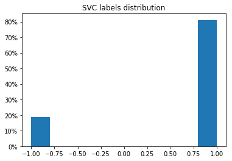

```python
data = checked_review['bin_truth_score']
_plt.hist(data, weights=_np.ones(len(data)) / len(data))
_plt.title("SVC labels distribution")
_plt.gca().yaxis.set_major_formatter(_PercentFormatter(1))
_plt.show()
```

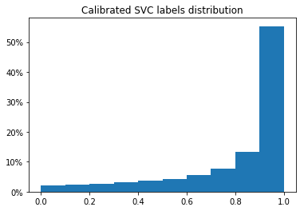

```python
data = checked_review['real_truth_score']
_plt.hist(data, weights=_np.ones(len(data)) / len(data))
_plt.title("Calibrated SVC labels distribution")
_plt.gca().yaxis.set_major_formatter(_PercentFormatter(1))
_plt.show()
```

Finally, we can save the new dataset without the `text` column, in order to save space and computation time.

```python
checked_review.drop(columns=['text'], inplace=True)
checked_review.to_pickle('../dataset/checked_review.pickle')
```

Check that everything has worked properly.

```python
final_review = _pd.read_pickle('../dataset/checked_review.pickle')
print(final_review.columns)
final_review.head()
```

```
Index(['review_id', 'user_id', 'business_id', 'stars', 'useful', 'funny',
       'cool', 'date', 'bin_truth_score', 'real_truth_score'],
      dtype='object')
```

|  | review_id | user_id | business_id | stars | useful | funny | cool | date | bin_truth_score | real_truth_score |
| --- | --- | --- | --- | --- | --- | --- | --- | --- | --- | --- |
| 3 | yi0R0Ugj_xUx_Nek0-_Qig | dacAIZ6fTM6mqwW5uxkskg | ikCg8xy5JIg_NGPx-MSIDA | 5 | 0 | 0 | 0 | 2018-01-09 20:56:38 | 1 | 0.878876 |
| 5 | fdiNeiN_hoCxCMy2wTRW9g | w31MKYsNFMrjhWxxAb5wIw | eU_713ec6fTGNO4BegRaww | 4 | 0 | 0 | 0 | 2013-01-20 13:25:59 | 1 | 0.989000 |
| 6 | G7XHMxG0bx9oBJNECG4IFg | jlu4CztcSxrKx56ba1a5AQ | 3fw2X5bZYeW9xCz_zGhOHg | 3 | 5 | 4 | 5 | 2016-05-07 01:21:02 | 1 | 0.964619 |
| 7 | 8e9HxxLjjqc9ez5ezzN7iQ | d6xvYpyzcfbF_AZ8vMB7QA | zvO-PJCpNk4fgAVUnExYAA | 1 | 3 | 1 | 1 | 2010-10-05 19:12:35 | 1 | 0.867897 |
| 10 | kbtscdyz6lvrtGjD1quQTg | FIk4lQQu1eTe2EpzQ4xhBA | 8mIrX_LrOnAqWsB5JrOojQ | 4 | 0 | 0 | 0 | 2011-11-30 02:11:15 | 1 | 0.975404 |

```python
_del_all()
```

## 3. Historical features

Following [this paper](https://www.semanticscholar.org/paper/Restaurant-Recommendation-System-Gandhe/093cecc3e53f2ba4c0c466ad3d8294ba64962050), we add some historical features to our dataset:

1. user-level features:  
   1.1. average of the ratings given by a certain user,  
   1.2. number of reviews written by a certain user,
2. business-level features:  
   2.1. average of the ratings given to a certain restaurant,  
   2.2. number of reviews written about a certain restaurant,
3. user-business features:  
   3.1. average rating given by a certain user to each category,  
   3.2. average of the ratings given by a certain user to the categories of a certain restaurant.

Before proceeding with the computation of the new features, we have to split the dataset in three parts:

1. *Test set*, from the last day considered in the dataset, to the previous `M` months;
2. *Training set*, from the day before the beginning of the test set, up to `N` months before;
3. *History*, the remaining part of the dataset, used to compute historical features.

```python
review_all = _pd.read_pickle("../dataset/checked_review.pickle")
review_test = review_all[review_all['date']>=_np.datetime64('2018-09-01')]
review_train = review_all[(review_all['date']>=_np.datetime64('2018-01-01')) & (review_all['date']<_np.datetime64('2018-09-01'))]
# review_hist = review_all[review_all['date']<_np.datetime64('2018-01-01')]

review_test.to_pickle('../dataset/m2_n9/review_test.pickle')
review_train.to_pickle('../dataset/m2_n9/review_train.pickle')
# review_hist.to_pickle('../dataset/m2_n9/review_hist.pickle')
```

```python
tips_all = _pd.read_pickle("../dataset/all_tips.pickle")
tips_test = tips_all[tips_all['tips_date']>=_np.datetime64('2018-10-01')]
tips_train = tips_all[(tips_all['tips_date']>=_np.datetime64('2018-01-01')) & (tips_all['tips_date']<_np.datetime64('2018-10-01'))]
tips_hist = tips_all[tips_all['tips_date']<_np.datetime64('2018-01-01')]

tips_test.to_pickle('../dataset/m2_n9/tips_test.pickle')
tips_train.to_pickle('../dataset/m2_n9/tips_train.pickle')
tips_hist.to_pickle('../dataset/m2_n9/tips_hist.pickle')
```

```python
_del_all()
```

### User-level features

```python
review_hist = _pd.read_pickle('../dataset/m2_n9/review_hist.pickle')
users = _pd.read_pickle("../dataset/all_users.pickle")
```

```python
avg_stars = review_hist['stars'].mean()

users = users.assign(average_stars=avg_stars)
users = users.assign(num_reviews=0)
users = users.assign(average_stars_bin=avg_stars)
users = users.assign(num_reviews_bin=0)
users = users.assign(average_stars_real=avg_stars)
users = users.assign(num_reviews_real=0)
users = users.set_index('user_id')
users.head()
```

| user_id | user_name | average_stars | yelping_since | review | years_of_elite | fans | useful | cool | funny | friends | num_reviews | average_stars_bin | num_reviews_bin | average_stars_real | num_reviews_real |
| --- | --- | --- | --- | --- | --- | --- | --- | --- | --- | --- | --- | --- | --- | --- | --- |
| l6BmjZMeQD3rDxWUbiAiow | Rashmi | 3.703313 | 2013-10-08 | 95 | 3 | 5 | 84 | 25 | 17 | 2374 | 0 | 3.703313 | 0 | 3.703313 | 0 |
| 4XChL029mKr5hydo79Ljxg | Jenna | 3.703313 | 2013-02-21 | 33 | 0 | 4 | 48 | 16 | 22 | 27646 | 0 | 3.703313 | 0 | 3.703313 | 0 |
| bc8C_eETBWL0olvFSJJd0w | David | 3.703313 | 2013-10-04 | 16 | 0 | 0 | 28 | 10 | 8 | 358 | 0 | 3.703313 | 0 | 3.703313 | 0 |
| dD0gZpBctWGdWo9WlGuhlA | Angela | 3.703313 | 2014-05-22 | 17 | 0 | 5 | 30 | 14 | 4 | 12598 | 0 | 3.703313 | 0 | 3.703313 | 0 |
| MM4RJAeH6yuaN8oZDSt0RA | Nancy | 3.703313 | 2013-10-23 | 361 | 4 | 39 | 1114 | 665 | 279 | 5542 | 0 | 3.703313 | 0 | 3.703313 | 0 |

```python
def _f(grouped):
    d = {}

    d['num'] = grouped['stars'].size
    d['stars'] = grouped['stars'].mean()

    non_fake = _np.ma.masked_where(grouped['bin_truth_score']<=0, grouped['stars']).compressed()
    d['num_bin'] = non_fake.size
    d['stars_bin'] = non_fake.mean()

    d['num_real'] = grouped['real_truth_score'].sum()
    d['stars_real'] = _np.average(grouped['stars'], weights=grouped['real_truth_score'])

    return _pd.Series(d, index=['num', 'stars', 'num_bin', 'stars_bin', 'num_real', 'stars_real'])
```

```python
grouped_reviews = review_hist.groupby('user_id').apply(_f)
grouped_reviews.head()
```

[output not shown]

```python
import random
import statistics

current_milli_time = lambda: int(round(_time.time() * 1000))

def get_time(df):
    us_id = random.choice(grouped_reviews.index)
    x = random.randrange(1000)
    t = current_milli_time()
    df.loc[us_id, ["test"]] = x
    t0 = current_milli_time()
    return t0-t

def get_time_mul(df):
    us_id = random.choice(grouped_reviews.index)
    x = random.randrange(1000)
    y = random.randrange(1000)
    z = random.randrange(1000)
    t = current_milli_time()
    df.loc[us_id, ["test", "ciao", "prova"]] = [x, y, z]
    t0 = current_milli_time()
    return t0-t

def test():
    df = users.copy()
    df['test'] = -1
    times = []
    for i in range(1000):
         times += [get_time(df)]
    avg_time = statistics.mean(times)
    del df
    return avg_time

def test_mul():
    df = users.copy()
    df['test'] = -1
    df['ciao'] = -1
    df['prova'] = -1
    times = []
    for i in range(1000):
         times += [get_time(df)]
    avg_time = statistics.mean(times)
    del df
    return avg_time

def tot_time(ops, x, k):
    time_millis = ops * k * x
    hours = time_millis/1000/60/60
    return hours

tot = len(grouped_reviews)
x = test()
print("hours:", tot_time(tot, x, 6))
x = test_mul()
print("hours mul:", tot_time(tot, x, 1))
```

```
hours: 53.065662455
hours mul: 8.774814544166667
```

```python
count = 1
tot = len(grouped_reviews)
print("tot:", tot)

for index, row in grouped_reviews.iterrows():
    uid = index
    num = row['num']
    stars = row['stars']
    num_bin = row['num_bin']
    stars_bin = row['stars_bin']
    num_real = row['num_real']
    stars_real = row['stars_real']

    cols = ["num_reviews", "average_stars", "num_reviews_bin",
            "average_stars_bin", "num_reviews_real", "average_stars_real"]
    vals = [num, stars, num_bin, stars_bin, num_real, stars_real]
    users.loc[uid, cols] = vals

    count += 1
    if count % 1000 == 0:
        percent = (count/tot)*100
        print("row {}/{} - {}%".format(count, tot, percent))
```

```
tot: 954447
row 1000/954447 - 0.10477271131870078%
row 2000/954447 - 0.20954542263740156%
row 3000/954447 - 0.31431813395610236%
row 4000/954447 - 0.4190908452748031%
row 5000/954447 - 0.5238635565935038%
row 6000/954447 - 0.6286362679122047%
row 7000/954447 - 0.7334089792309054%
row 8000/954447 - 0.8381816905496062%
row 9000/954447 - 0.942954401868307%
row 10000/954447 - 1.0477271131870076%
[...]
row 945000/954447 - 99.01021219617223%
row 946000/954447 - 99.11498490749094%
row 947000/954447 - 99.21975761880964%
row 948000/954447 - 99.32453033012834%
row 949000/954447 - 99.42930304144704%
row 950000/954447 - 99.53407575276574%
row 951000/954447 - 99.63884846408445%
row 952000/954447 - 99.74362117540313%
row 953000/954447 - 99.84839388672184%
row 954000/954447 - 99.95316659804054%
```

```python
users = users.reset_index()
users.to_pickle('../dataset/m2_n9/users.pickle')
_del_all()
```

### Business-level features

```python
restaurants = _pd.read_pickle("../dataset/restaurants.pickle")
review_hist = _pd.read_pickle('../dataset/m2_n9/review_hist.pickle')
avg_stars = review_hist['stars'].mean()
```

```python
restaurants = restaurants.assign(average_stars=avg_stars)
restaurants = restaurants.assign(num_reviews=0)
restaurants = restaurants.assign(average_stars_bin=avg_stars)
restaurants = restaurants.assign(num_reviews_bin=0)
restaurants = restaurants.assign(average_stars_real=avg_stars)
restaurants = restaurants.assign(num_reviews_real=0)
restaurants = restaurants.set_index('business_id')
restaurants.head()
```

| business_id | name | address | cuisine | postal_code | latitude | longitude | review_count | stars | OutdoorSeating | BusinessAcceptsCreditCards | ... | Thursday_Close | Friday_Close | Saturday_Close | Sunday_Close | average_stars | num_reviews | average_stars_bin | num_reviews_bin | average_stars_real | num_reviews_real |
| --- | --- | --- | --- | --- | --- | --- | --- | --- | --- | --- | --- | --- | --- | --- | --- | --- | --- | --- | --- | --- | --- |
| QXAEGFB4oINsVuTFxEYKFQ | Emerald Chinese Restaurant | 30 Eglinton Avenue W | Chinese | L5R 3E7 | 43.605499 | -79.652289 | 128 | 2.5 | False | NaN | ... | 00:00:00 | 01:00:00 | 01:00:00 | 00:00:00 | 3.703313 | 0 | 3.703313 | 0 | 3.703313 | 0 |
| gnKjwL_1w79qoiV3IC_xQQ | Musashi Japanese Restaurant | 10110 Johnston Rd, Ste 15 | Japanese | 28210 | 35.092564 | -80.859132 | 170 | 4.0 | False | True | ... | 21:30:00 | 22:00:00 | 22:00:00 | 21:00:00 | 3.703313 | 0 | 3.703313 | 0 | 3.703313 | 0 |
| 1Dfx3zM-rW4n-31KeC8sJg | Taco Bell | 2450 E Indian School Rd | Mexican | 85016 | 33.495194 | -112.028588 | 18 | 3.0 | False | True | ... | 01:00:00 | 01:00:00 | 01:00:00 | 00:00:00 | 3.703313 | 0 | 3.703313 | 0 | 3.703313 | 0 |
| fweCYi8FmbJXHCqLnwuk8w | Marco's Pizza | 5981 Andrews Rd | Italian | 44060 | 41.708520 | -81.359556 | 16 | 4.0 | False | True | ... | 00:00:00 | 01:00:00 | 01:00:00 | 00:00:00 | 3.703313 | 0 | 3.703313 | 0 | 3.703313 | 0 |
| PZ-LZzSlhSe9utkQYU8pFg | Carluccio's Tivoli Gardens | 1775 E Tropicana Ave, Ste 29 | Italian | 89119 | 36.100016 | -115.128529 | 40 | 4.0 | False | True | ... | NaT | NaT | NaT | NaT | 3.703313 | 0 | 3.703313 | 0 | 3.703313 | 0 |

5 rows × 36 columns

```python
grouped_reviews = review_hist.groupby('business_id').apply(_f)
grouped_reviews.head()
```

| business_id | num | stars | num_bin | stars_bin | num_real | stars_real |
| --- | --- | --- | --- | --- | --- | --- |
| --1UhMGODdWsrMastO9DZw | 22.0 | 4.227273 | 14.0 | 4.214286 | 16.978214 | 4.267477 |
| --6MefnULPED_I942VcFNA | 38.0 | 3.157895 | 32.0 | 3.218750 | 33.948759 | 3.218815 |
| --9e1ONYQuAa-CB_Rrw7Tw | 1504.0 | 4.107048 | 1216.0 | 4.088816 | 1205.738732 | 4.092415 |
| --DaPTJW3-tB1vP-PfdTEg | 40.0 | 3.650000 | 33.0 | 3.575758 | 34.780500 | 3.642790 |
| --FBCX-N37CMYDfs790Bnw | 122.0 | 3.737705 | 90.0 | 3.611111 | 93.369750 | 3.646290 |

```python
count = 1
tot = len(grouped_reviews)
print("tot:", tot)

for index, row in grouped_reviews.iterrows():
    uid = index
    num = row['num']
    stars = row['stars']
    num_bin = row['num_bin']
    stars_bin = row['stars_bin']
    num_real = row['num_real']
    stars_real = row['stars_real']

    cols = ["num_reviews", "average_stars", "num_reviews_bin",
            "average_stars_bin", "num_reviews_real", "average_stars_real"]
    vals = [num, stars, num_bin, stars_bin, num_real, stars_real]
    restaurants.loc[uid, cols] = vals

    count += 1
    if count % 1000 == 0:
        percent = (count/tot)*100
        print("row {}/{} - {}%".format(count, tot, percent))
```

```
tot: 56850
row 1000/56850 - 1.759014951627089%
row 2000/56850 - 3.518029903254178%
row 3000/56850 - 5.277044854881266%
row 4000/56850 - 7.036059806508356%
row 5000/56850 - 8.795074758135444%
row 6000/56850 - 10.554089709762533%
row 7000/56850 - 12.313104661389621%
row 8000/56850 - 14.072119613016712%
row 9000/56850 - 15.8311345646438%
row 10000/56850 - 17.590149516270888%
[...]
row 47000/56850 - 82.67370272647318%
row 48000/56850 - 84.43271767810026%
row 49000/56850 - 86.19173262972735%
row 50000/56850 - 87.95074758135443%
row 51000/56850 - 89.70976253298153%
row 52000/56850 - 91.46877748460862%
row 53000/56850 - 93.22779243623572%
row 54000/56850 - 94.9868073878628%
row 55000/56850 - 96.74582233948989%
row 56000/56850 - 98.50483729111697%
```

```python
restaurants = restaurants.reset_index()
restaurants.to_pickle('../dataset/m2_n9/restaurants.pickle')
_del_all()
```

### User - Business level features

#### 3.1. average rating given by a certain user to each category

```python
restaurants = _pd.read_pickle('../dataset/m2_n9/restaurants.pickle')
restaurants.head()
```

|  | business_id | name | address | cuisine | postal_code | latitude | longitude | review_count | stars | OutdoorSeating | ... | Thursday_Close | Friday_Close | Saturday_Close | Sunday_Close | average_stars | num_reviews | average_stars_bin | num_reviews_bin | average_stars_real | num_reviews_real |
| --- | --- | --- | --- | --- | --- | --- | --- | --- | --- | --- | --- | --- | --- | --- | --- | --- | --- | --- | --- | --- | --- |
| 0 | QXAEGFB4oINsVuTFxEYKFQ | Emerald Chinese Restaurant | 30 Eglinton Avenue W | Chinese | L5R 3E7 | 43.605499 | -79.652289 | 128 | 2.5 | False | ... | 00:00:00 | 01:00:00 | 01:00:00 | 00:00:00 | 2.726496 | 117.0 | 2.718750 | 96.0 | 2.730197 | 95.873087 |
| 1 | gnKjwL_1w79qoiV3IC_xQQ | Musashi Japanese Restaurant | 10110 Johnston Rd, Ste 15 | Japanese | 28210 | 35.092564 | -80.859132 | 170 | 4.0 | False | ... | 21:30:00 | 22:00:00 | 22:00:00 | 21:00:00 | 4.063291 | 158.0 | 4.094203 | 138.0 | 4.067541 | 139.112078 |
| 2 | 1Dfx3zM-rW4n-31KeC8sJg | Taco Bell | 2450 E Indian School Rd | Mexican | 85016 | 33.495194 | -112.028588 | 18 | 3.0 | False | ... | 01:00:00 | 01:00:00 | 01:00:00 | 00:00:00 | 3.125000 | 16.0 | 2.769231 | 13.0 | 2.847327 | 12.604125 |
| 3 | fweCYi8FmbJXHCqLnwuk8w | Marco's Pizza | 5981 Andrews Rd | Italian | 44060 | 41.708520 | -81.359556 | 16 | 4.0 | False | ... | 00:00:00 | 01:00:00 | 01:00:00 | 00:00:00 | 4.230769 | 13.0 | 4.166667 | 12.0 | 4.142021 | 10.965903 |
| 4 | PZ-LZzSlhSe9utkQYU8pFg | Carluccio's Tivoli Gardens | 1775 E Tropicana Ave, Ste 29 | Italian | 89119 | 36.100016 | -115.128529 | 40 | 4.0 | False | ... | NaT | NaT | NaT | NaT | 4.097561 | 41.0 | 4.212121 | 33.0 | 4.167159 | 33.655622 |

5 rows × 37 columns

```python
restaurants.columns
```

```
Index(['business_id', 'name', 'address', 'cuisine', 'postal_code', 'latitude',
       'longitude', 'review_count', 'stars', 'OutdoorSeating',
       'BusinessAcceptsCreditCards', 'RestaurantsDelivery',
       'RestaurantsReservations', 'WiFi', 'Alcohol', 'categories', 'city',
       'Monday_Open', 'Tuesday_Open', 'Wednesday_Open', 'Thursday_Open',
       'Friday_Open', 'Saturday_Open', 'Sunday_Open', 'Monday_Close',
       'Tuesday_Close', 'Wednesday_Close', 'Thursday_Close', 'Friday_Close',
       'Saturday_Close', 'Sunday_Close', 'average_stars', 'num_reviews',
       'average_stars_bin', 'num_reviews_bin', 'average_stars_real',
       'num_reviews_real'],
      dtype='object')
```

```python
review_hist = _pd.read_pickle('../dataset/m2_n9/review_hist.pickle')
review_hist.head()
```

|  | review_id | user_id | business_id | stars | useful | funny | cool | date | bin_truth_score | real_truth_score |
| --- | --- | --- | --- | --- | --- | --- | --- | --- | --- | --- |
| 5 | fdiNeiN_hoCxCMy2wTRW9g | w31MKYsNFMrjhWxxAb5wIw | eU_713ec6fTGNO4BegRaww | 4 | 0 | 0 | 0 | 2013-01-20 13:25:59 | 1 | 0.989000 |
| 6 | G7XHMxG0bx9oBJNECG4IFg | jlu4CztcSxrKx56ba1a5AQ | 3fw2X5bZYeW9xCz_zGhOHg | 3 | 5 | 4 | 5 | 2016-05-07 01:21:02 | 1 | 0.964619 |
| 7 | 8e9HxxLjjqc9ez5ezzN7iQ | d6xvYpyzcfbF_AZ8vMB7QA | zvO-PJCpNk4fgAVUnExYAA | 1 | 3 | 1 | 1 | 2010-10-05 19:12:35 | 1 | 0.867897 |
| 10 | kbtscdyz6lvrtGjD1quQTg | FIk4lQQu1eTe2EpzQ4xhBA | 8mIrX_LrOnAqWsB5JrOojQ | 4 | 0 | 0 | 0 | 2011-11-30 02:11:15 | 1 | 0.975404 |
| 11 | -I5umRTkhw15RqpKMl_o1Q | -mA3-1mN4JIEkqOtdbNXCQ | mRUVMJkUGxrByzMQ2MuOpA | 1 | 0 | 1 | 0 | 2017-12-15 23:27:08 | 1 | 0.972826 |

```python
joined_reviews = review_hist.join(restaurants.set_index('business_id'), on = 'business_id', lsuffix='_review', rsuffix='_rest')
joined_reviews.head()
```

|  | review_id | user_id | business_id | stars_review | useful | funny | cool | date | bin_truth_score | real_truth_score | ... | Thursday_Close | Friday_Close | Saturday_Close | Sunday_Close | average_stars | num_reviews | average_stars_bin | num_reviews_bin | average_stars_real | num_reviews_real |
| --- | --- | --- | --- | --- | --- | --- | --- | --- | --- | --- | --- | --- | --- | --- | --- | --- | --- | --- | --- | --- | --- |
| 5 | fdiNeiN_hoCxCMy2wTRW9g | w31MKYsNFMrjhWxxAb5wIw | eU_713ec6fTGNO4BegRaww | 4 | 0 | 0 | 0 | 2013-01-20 13:25:59 | 1 | 0.989000 | ... | 22:00:00 | 23:00:00 | 23:00:00 | NaT | 3.642276 | 123.0 | 3.594059 | 101.0 | 3.596369 | 99.505441 |
| 6 | G7XHMxG0bx9oBJNECG4IFg | jlu4CztcSxrKx56ba1a5AQ | 3fw2X5bZYeW9xCz_zGhOHg | 3 | 5 | 4 | 5 | 2016-05-07 01:21:02 | 1 | 0.964619 | ... | 00:00:00 | 02:00:00 | 02:00:00 | 00:00:00 | 3.292453 | 106.0 | 3.320000 | 100.0 | 3.289493 | 94.480786 |
| 7 | 8e9HxxLjjqc9ez5ezzN7iQ | d6xvYpyzcfbF_AZ8vMB7QA | zvO-PJCpNk4fgAVUnExYAA | 1 | 3 | 1 | 1 | 2010-10-05 19:12:35 | 1 | 0.867897 | ... | 22:00:00 | 23:00:00 | 23:00:00 | 23:00:00 | 2.655172 | 29.0 | 2.875000 | 24.0 | 2.727490 | 23.413530 |
| 10 | kbtscdyz6lvrtGjD1quQTg | FIk4lQQu1eTe2EpzQ4xhBA | 8mIrX_LrOnAqWsB5JrOojQ | 4 | 0 | 0 | 0 | 2011-11-30 02:11:15 | 1 | 0.975404 | ... | 23:00:00 | 00:00:00 | 00:00:00 | 23:00:00 | 4.491259 | 1144.0 | 4.499535 | 1075.0 | 4.502904 | 1031.313358 |
| 11 | -I5umRTkhw15RqpKMl_o1Q | -mA3-1mN4JIEkqOtdbNXCQ | mRUVMJkUGxrByzMQ2MuOpA | 1 | 0 | 1 | 0 | 2017-12-15 23:27:08 | 1 | 0.972826 | ... | 00:00:00 | 02:00:00 | 02:00:00 | 00:00:00 | 3.666667 | 12.0 | 3.833333 | 6.0 | 3.650460 | 7.482296 |

5 rows × 46 columns

```python
categories = ', '.join(list(restaurants['categories'].unique()))
categories = categories.split(', ')
print(len(categories))

cat = []
for h in categories:
    if h not in cat:
        cat.append(h)

print(len(cat))

cuisines = ', '.join(list(restaurants['cuisine'].unique()))
cuisines = cuisines.split(', ')
print(len(cuisines))

_cuisines_unique = []
for cuisine in cuisines:
    if not cuisine in _cuisines_unique:
        _cuisines_unique.append(cuisine)

print("Number of cuisines: {0}".format(len(_cuisines_unique)))
print(_cuisines_unique)
```

```
173884
761
249
Number of cuisines: 10
['Chinese', 'Japanese', 'Mexican', 'Italian', 'Others', 'American', 'Korean', 'Mediterranean', 'Thai', 'Asian Fusion']
```

```python
joined_reviews.to_pickle('../dataset/m2_n9/join_restaurants_reviewhist.pickle')
```

```python
_del_all()
```

Checkpoint

```python
joined_reviews =  _pd.read_pickle('../dataset/m2_n9/join_restaurants_reviewhist.pickle')
joined_reviews.head()
```

|  | index | review_id | user_id | business_id | stars_review | useful | funny | cool | date | bin_truth_score | ... | Thursday_Close | Friday_Close | Saturday_Close | Sunday_Close | average_stars | num_reviews | average_stars_bin | num_reviews_bin | average_stars_real | num_reviews_real |
| --- | --- | --- | --- | --- | --- | --- | --- | --- | --- | --- | --- | --- | --- | --- | --- | --- | --- | --- | --- | --- | --- |
| 0 | 5 | fdiNeiN_hoCxCMy2wTRW9g | w31MKYsNFMrjhWxxAb5wIw | eU_713ec6fTGNO4BegRaww | 4 | 0 | 0 | 0 | 2013-01-20 13:25:59 | 1 | ... | 22:00:00 | 23:00:00 | 23:00:00 | NaT | 3.642276 | 123.0 | 3.594059 | 101.0 | 3.596369 | 99.505441 |
| 1 | 6 | G7XHMxG0bx9oBJNECG4IFg | jlu4CztcSxrKx56ba1a5AQ | 3fw2X5bZYeW9xCz_zGhOHg | 3 | 5 | 4 | 5 | 2016-05-07 01:21:02 | 1 | ... | 00:00:00 | 02:00:00 | 02:00:00 | 00:00:00 | 3.292453 | 106.0 | 3.320000 | 100.0 | 3.289493 | 94.480786 |
| 2 | 7 | 8e9HxxLjjqc9ez5ezzN7iQ | d6xvYpyzcfbF_AZ8vMB7QA | zvO-PJCpNk4fgAVUnExYAA | 1 | 3 | 1 | 1 | 2010-10-05 19:12:35 | 1 | ... | 22:00:00 | 23:00:00 | 23:00:00 | 23:00:00 | 2.655172 | 29.0 | 2.875000 | 24.0 | 2.727490 | 23.413530 |
| 3 | 10 | kbtscdyz6lvrtGjD1quQTg | FIk4lQQu1eTe2EpzQ4xhBA | 8mIrX_LrOnAqWsB5JrOojQ | 4 | 0 | 0 | 0 | 2011-11-30 02:11:15 | 1 | ... | 23:00:00 | 00:00:00 | 00:00:00 | 23:00:00 | 4.491259 | 1144.0 | 4.499535 | 1075.0 | 4.502904 | 1031.313358 |
| 4 | 11 | -I5umRTkhw15RqpKMl_o1Q | -mA3-1mN4JIEkqOtdbNXCQ | mRUVMJkUGxrByzMQ2MuOpA | 1 | 0 | 1 | 0 | 2017-12-15 23:27:08 | 1 | ... | 00:00:00 | 02:00:00 | 02:00:00 | 00:00:00 | 3.666667 | 12.0 | 3.833333 | 6.0 | 3.650460 | 7.482296 |

5 rows × 47 columns

```python
# joined_reviews = joined_reviews.reset_index()
joined_reviews = joined_reviews[['review_id', 'user_id', 'business_id', 'bin_truth_score', 'real_truth_score', 'cuisine', 'stars_review']]
joined_reviews.head()
```

|  | review_id | user_id | business_id | bin_truth_score | real_truth_score | cuisine | stars_review |
| --- | --- | --- | --- | --- | --- | --- | --- |
| 0 | fdiNeiN_hoCxCMy2wTRW9g | w31MKYsNFMrjhWxxAb5wIw | eU_713ec6fTGNO4BegRaww | 1 | 0.989000 | Italian | 4 |
| 1 | G7XHMxG0bx9oBJNECG4IFg | jlu4CztcSxrKx56ba1a5AQ | 3fw2X5bZYeW9xCz_zGhOHg | 1 | 0.964619 | Chinese | 3 |
| 2 | 8e9HxxLjjqc9ez5ezzN7iQ | d6xvYpyzcfbF_AZ8vMB7QA | zvO-PJCpNk4fgAVUnExYAA | 1 | 0.867897 | American | 1 |
| 3 | kbtscdyz6lvrtGjD1quQTg | FIk4lQQu1eTe2EpzQ4xhBA | 8mIrX_LrOnAqWsB5JrOojQ | 1 | 0.975404 | Others | 4 |
| 4 | -I5umRTkhw15RqpKMl_o1Q | -mA3-1mN4JIEkqOtdbNXCQ | mRUVMJkUGxrByzMQ2MuOpA | 1 | 0.972826 | American | 1 |

```python
#cuisines_unique = ['Chinese', 'Japanese', 'Mexican', 'Italian', 'Others', 'American', 'Korean', 'Mediterranean', 'Thai', 'Asian Fusion']
```

```python
def each_cuisine_ratings(grouped):
    d = {}
    index = []
    for cuisine in _cuisines_unique:
        cuisine_av = cuisine + "_av"
        cuisine_records = _np.ma.masked_where(~grouped['cuisine'].str.contains(cuisine), grouped['stars_review']).compressed()
        d[cuisine_av] = cuisine_records.mean()
        index.append(cuisine_av)
    # print("cuisine_av done")

    for cuisine in _cuisines_unique:
        cuisine_av_bin = cuisine + "_av_bin"
        #non_fake = _np.ma.masked_where(grouped['bin_truth_score'] < 0, grouped).compressed()
        non_fake = grouped[grouped['bin_truth_score'] > 0]
        cuisine_records = _np.ma.masked_where(~non_fake['cuisine'].str.contains(cuisine), non_fake['stars_review']).compressed()
        d[cuisine_av_bin] = cuisine_records.mean()
        index.append(cuisine_av_bin)
    # print("cuisine_av_bin done")

    for cuisine in _cuisines_unique:
        cuisine_av_real = cuisine + "_av_real"
        cuisine_records = _np.ma.masked_where(~grouped['cuisine'].str.contains(cuisine), grouped['stars_review']).compressed()
        cuisine_truth_score = _np.ma.masked_where(~grouped['cuisine'].str.contains(cuisine), grouped['real_truth_score']).compressed()
        d[cuisine_av_real] = _np.ma.average(cuisine_records, weights = cuisine_truth_score)
        index.append(cuisine_av_real)
    # print("cuisine_av_real done")

    return _pd.Series(d, index = index)
```

```python
grouped_reviews = joined_reviews.groupby('user_id').apply(each_cuisine_ratings)
```

```python
grouped_reviews.head()
```

| user_id | Chinese_av | Japanese_av | Mexican_av | Italian_av | Others_av | American_av | Korean_av | Mediterranean_av | Thai_av | Asian Fusion_av | ... | Chinese_av_real | Japanese_av_real | Mexican_av_real | Italian_av_real | Others_av_real | American_av_real | Korean_av_real | Mediterranean_av_real | Thai_av_real | Asian Fusion_av_real |
| --- | --- | --- | --- | --- | --- | --- | --- | --- | --- | --- | --- | --- | --- | --- | --- | --- | --- | --- | --- | --- | --- |
| ---1lKK3aKOuomHnwAkAow | NaN | 2.333333 | 3.666667 | 3.166667 | 4.352941 | 3.9375 | 4.0 | NaN | 3.25 | 3.5 | ... | NaN | 2.035809 | 3.720609 | 3.226154 | 4.524134 | 3.963953 | 4.0 | NaN | 3.134858 | 3.443446 |
| ---PLwSf5gKdIoVnyRHgBA | NaN | NaN | NaN | NaN | 3.000000 | NaN | NaN | NaN | NaN | NaN | ... | NaN | NaN | NaN | NaN | 3.000000 | NaN | NaN | NaN | NaN | NaN |
| ---cu1hq55BP9DWVXXKHZg | NaN | NaN | 4.000000 | NaN | NaN | NaN | NaN | NaN | NaN | 1.0 | ... | NaN | NaN | 4.000000 | NaN | NaN | NaN | NaN | NaN | NaN | 1.000000 |
| ---udAKDsn0yQXmzbWQNSw | NaN | NaN | NaN | NaN | 5.000000 | NaN | NaN | NaN | 4.00 | NaN | ... | NaN | NaN | NaN | NaN | 5.000000 | NaN | NaN | NaN | 4.000000 | NaN |
| --0RtXvcOIE4XbErYca6Rw | NaN | NaN | NaN | NaN | 4.000000 | NaN | NaN | NaN | NaN | NaN | ... | NaN | NaN | NaN | NaN | 4.000000 | NaN | NaN | NaN | NaN | NaN |

5 rows × 30 columns

Checkpoint 2

```python
users = _pd.read_pickle('../dataset/m2_n9/users.pickle')
users.head()
```

|  | user_id | user_name | average_stars | yelping_since | review | years_of_elite | fans | useful | cool | funny | friends | num_reviews | average_stars_bin | num_reviews_bin | average_stars_real | num_reviews_real |
| --- | --- | --- | --- | --- | --- | --- | --- | --- | --- | --- | --- | --- | --- | --- | --- | --- |
| 0 | l6BmjZMeQD3rDxWUbiAiow | Rashmi | 3.000000 | 2013-10-08 | 95 | 3 | 5 | 84 | 25 | 17 | 2374 | 2.0 | 3.000000 | 2.0 | 3.017247 | 1.957334 |
| 1 | 4XChL029mKr5hydo79Ljxg | Jenna | 3.500000 | 2013-02-21 | 33 | 0 | 4 | 48 | 16 | 22 | 27646 | 12.0 | 3.777778 | 9.0 | 3.626019 | 9.280533 |
| 2 | bc8C_eETBWL0olvFSJJd0w | David | 3.384615 | 2013-10-04 | 16 | 0 | 0 | 28 | 10 | 8 | 358 | 13.0 | 3.500000 | 12.0 | 3.326528 | 10.350275 |
| 3 | dD0gZpBctWGdWo9WlGuhlA | Angela | 5.000000 | 2014-05-22 | 17 | 0 | 5 | 30 | 14 | 4 | 12598 | 1.0 | NaN | 0.0 | 5.000000 | 0.329341 |
| 4 | MM4RJAeH6yuaN8oZDSt0RA | Nancy | 4.400000 | 2013-10-23 | 361 | 4 | 39 | 1114 | 665 | 279 | 5542 | 5.0 | 4.400000 | 5.0 | 4.378799 | 4.720870 |

```python
users = users.assign(av_rat_chinese_cuisine = _np.nan, av_rat_japanese_cuisine = _np.nan, av_rat_mexican_cuisine = _np.nan,
                     av_rat_italian_cuisine = _np.nan, av_rat_others_cuisine = _np.nan, av_rat_american_cuisine = _np.nan,
                     av_rat_korean_cuisine = _np.nan, av_rat_mediterranean_cuisine = _np.nan, av_rat_thai_cuisine = _np.nan,
                     av_rat_asianfusion_cuisine = _np.nan)

users = users.assign(av_rat_chinese_cuisine_bin = _np.nan, av_rat_japanese_cuisine_bin = _np.nan, av_rat_mexican_cuisine_bin = _np.nan,
                     av_rat_italian_cuisine_bin = _np.nan, av_rat_others_cuisine_bin = _np.nan, av_rat_american_cuisine_bin = _np.nan,
                     av_rat_korean_cuisine_bin = _np.nan, av_rat_mediterranean_cuisine_bin = _np.nan, av_rat_thai_cuisine_bin = _np.nan,
                     av_rat_asianfusion_cuisine_bin = _np.nan)

users = users.assign(av_rat_chinese_cuisine_real = _np.nan, av_rat_japanese_cuisine_real = _np.nan, av_rat_mexican_cuisine_real = _np.nan,
                     av_rat_italian_cuisine_real = _np.nan, av_rat_others_cuisine_real = _np.nan, av_rat_american_cuisine_real = _np.nan,
                     av_rat_korean_cuisine_real = _np.nan, av_rat_mediterranean_cuisine_real = _np.nan, av_rat_thai_cuisine_real = _np.nan,
                     av_rat_asianfusion_cuisine_real = _np.nan)

users = users.set_index('user_id')
```

```python
users.head()
```

| user_id | user_name | average_stars | yelping_since | review | years_of_elite | fans | useful | cool | funny | friends | ... | av_rat_chinese_cuisine_real | av_rat_japanese_cuisine_real | av_rat_mexican_cuisine_real | av_rat_italian_cuisine_real | av_rat_others_cuisine_real | av_rat_american_cuisine_real | av_rat_korean_cuisine_real | av_rat_mediterranean_cuisine_real | av_rat_thai_cuisine_real | av_rat_asianfusion_cuisine_real |
| --- | --- | --- | --- | --- | --- | --- | --- | --- | --- | --- | --- | --- | --- | --- | --- | --- | --- | --- | --- | --- | --- |
| l6BmjZMeQD3rDxWUbiAiow | Rashmi | 3.000000 | 2013-10-08 | 95 | 3 | 5 | 84 | 25 | 17 | 2374 | ... | NaN | NaN | NaN | NaN | NaN | NaN | NaN | NaN | NaN | NaN |
| 4XChL029mKr5hydo79Ljxg | Jenna | 3.500000 | 2013-02-21 | 33 | 0 | 4 | 48 | 16 | 22 | 27646 | ... | NaN | NaN | NaN | NaN | NaN | NaN | NaN | NaN | NaN | NaN |
| bc8C_eETBWL0olvFSJJd0w | David | 3.384615 | 2013-10-04 | 16 | 0 | 0 | 28 | 10 | 8 | 358 | ... | NaN | NaN | NaN | NaN | NaN | NaN | NaN | NaN | NaN | NaN |
| dD0gZpBctWGdWo9WlGuhlA | Angela | 5.000000 | 2014-05-22 | 17 | 0 | 5 | 30 | 14 | 4 | 12598 | ... | NaN | NaN | NaN | NaN | NaN | NaN | NaN | NaN | NaN | NaN |
| MM4RJAeH6yuaN8oZDSt0RA | Nancy | 4.400000 | 2013-10-23 | 361 | 4 | 39 | 1114 | 665 | 279 | 5542 | ... | NaN | NaN | NaN | NaN | NaN | NaN | NaN | NaN | NaN | NaN |

5 rows × 45 columns

```python
grouped_reviews = _pd.read_pickle('../dataset/m2_n9/grouped_reviews.pickle')
grouped_reviews.head()
```

| user_id | Chinese_av | Japanese_av | Mexican_av | Italian_av | Others_av | American_av | Korean_av | Mediterranean_av | Thai_av | Asian Fusion_av | ... | Chinese_av_real | Japanese_av_real | Mexican_av_real | Italian_av_real | Others_av_real | American_av_real | Korean_av_real | Mediterranean_av_real | Thai_av_real | Asian Fusion_av_real |
| --- | --- | --- | --- | --- | --- | --- | --- | --- | --- | --- | --- | --- | --- | --- | --- | --- | --- | --- | --- | --- | --- |
| ---1lKK3aKOuomHnwAkAow | NaN | 2.333333 | 3.666667 | 3.166667 | 4.352941 | 3.9375 | 4.0 | NaN | 3.25 | 3.5 | ... | NaN | 2.035809 | 3.720609 | 3.226154 | 4.524134 | 3.963953 | 4.0 | NaN | 3.134858 | 3.443446 |
| ---PLwSf5gKdIoVnyRHgBA | NaN | NaN | NaN | NaN | 3.000000 | NaN | NaN | NaN | NaN | NaN | ... | NaN | NaN | NaN | NaN | 3.000000 | NaN | NaN | NaN | NaN | NaN |
| ---cu1hq55BP9DWVXXKHZg | NaN | NaN | 4.000000 | NaN | NaN | NaN | NaN | NaN | NaN | 1.0 | ... | NaN | NaN | 4.000000 | NaN | NaN | NaN | NaN | NaN | NaN | 1.000000 |
| ---udAKDsn0yQXmzbWQNSw | NaN | NaN | NaN | NaN | 5.000000 | NaN | NaN | NaN | 4.00 | NaN | ... | NaN | NaN | NaN | NaN | 5.000000 | NaN | NaN | NaN | 4.000000 | NaN |
| --0RtXvcOIE4XbErYca6Rw | NaN | NaN | NaN | NaN | 4.000000 | NaN | NaN | NaN | NaN | NaN | ... | NaN | NaN | NaN | NaN | 4.000000 | NaN | NaN | NaN | NaN | NaN |

5 rows × 30 columns

```python
# split grouped_reviews and users datasets into n_cores parts, where n_cores is the number of available processors
n_cores = _os.cpu_count()

df_out = _np.array_split(users, n_cores)   # list of input dataframes (from users)

df_out_names = []   # list of paths of output dataframes (from grouped_reviews)
df_in = []
for i, df in enumerate(df_out):
    name = "../dataset/m2_n9/tmp/df_out_" + str(i) + ".pickle"
    df_out_names += [name]

    df_tmp = grouped_reviews.loc[df.index]
    df_in += [df_tmp]
```

```python
from multiproc_utils import user_business_features

if __name__ ==  '__main__':
    with _Pool(processes=n_cores) as p:
        p.map(user_business_features, zip(df_in, df_out, df_out_names))
```

```python
users_chunks = []

# add chunks produced by subprocesses
for name in df_out_names:
    df_out_i = _pd.read_pickle(name)
    users_chunks += [df_out_i]
    _os.remove(name)

users = _pd.concat(users_chunks)
users.head()
```

| user_id | user_name | average_stars | yelping_since | review | years_of_elite | fans | useful | cool | funny | friends | ... | av_rat_chinese_cuisine_real | av_rat_japanese_cuisine_real | av_rat_mexican_cuisine_real | av_rat_italian_cuisine_real | av_rat_others_cuisine_real | av_rat_american_cuisine_real | av_rat_korean_cuisine_real | av_rat_mediterranean_cuisine_real | av_rat_thai_cuisine_real | av_rat_asianfusion_cuisine_real |
| --- | --- | --- | --- | --- | --- | --- | --- | --- | --- | --- | --- | --- | --- | --- | --- | --- | --- | --- | --- | --- | --- |
| l6BmjZMeQD3rDxWUbiAiow | Rashmi | 3.000000 | 2013-10-08 | 95 | 3 | 5 | 84 | 25 | 17 | 2374 | ... | NaN | NaN | NaN | 4.0 | 2.0 | 4.000000 | NaN | NaN | NaN | NaN |
| 4XChL029mKr5hydo79Ljxg | Jenna | 3.500000 | 2013-02-21 | 33 | 0 | 4 | 48 | 16 | 22 | 27646 | ... | NaN | NaN | NaN | NaN | 4.0 | 3.501823 | NaN | 4.0 | NaN | NaN |
| bc8C_eETBWL0olvFSJJd0w | David | 3.384615 | 2013-10-04 | 16 | 0 | 0 | 28 | 10 | 8 | 358 | ... | 3.399765 | NaN | 2.0 | NaN | 5.0 | 3.123598 | NaN | 3.0 | 3.632007 | 1.997225 |
| dD0gZpBctWGdWo9WlGuhlA | Angela | 5.000000 | 2014-05-22 | 17 | 0 | 5 | 30 | 14 | 4 | 12598 | ... | NaN | NaN | NaN | NaN | NaN | NaN | NaN | NaN | NaN | 5.000000 |
| MM4RJAeH6yuaN8oZDSt0RA | Nancy | 4.400000 | 2013-10-23 | 361 | 4 | 39 | 1114 | 665 | 279 | 5542 | ... | NaN | NaN | NaN | NaN | NaN | 4.450279 | NaN | 5.0 | 3.000000 | 5.000000 |

5 rows × 45 columns

```python
users = users.reset_index()
users.to_pickle('../dataset/m2_n9/users_2.pickle')
```

```python
users.shape
```

```
(1148098, 46)
```

```python
users_pre = _pd.read_pickle("../dataset/m2_n9/users.pickle")
users_pre.shape
```

```
(1148098, 16)
```

```python
len(grouped_reviews)
```

```
954447
```

```python
print("expected diff:", users.shape[0]-len(grouped_reviews))
```

```
expected diff: 193651
```

```python
users_tmp = users[['av_rat_chinese_cuisine', 'av_rat_japanese_cuisine', 'av_rat_mexican_cuisine', 'av_rat_italian_cuisine',
            'av_rat_others_cuisine', 'av_rat_american_cuisine', 'av_rat_korean_cuisine', 'av_rat_mediterranean_cuisine',
            'av_rat_thai_cuisine', 'av_rat_asianfusion_cuisine',

           'av_rat_chinese_cuisine_bin', 'av_rat_japanese_cuisine_bin', 'av_rat_mexican_cuisine_bin',
           'av_rat_italian_cuisine_bin', 'av_rat_others_cuisine_bin', 'av_rat_american_cuisine_bin',
           'av_rat_korean_cuisine_bin', 'av_rat_mediterranean_cuisine_bin', 'av_rat_thai_cuisine_bin',
           'av_rat_asianfusion_cuisine_bin',

           'av_rat_chinese_cuisine_real', 'av_rat_japanese_cuisine_real', 'av_rat_mexican_cuisine_real',
           'av_rat_italian_cuisine_real', 'av_rat_others_cuisine_real', 'av_rat_american_cuisine_real',
           'av_rat_korean_cuisine_real', 'av_rat_mediterranean_cuisine_real', 'av_rat_thai_cuisine_real',
           'av_rat_asianfusion_cuisine_real']]

count_na = 0
for i, r in users_tmp.iterrows():
        if r.isna().all():
            count_na += 1

print("actual diff:", count_na)
```

```
actual diff: 193651
```

```python
_del_all()
```

#### 3.2. Average of the ratings given by a certain user to the categories of a certain restaurant.

##### 3.2.1 Test set

```python
review_test = _pd.read_pickle('../dataset/m2_n9/review_test.pickle')
review_test = review_test.sort_values(by=['review_id'])
review_test = review_test.reset_index(drop = True)
review_test.shape
```

```
(153993, 10)
```

```python
review_test.head()
```

|  | review_id | user_id | business_id | stars | useful | funny | cool | date | bin_truth_score | real_truth_score |
| --- | --- | --- | --- | --- | --- | --- | --- | --- | --- | --- |
| 0 | ---j05qHS2X7FkXjjMKKtA | E6Aoz-3s4avfweIjziHjbA | cTbFJzHQzFSX-z3JF4abKQ | 5 | 1 | 0 | 1 | 2018-11-02 15:01:11 | -1 | 0.229833 |
| 1 | --4GjusuUCMh24c_oh_cEg | YOOsYiXGEtGFX_wSeZNcww | JytR7WvKyytDQNwOHUzSEg | 4 | 1 | 0 | 0 | 2018-10-13 00:07:17 | 1 | 0.987487 |
| 2 | --4RpVT5wHJ9AfnZkIC3tw | Bdw4E8jFVd6-CbhrNAJ_EA | -CfFjcCcGGDM9MVH_d42RQ | 5 | 0 | 0 | 0 | 2018-10-14 04:41:42 | -1 | 0.524751 |
| 3 | --4vJzoC0m5h-yodXv-qCw | jm4a1GghQ4zLCN3lQGMQUQ | XMPBg6r_LqZhy9Cf-4ZJrA | 2 | 0 | 0 | 0 | 2018-11-01 19:11:50 | 1 | 0.979875 |
| 4 | --B9JxEb5gY5gAgD2BRhDQ | x_6VdQU3CIdakwHod-dNzA | Fn_IxcCtZl1EoS81sq_s9w | 3 | 1 | 0 | 0 | 2018-10-31 02:01:04 | 1 | 0.662471 |

```python
restaurants = _pd.read_pickle('../dataset/m2_n9/restaurants.pickle')
restaurants = restaurants.reset_index(drop = True)
restaurants = restaurants[['cuisine', 'business_id']]
restaurants.head()
```

|  | cuisine | business_id |
| --- | --- | --- |
| 0 | Chinese | QXAEGFB4oINsVuTFxEYKFQ |
| 1 | Japanese | gnKjwL_1w79qoiV3IC_xQQ |
| 2 | Mexican | 1Dfx3zM-rW4n-31KeC8sJg |
| 3 | Italian | fweCYi8FmbJXHCqLnwuk8w |
| 4 | Italian | PZ-LZzSlhSe9utkQYU8pFg |

```python
review_test_rest = review_test.join(restaurants.set_index('business_id'), on = 'business_id')
review_test_rest.to_pickle('../dataset/m2_n9/review_test_cuisine.pickle')
review_test_rest.shape
```

```
(153993, 11)
```

```python
review_test_rest.head()
```

|  | review_id | user_id | business_id | stars | useful | funny | cool | date | bin_truth_score | real_truth_score | cuisine |
| --- | --- | --- | --- | --- | --- | --- | --- | --- | --- | --- | --- |
| 0 | ---j05qHS2X7FkXjjMKKtA | E6Aoz-3s4avfweIjziHjbA | cTbFJzHQzFSX-z3JF4abKQ | 5 | 1 | 0 | 1 | 2018-11-02 15:01:11 | -1 | 0.229833 | American |
| 1 | --4GjusuUCMh24c_oh_cEg | YOOsYiXGEtGFX_wSeZNcww | JytR7WvKyytDQNwOHUzSEg | 4 | 1 | 0 | 0 | 2018-10-13 00:07:17 | 1 | 0.987487 | Others |
| 2 | --4RpVT5wHJ9AfnZkIC3tw | Bdw4E8jFVd6-CbhrNAJ_EA | -CfFjcCcGGDM9MVH_d42RQ | 5 | 0 | 0 | 0 | 2018-10-14 04:41:42 | -1 | 0.524751 | Mediterranean |
| 3 | --4vJzoC0m5h-yodXv-qCw | jm4a1GghQ4zLCN3lQGMQUQ | XMPBg6r_LqZhy9Cf-4ZJrA | 2 | 0 | 0 | 0 | 2018-11-01 19:11:50 | 1 | 0.979875 | Others |
| 4 | --B9JxEb5gY5gAgD2BRhDQ | x_6VdQU3CIdakwHod-dNzA | Fn_IxcCtZl1EoS81sq_s9w | 3 | 1 | 0 | 0 | 2018-10-31 02:01:04 | 1 | 0.662471 | Italian |

```python
del restaurants

users = _pd.read_pickle('../dataset/m2_n9/users_2.pickle')
users.head()
```

|  | user_id | user_name | average_stars | yelping_since | review | years_of_elite | fans | useful | cool | funny | friends | num_reviews | average_stars_bin | num_reviews_bin | average_stars_real | num_reviews_real | av_rat_chinese_cuisine | av_rat_japanese_cuisine | av_rat_mexican_cuisine | av_rat_italian_cuisine | av_rat_others_cuisine | av_rat_american_cuisine | av_rat_korean_cuisine | av_rat_mediterranean_cuisine | av_rat_thai_cuisine | av_rat_asianfusion_cuisine | av_rat_chinese_cuisine_bin | av_rat_japanese_cuisine_bin | av_rat_mexican_cuisine_bin | … |
| --- | --- | --- | --- | --- | --- | --- | --- | --- | --- | --- | --- | --- | --- | --- | --- | --- | --- | --- | --- | --- | --- | --- | --- | --- | --- | --- | --- | --- | --- | --- |
| 0 | l6BmjZMeQD3rDxWUbiAiow | Rashmi | 3.000000 | 2013-10-08 | 95 | 3 | 5 | 84 | 25 | 17 | 2374 | 2.0 | 3.000000 | 2.0 | 3.017247 | 1.957334 | NaN | NaN | NaN | 4.0 | 2.0 | 4.000000 | NaN | NaN | NaN | NaN | NaN | NaN | NaN | … |
| 1 | 4XChL029mKr5hydo79Ljxg | Jenna | 3.500000 | 2013-02-21 | 33 | 0 | 4 | 48 | 16 | 22 | 27646 | 12.0 | 3.777778 | 9.0 | 3.626019 | 9.280533 | NaN | NaN | NaN | NaN | 4.0 | 3.333333 | NaN | 4.0 | NaN | NaN | NaN | NaN | NaN | … |
| 2 | bc8C_eETBWL0olvFSJJd0w | David | 3.384615 | 2013-10-04 | 16 | 0 | 0 | 28 | 10 | 8 | 358 | 13.0 | 3.500000 | 12.0 | 3.326528 | 10.350275 | 3.5 | NaN | 2.0 | NaN | 5.0 | 3.000000 | NaN | 3.0 | 3.666667 | 2.0 | 3.5 | NaN | 2.0 | … |
| 3 | dD0gZpBctWGdWo9WlGuhlA | Angela | 5.000000 | 2014-05-22 | 17 | 0 | 5 | 30 | 14 | 4 | 12598 | 1.0 | NaN | 0.0 | 5.000000 | 0.329341 | NaN | NaN | NaN | NaN | NaN | NaN | NaN | NaN | NaN | 5.0 | NaN | NaN | NaN | … |
| 4 | MM4RJAeH6yuaN8oZDSt0RA | Nancy | 4.400000 | 2013-10-23 | 361 | 4 | 39 | 1114 | 665 | 279 | 5542 | 5.0 | 4.400000 | 5.0 | 4.378799 | 4.720870 | NaN | NaN | NaN | NaN | NaN | 4.500000 | NaN | 5.0 | 3.000000 | 5.0 | NaN | NaN | NaN | … |

```python
users = users[['user_id', 'av_rat_chinese_cuisine', 'av_rat_japanese_cuisine', 'av_rat_mexican_cuisine', 'av_rat_italian_cuisine',
            'av_rat_others_cuisine', 'av_rat_american_cuisine', 'av_rat_korean_cuisine', 'av_rat_mediterranean_cuisine',
            'av_rat_thai_cuisine', 'av_rat_asianfusion_cuisine',

           'av_rat_chinese_cuisine_bin', 'av_rat_japanese_cuisine_bin', 'av_rat_mexican_cuisine_bin',
           'av_rat_italian_cuisine_bin', 'av_rat_others_cuisine_bin', 'av_rat_american_cuisine_bin',
           'av_rat_korean_cuisine_bin', 'av_rat_mediterranean_cuisine_bin', 'av_rat_thai_cuisine_bin',
           'av_rat_asianfusion_cuisine_bin',

           'av_rat_chinese_cuisine_real', 'av_rat_japanese_cuisine_real', 'av_rat_mexican_cuisine_real',
           'av_rat_italian_cuisine_real', 'av_rat_others_cuisine_real', 'av_rat_american_cuisine_real',
           'av_rat_korean_cuisine_real', 'av_rat_mediterranean_cuisine_real', 'av_rat_thai_cuisine_real',
           'av_rat_asianfusion_cuisine_real']]

users.head()
```

|  | user_id | av_rat_chinese_cuisine | av_rat_japanese_cuisine | av_rat_mexican_cuisine | av_rat_italian_cuisine | av_rat_others_cuisine | av_rat_american_cuisine | av_rat_korean_cuisine | av_rat_mediterranean_cuisine | av_rat_thai_cuisine | av_rat_asianfusion_cuisine | av_rat_chinese_cuisine_bin | av_rat_japanese_cuisine_bin | av_rat_mexican_cuisine_bin | av_rat_italian_cuisine_bin | av_rat_others_cuisine_bin | av_rat_american_cuisine_bin | av_rat_korean_cuisine_bin | av_rat_mediterranean_cuisine_bin | av_rat_thai_cuisine_bin | av_rat_asianfusion_cuisine_bin | av_rat_chinese_cuisine_real | av_rat_japanese_cuisine_real | av_rat_mexican_cuisine_real | av_rat_italian_cuisine_real | av_rat_others_cuisine_real | av_rat_american_cuisine_real | av_rat_korean_cuisine_real | av_rat_mediterranean_cuisine_real | … |
| --- | --- | --- | --- | --- | --- | --- | --- | --- | --- | --- | --- | --- | --- | --- | --- | --- | --- | --- | --- | --- | --- | --- | --- | --- | --- | --- | --- | --- | --- | --- |
| 0 | l6BmjZMeQD3rDxWUbiAiow | NaN | NaN | NaN | 4.0 | 2.0 | 4.000000 | NaN | NaN | NaN | NaN | NaN | NaN | NaN | 4.0 | 2.0 | 4.000000 | NaN | NaN | NaN | NaN | NaN | NaN | NaN | 4.0 | 2.0 | 4.000000 | NaN | NaN | … |
| 1 | 4XChL029mKr5hydo79Ljxg | NaN | NaN | NaN | NaN | 4.0 | 3.333333 | NaN | 4.0 | NaN | NaN | NaN | NaN | NaN | NaN | 4.0 | 3.666667 | NaN | 4.0 | NaN | NaN | NaN | NaN | NaN | NaN | 4.0 | 3.501823 | NaN | 4.0 | … |
| 2 | bc8C_eETBWL0olvFSJJd0w | 3.5 | NaN | 2.0 | NaN | 5.0 | 3.000000 | NaN | 3.0 | 3.666667 | 2.0 | 3.5 | NaN | 2.0 | NaN | 5.0 | 3.500000 | NaN | 3.0 | 3.666667 | 2.0 | 3.399765 | NaN | 2.0 | NaN | 5.0 | 3.123598 | NaN | 3.0 | … |
| 3 | dD0gZpBctWGdWo9WlGuhlA | NaN | NaN | NaN | NaN | NaN | NaN | NaN | NaN | NaN | 5.0 | NaN | NaN | NaN | NaN | NaN | NaN | NaN | NaN | NaN | NaN | NaN | NaN | NaN | NaN | NaN | NaN | NaN | NaN | … |
| 4 | MM4RJAeH6yuaN8oZDSt0RA | NaN | NaN | NaN | NaN | NaN | 4.500000 | NaN | 5.0 | 3.000000 | 5.0 | NaN | NaN | NaN | NaN | NaN | 4.500000 | NaN | 5.0 | 3.000000 | 5.0 | NaN | NaN | NaN | NaN | NaN | 4.450279 | NaN | 5.0 | … |

```python
test_join = review_test_rest.join(users.set_index('user_id'), on = 'user_id', lsuffix = '_test_revirew', rsuffix = '_users')
test_join.shape
```

```
(153993, 41)
```

```python
test_join.head()
```

|  | review_id | user_id | business_id | stars | useful | funny | cool | date | bin_truth_score | real_truth_score | cuisine | av_rat_chinese_cuisine | av_rat_japanese_cuisine | av_rat_mexican_cuisine | av_rat_italian_cuisine | av_rat_others_cuisine | av_rat_american_cuisine | av_rat_korean_cuisine | av_rat_mediterranean_cuisine | av_rat_thai_cuisine | av_rat_asianfusion_cuisine | av_rat_chinese_cuisine_bin | av_rat_japanese_cuisine_bin | av_rat_mexican_cuisine_bin | av_rat_italian_cuisine_bin | av_rat_others_cuisine_bin | av_rat_american_cuisine_bin | av_rat_korean_cuisine_bin | av_rat_mediterranean_cuisine_bin | … |
| --- | --- | --- | --- | --- | --- | --- | --- | --- | --- | --- | --- | --- | --- | --- | --- | --- | --- | --- | --- | --- | --- | --- | --- | --- | --- | --- | --- | --- | --- | --- |
| 0 | ---j05qHS2X7FkXjjMKKtA | E6Aoz-3s4avfweIjziHjbA | cTbFJzHQzFSX-z3JF4abKQ | 5 | 1 | 0 | 1 | 2018-11-02 15:01:11 | -1 | 0.229833 | American | NaN | 4.00 | NaN | 4.500 | 3.444444 | 4.000000 | NaN | NaN | NaN | 4.0 | NaN | 4.00 | NaN | 4.500 | 3.444444 | 4.285714 | NaN | NaN | … |
| 1 | --4GjusuUCMh24c_oh_cEg | YOOsYiXGEtGFX_wSeZNcww | JytR7WvKyytDQNwOHUzSEg | 4 | 1 | 0 | 0 | 2018-10-13 00:07:17 | 1 | 0.987487 | Others | 3.75 | 3.75 | 4.0 | 3.625 | 3.604167 | 3.230769 | 2.0 | 4.4 | 3.666667 | 3.0 | 3.75 | 3.75 | 4.666667 | 3.625 | 3.607143 | 3.333333 | 2.0 | 4.25 | … |
| 2 | --4RpVT5wHJ9AfnZkIC3tw | Bdw4E8jFVd6-CbhrNAJ_EA | -CfFjcCcGGDM9MVH_d42RQ | 5 | 0 | 0 | 0 | 2018-10-14 04:41:42 | -1 | 0.524751 | Mediterranean | NaN | NaN | 1.0 | NaN | 5.000000 | 5.000000 | NaN | 5.0 | NaN | NaN | NaN | NaN | 1.000000 | NaN | 5.000000 | NaN | NaN | NaN | … |
| 3 | --4vJzoC0m5h-yodXv-qCw | jm4a1GghQ4zLCN3lQGMQUQ | XMPBg6r_LqZhy9Cf-4ZJrA | 2 | 0 | 0 | 0 | 2018-11-01 19:11:50 | 1 | 0.979875 | Others | NaN | NaN | NaN | NaN | NaN | NaN | NaN | NaN | NaN | NaN | NaN | NaN | NaN | NaN | NaN | NaN | NaN | NaN | … |
| 4 | --B9JxEb5gY5gAgD2BRhDQ | x_6VdQU3CIdakwHod-dNzA | Fn_IxcCtZl1EoS81sq_s9w | 3 | 1 | 0 | 0 | 2018-10-31 02:01:04 | 1 | 0.662471 | Italian | NaN | NaN | NaN | NaN | NaN | NaN | NaN | NaN | NaN | NaN | NaN | NaN | NaN | NaN | NaN | NaN | NaN | NaN | … |

```python
test_join.to_pickle('../dataset/m2_n9/join_test_users_review.pickle')
del users, review_test_rest
```

```python
def _restaturants_users_cuisine_ratings(grouped):
    cuisines = str(grouped['cuisine']).split(", ")

    d = {'review_id' : grouped['review_id'],'cuisine_av_hist' : 0, 'cuisine_av_hist_bin' : 0, 'cuisine_av_hist_real': 0}
    index = ['review_id', 'cuisine_av_hist', 'cuisine_av_hist_bin', 'cuisine_av_hist_real']

    values = []
    for cuisine in cuisines:
        cui = cuisine.lower().replace(" ", "")
        name = "av_rat_{0}_cuisine".format(cui)
        values.append(grouped[name])
    d['cuisine_av_hist'] = _np.average(values)

    values = []
    for cuisine in cuisines:
        cui = cuisine.lower().replace(" ", "")
        name = "av_rat_{0}_cuisine_bin".format(cui)
        values.append(grouped[name])
    d['cuisine_av_hist_bin'] = _np.average(values)

    values = []
    for cuisine in cuisines:
        cui = cuisine.lower().replace(" ", "")
        name = "av_rat_{0}_cuisine_real".format(cui)
        values.append(grouped[name])
    d['cuisine_av_hist_real'] = _np.average(values)

    return _pd.Series(d, index = index)
```

```python
applied_test = test_join.apply(_restaturants_users_cuisine_ratings, axis = 1)
applied_test.shape
```

```
(153993, 4)
```

```python
applied_test = applied_test.sort_values(by=['review_id'])
applied_test = applied_test.reset_index(drop = True)
applied_test.head()
```

|  | review_id | cuisine_av_hist | cuisine_av_hist_bin | cuisine_av_hist_real |
| --- | --- | --- | --- | --- |
| 0 | ---j05qHS2X7FkXjjMKKtA | 4.000000 | 4.285714 | 3.969038 |
| 1 | --4GjusuUCMh24c_oh_cEg | 3.604167 | 3.607143 | 3.610109 |
| 2 | --4RpVT5wHJ9AfnZkIC3tw | 5.000000 | NaN | 5.000000 |
| 3 | --4vJzoC0m5h-yodXv-qCw | NaN | NaN | NaN |
| 4 | --B9JxEb5gY5gAgD2BRhDQ | NaN | NaN | NaN |

```python
applied_test.to_pickle('../dataset/m2_n9/applied_test_users_review.pickle')
```

```python
review_test.shape
```

```
(153993, 10)
```

```python
review_test.head()
```

|  | review_id | user_id | business_id | stars | useful | funny | cool | date | bin_truth_score | real_truth_score |
| --- | --- | --- | --- | --- | --- | --- | --- | --- | --- | --- |
| 0 | ---j05qHS2X7FkXjjMKKtA | E6Aoz-3s4avfweIjziHjbA | cTbFJzHQzFSX-z3JF4abKQ | 5 | 1 | 0 | 1 | 2018-11-02 15:01:11 | -1 | 0.229833 |
| 1 | --4GjusuUCMh24c_oh_cEg | YOOsYiXGEtGFX_wSeZNcww | JytR7WvKyytDQNwOHUzSEg | 4 | 1 | 0 | 0 | 2018-10-13 00:07:17 | 1 | 0.987487 |
| 2 | --4RpVT5wHJ9AfnZkIC3tw | Bdw4E8jFVd6-CbhrNAJ_EA | -CfFjcCcGGDM9MVH_d42RQ | 5 | 0 | 0 | 0 | 2018-10-14 04:41:42 | -1 | 0.524751 |
| 3 | --4vJzoC0m5h-yodXv-qCw | jm4a1GghQ4zLCN3lQGMQUQ | XMPBg6r_LqZhy9Cf-4ZJrA | 2 | 0 | 0 | 0 | 2018-11-01 19:11:50 | 1 | 0.979875 |
| 4 | --B9JxEb5gY5gAgD2BRhDQ | x_6VdQU3CIdakwHod-dNzA | Fn_IxcCtZl1EoS81sq_s9w | 3 | 1 | 0 | 0 | 2018-10-31 02:01:04 | 1 | 0.662471 |

```python
review_test = review_test.assign(cuisine_av_hist = applied_test['cuisine_av_hist'],
                                 cuisine_av_hist_bin = applied_test['cuisine_av_hist_bin'],
                                 cuisine_av_hist_real = applied_test['cuisine_av_hist_real'])
review_test.shape
```

```
(153993, 13)
```

```python
review_test.head()
```

|  | review_id | user_id | business_id | stars | useful | funny | cool | date | bin_truth_score | real_truth_score | cuisine_av_hist | cuisine_av_hist_bin | cuisine_av_hist_real |
| --- | --- | --- | --- | --- | --- | --- | --- | --- | --- | --- | --- | --- | --- |
| 0 | ---j05qHS2X7FkXjjMKKtA | E6Aoz-3s4avfweIjziHjbA | cTbFJzHQzFSX-z3JF4abKQ | 5 | 1 | 0 | 1 | 2018-11-02 15:01:11 | -1 | 0.229833 | 4.000000 | 4.285714 | 3.969038 |
| 1 | --4GjusuUCMh24c_oh_cEg | YOOsYiXGEtGFX_wSeZNcww | JytR7WvKyytDQNwOHUzSEg | 4 | 1 | 0 | 0 | 2018-10-13 00:07:17 | 1 | 0.987487 | 3.604167 | 3.607143 | 3.610109 |
| 2 | --4RpVT5wHJ9AfnZkIC3tw | Bdw4E8jFVd6-CbhrNAJ_EA | -CfFjcCcGGDM9MVH_d42RQ | 5 | 0 | 0 | 0 | 2018-10-14 04:41:42 | -1 | 0.524751 | 5.000000 | NaN | 5.000000 |
| 3 | --4vJzoC0m5h-yodXv-qCw | jm4a1GghQ4zLCN3lQGMQUQ | XMPBg6r_LqZhy9Cf-4ZJrA | 2 | 0 | 0 | 0 | 2018-11-01 19:11:50 | 1 | 0.979875 | NaN | NaN | NaN |
| 4 | --B9JxEb5gY5gAgD2BRhDQ | x_6VdQU3CIdakwHod-dNzA | Fn_IxcCtZl1EoS81sq_s9w | 3 | 1 | 0 | 0 | 2018-10-31 02:01:04 | 1 | 0.662471 | NaN | NaN | NaN |

```python
test_set = review_test
test_set.to_pickle('../dataset/m2_n9/review_test_cuisine_final.pickle')
_del_all()
```

##### 3.2.2 Training set

```python
review_train = _pd.read_pickle('../dataset/m2_n9/review_train.pickle')
review_train = review_train.sort_values(by=['review_id'])
review_train = review_train.reset_index(drop = True)
review_train.shape
```

```
(558386, 10)
```

```python
review_train.head()
```

|  | review_id | user_id | business_id | stars | useful | funny | cool | date | bin_truth_score | real_truth_score |
| --- | --- | --- | --- | --- | --- | --- | --- | --- | --- | --- |
| 0 | ---HLAnHbuLi7vd5TL6uYg | zyp8SaRnZ94sWZpLrifS1Q | l6xZVTEtdZAvNpL1JhYGuw | 4 | 0 | 0 | 0 | 2018-05-26 13:49:33 | -1 | 0.595406 |
| 1 | ---L4b6VR6HoB-q7cfMWIA | 697iJkhX1mkVF9RNhn114Q | XiXu6WHbDoopKpeg7DfKdQ | 5 | 3 | 1 | 2 | 2018-04-15 18:54:27 | 1 | 0.993384 |
| 2 | ---sPYSgArT4Sd5v1nDVMQ | iVSuN8PrtKVtLzhNiu23uA | OumGHdbdp7WgyYMhcAdjhw | 1 | 0 | 0 | 0 | 2018-07-07 15:16:09 | 1 | 0.519254 |
| 3 | --0SzSMXVUoAXfackNoB4g | v9P7J6hWWtIblnylQ5UBfA | iCQpiavjjPzJ5_3gPD5Ebg | 5 | 0 | 0 | 0 | 2018-05-09 13:59:37 | 1 | 0.983368 |
| 4 | --1JMhPk6K9fZo4FOp_yMw | 2xZ1mHP14as5RJ1KOrVU4A | QJatAcxYgK1Zp9BRZMAx7g | 2 | 0 | 0 | 0 | 2018-06-16 17:00:42 | 1 | 0.866956 |

```python
restaurants = _pd.read_pickle('../dataset/m2_n9/restaurants.pickle')
restaurants = restaurants.reset_index(drop = True)
restaurants = restaurants[['cuisine', 'business_id']]
restaurants.head()
```

|  | cuisine | business_id |
| --- | --- | --- |
| 0 | Chinese | QXAEGFB4oINsVuTFxEYKFQ |
| 1 | Japanese | gnKjwL_1w79qoiV3IC_xQQ |
| 2 | Mexican | 1Dfx3zM-rW4n-31KeC8sJg |
| 3 | Italian | fweCYi8FmbJXHCqLnwuk8w |
| 4 | Italian | PZ-LZzSlhSe9utkQYU8pFg |

```python
review_train_rest = review_train.join(restaurants.set_index('business_id'), on = 'business_id')
review_train_rest.to_pickle('../dataset/m2_n9/review_train_cuisine.pickle')
review_train_rest.shape
```

```
(558386, 11)
```

```python
review_train_rest.head()
```

|  | review_id | user_id | business_id | stars | useful | funny | cool | date | bin_truth_score | real_truth_score | cuisine |
| --- | --- | --- | --- | --- | --- | --- | --- | --- | --- | --- | --- |
| 0 | ---HLAnHbuLi7vd5TL6uYg | zyp8SaRnZ94sWZpLrifS1Q | l6xZVTEtdZAvNpL1JhYGuw | 4 | 0 | 0 | 0 | 2018-05-26 13:49:33 | -1 | 0.595406 | Italian, Mediterranean |
| 1 | ---L4b6VR6HoB-q7cfMWIA | 697iJkhX1mkVF9RNhn114Q | XiXu6WHbDoopKpeg7DfKdQ | 5 | 3 | 1 | 2 | 2018-04-15 18:54:27 | 1 | 0.993384 | Others |
| 2 | ---sPYSgArT4Sd5v1nDVMQ | iVSuN8PrtKVtLzhNiu23uA | OumGHdbdp7WgyYMhcAdjhw | 1 | 0 | 0 | 0 | 2018-07-07 15:16:09 | 1 | 0.519254 | American |
| 3 | --0SzSMXVUoAXfackNoB4g | v9P7J6hWWtIblnylQ5UBfA | iCQpiavjjPzJ5_3gPD5Ebg | 5 | 0 | 0 | 0 | 2018-05-09 13:59:37 | 1 | 0.983368 | Others |
| 4 | --1JMhPk6K9fZo4FOp_yMw | 2xZ1mHP14as5RJ1KOrVU4A | QJatAcxYgK1Zp9BRZMAx7g | 2 | 0 | 0 | 0 | 2018-06-16 17:00:42 | 1 | 0.866956 | American |

```python
del restaurants

users = _pd.read_pickle('../dataset/m2_n9/users_2.pickle')
users.head()
```

|  | user_id | user_name | average_stars | yelping_since | review | years_of_elite | fans | useful | cool | funny | friends | num_reviews | average_stars_bin | num_reviews_bin | average_stars_real | num_reviews_real | av_rat_chinese_cuisine | av_rat_japanese_cuisine | av_rat_mexican_cuisine | av_rat_italian_cuisine | av_rat_others_cuisine | av_rat_american_cuisine | av_rat_korean_cuisine | av_rat_mediterranean_cuisine | av_rat_thai_cuisine | av_rat_asianfusion_cuisine | av_rat_chinese_cuisine_bin | av_rat_japanese_cuisine_bin | av_rat_mexican_cuisine_bin | … |
| --- | --- | --- | --- | --- | --- | --- | --- | --- | --- | --- | --- | --- | --- | --- | --- | --- | --- | --- | --- | --- | --- | --- | --- | --- | --- | --- | --- | --- | --- | --- |
| 0 | l6BmjZMeQD3rDxWUbiAiow | Rashmi | 3.000000 | 2013-10-08 | 95 | 3 | 5 | 84 | 25 | 17 | 2374 | 2.0 | 3.000000 | 2.0 | 3.017247 | 1.957334 | NaN | NaN | NaN | 4.0 | 2.0 | 4.000000 | NaN | NaN | NaN | NaN | NaN | NaN | NaN | … |
| 1 | 4XChL029mKr5hydo79Ljxg | Jenna | 3.500000 | 2013-02-21 | 33 | 0 | 4 | 48 | 16 | 22 | 27646 | 12.0 | 3.777778 | 9.0 | 3.626019 | 9.280533 | NaN | NaN | NaN | NaN | 4.0 | 3.333333 | NaN | 4.0 | NaN | NaN | NaN | NaN | NaN | … |
| 2 | bc8C_eETBWL0olvFSJJd0w | David | 3.384615 | 2013-10-04 | 16 | 0 | 0 | 28 | 10 | 8 | 358 | 13.0 | 3.500000 | 12.0 | 3.326528 | 10.350275 | 3.5 | NaN | 2.0 | NaN | 5.0 | 3.000000 | NaN | 3.0 | 3.666667 | 2.0 | 3.5 | NaN | 2.0 | … |
| 3 | dD0gZpBctWGdWo9WlGuhlA | Angela | 5.000000 | 2014-05-22 | 17 | 0 | 5 | 30 | 14 | 4 | 12598 | 1.0 | NaN | 0.0 | 5.000000 | 0.329341 | NaN | NaN | NaN | NaN | NaN | NaN | NaN | NaN | NaN | 5.0 | NaN | NaN | NaN | … |
| 4 | MM4RJAeH6yuaN8oZDSt0RA | Nancy | 4.400000 | 2013-10-23 | 361 | 4 | 39 | 1114 | 665 | 279 | 5542 | 5.0 | 4.400000 | 5.0 | 4.378799 | 4.720870 | NaN | NaN | NaN | NaN | NaN | 4.500000 | NaN | 5.0 | 3.000000 | 5.0 | NaN | NaN | NaN | … |

```python
users = users[['user_id', 'av_rat_chinese_cuisine', 'av_rat_japanese_cuisine', 'av_rat_mexican_cuisine', 'av_rat_italian_cuisine',
            'av_rat_others_cuisine', 'av_rat_american_cuisine', 'av_rat_korean_cuisine', 'av_rat_mediterranean_cuisine',
            'av_rat_thai_cuisine', 'av_rat_asianfusion_cuisine',

           'av_rat_chinese_cuisine_bin', 'av_rat_japanese_cuisine_bin', 'av_rat_mexican_cuisine_bin',
           'av_rat_italian_cuisine_bin', 'av_rat_others_cuisine_bin', 'av_rat_american_cuisine_bin',
           'av_rat_korean_cuisine_bin', 'av_rat_mediterranean_cuisine_bin', 'av_rat_thai_cuisine_bin',
           'av_rat_asianfusion_cuisine_bin',

           'av_rat_chinese_cuisine_real', 'av_rat_japanese_cuisine_real', 'av_rat_mexican_cuisine_real',
           'av_rat_italian_cuisine_real', 'av_rat_others_cuisine_real', 'av_rat_american_cuisine_real',
           'av_rat_korean_cuisine_real', 'av_rat_mediterranean_cuisine_real', 'av_rat_thai_cuisine_real',
           'av_rat_asianfusion_cuisine_real']]

users.head()
```

|  | user_id | av_rat_chinese_cuisine | av_rat_japanese_cuisine | av_rat_mexican_cuisine | av_rat_italian_cuisine | av_rat_others_cuisine | av_rat_american_cuisine | av_rat_korean_cuisine | av_rat_mediterranean_cuisine | av_rat_thai_cuisine | av_rat_asianfusion_cuisine | av_rat_chinese_cuisine_bin | av_rat_japanese_cuisine_bin | av_rat_mexican_cuisine_bin | av_rat_italian_cuisine_bin | av_rat_others_cuisine_bin | av_rat_american_cuisine_bin | av_rat_korean_cuisine_bin | av_rat_mediterranean_cuisine_bin | av_rat_thai_cuisine_bin | av_rat_asianfusion_cuisine_bin | av_rat_chinese_cuisine_real | av_rat_japanese_cuisine_real | av_rat_mexican_cuisine_real | av_rat_italian_cuisine_real | av_rat_others_cuisine_real | av_rat_american_cuisine_real | av_rat_korean_cuisine_real | av_rat_mediterranean_cuisine_real | … |
| --- | --- | --- | --- | --- | --- | --- | --- | --- | --- | --- | --- | --- | --- | --- | --- | --- | --- | --- | --- | --- | --- | --- | --- | --- | --- | --- | --- | --- | --- | --- |
| 0 | l6BmjZMeQD3rDxWUbiAiow | NaN | NaN | NaN | 4.0 | 2.0 | 4.000000 | NaN | NaN | NaN | NaN | NaN | NaN | NaN | 4.0 | 2.0 | 4.000000 | NaN | NaN | NaN | NaN | NaN | NaN | NaN | 4.0 | 2.0 | 4.000000 | NaN | NaN | … |
| 1 | 4XChL029mKr5hydo79Ljxg | NaN | NaN | NaN | NaN | 4.0 | 3.333333 | NaN | 4.0 | NaN | NaN | NaN | NaN | NaN | NaN | 4.0 | 3.666667 | NaN | 4.0 | NaN | NaN | NaN | NaN | NaN | NaN | 4.0 | 3.501823 | NaN | 4.0 | … |
| 2 | bc8C_eETBWL0olvFSJJd0w | 3.5 | NaN | 2.0 | NaN | 5.0 | 3.000000 | NaN | 3.0 | 3.666667 | 2.0 | 3.5 | NaN | 2.0 | NaN | 5.0 | 3.500000 | NaN | 3.0 | 3.666667 | 2.0 | 3.399765 | NaN | 2.0 | NaN | 5.0 | 3.123598 | NaN | 3.0 | … |
| 3 | dD0gZpBctWGdWo9WlGuhlA | NaN | NaN | NaN | NaN | NaN | NaN | NaN | NaN | NaN | 5.0 | NaN | NaN | NaN | NaN | NaN | NaN | NaN | NaN | NaN | NaN | NaN | NaN | NaN | NaN | NaN | NaN | NaN | NaN | … |
| 4 | MM4RJAeH6yuaN8oZDSt0RA | NaN | NaN | NaN | NaN | NaN | 4.500000 | NaN | 5.0 | 3.000000 | 5.0 | NaN | NaN | NaN | NaN | NaN | 4.500000 | NaN | 5.0 | 3.000000 | 5.0 | NaN | NaN | NaN | NaN | NaN | 4.450279 | NaN | 5.0 | … |

```python
train_join = review_train_rest.join(users.set_index('user_id'), on = 'user_id', lsuffix = '_train_revirew', rsuffix = '_users')
train_join.shape
```

```
(558386, 41)
```

```python
train_join.head()
```

|  | review_id | user_id | business_id | stars | useful | funny | cool | date | bin_truth_score | real_truth_score | cuisine | av_rat_chinese_cuisine | av_rat_japanese_cuisine | av_rat_mexican_cuisine | av_rat_italian_cuisine | av_rat_others_cuisine | av_rat_american_cuisine | av_rat_korean_cuisine | av_rat_mediterranean_cuisine | av_rat_thai_cuisine | av_rat_asianfusion_cuisine | av_rat_chinese_cuisine_bin | av_rat_japanese_cuisine_bin | av_rat_mexican_cuisine_bin | av_rat_italian_cuisine_bin | av_rat_others_cuisine_bin | av_rat_american_cuisine_bin | av_rat_korean_cuisine_bin | av_rat_mediterranean_cuisine_bin | … |
| --- | --- | --- | --- | --- | --- | --- | --- | --- | --- | --- | --- | --- | --- | --- | --- | --- | --- | --- | --- | --- | --- | --- | --- | --- | --- | --- | --- | --- | --- | --- |
| 0 | ---HLAnHbuLi7vd5TL6uYg | zyp8SaRnZ94sWZpLrifS1Q | l6xZVTEtdZAvNpL1JhYGuw | 4 | 0 | 0 | 0 | 2018-05-26 13:49:33 | -1 | 0.595406 | Italian, Mediterranean | NaN | NaN | NaN | NaN | 3.000000 | NaN | NaN | NaN | NaN | NaN | NaN | NaN | NaN | NaN | 3.000000 | NaN | NaN | NaN | … |
| 1 | ---L4b6VR6HoB-q7cfMWIA | 697iJkhX1mkVF9RNhn114Q | XiXu6WHbDoopKpeg7DfKdQ | 5 | 3 | 1 | 2 | 2018-04-15 18:54:27 | 1 | 0.993384 | Others | 3.833333 | 2.875 | 4.0 | 3.25 | 3.013889 | 3.125 | 3.333333 | 3.4 | 2.666667 | 2.666667 | 3.823529 | 2.6 | 4.0 | 3.25 | 3.014925 | 3.066667 | 3.333333 | 3.4 | … |
| 2 | ---sPYSgArT4Sd5v1nDVMQ | iVSuN8PrtKVtLzhNiu23uA | OumGHdbdp7WgyYMhcAdjhw | 1 | 0 | 0 | 0 | 2018-07-07 15:16:09 | 1 | 0.519254 | American | NaN | NaN | NaN | NaN | NaN | NaN | NaN | NaN | NaN | NaN | NaN | NaN | NaN | NaN | NaN | NaN | NaN | NaN | … |
| 3 | --0SzSMXVUoAXfackNoB4g | v9P7J6hWWtIblnylQ5UBfA | iCQpiavjjPzJ5_3gPD5Ebg | 5 | 0 | 0 | 0 | 2018-05-09 13:59:37 | 1 | 0.983368 | Others | NaN | NaN | NaN | 1.00 | 1.000000 | NaN | NaN | NaN | NaN | NaN | NaN | NaN | NaN | NaN | 1.000000 | NaN | NaN | NaN | … |
| 4 | --1JMhPk6K9fZo4FOp_yMw | 2xZ1mHP14as5RJ1KOrVU4A | QJatAcxYgK1Zp9BRZMAx7g | 2 | 0 | 0 | 0 | 2018-06-16 17:00:42 | 1 | 0.866956 | American | NaN | NaN | 4.0 | 4.50 | 5.000000 | 2.750 | NaN | NaN | NaN | NaN | NaN | NaN | 4.0 | 4.50 | 5.000000 | 2.666667 | NaN | NaN | … |

```python
train_join.to_pickle('../dataset/m2_n9/join_train_users_review.pickle')
del users, review_train_rest
```

```python
applied_train = train_join.apply(_restaturants_users_cuisine_ratings, axis = 1)
applied_train.shape
```

```
(558386, 4)
```

```python
applied_train = applied_train.sort_values(by=['review_id'])
applied_train = applied_train.reset_index(drop = True)
applied_train.head()
```

|  | review_id | cuisine_av_hist | cuisine_av_hist_bin | cuisine_av_hist_real |
| --- | --- | --- | --- | --- |
| 0 | ---HLAnHbuLi7vd5TL6uYg | NaN | NaN | NaN |
| 1 | ---L4b6VR6HoB-q7cfMWIA | 3.013889 | 3.014925 | 3.039444 |
| 2 | ---sPYSgArT4Sd5v1nDVMQ | NaN | NaN | NaN |
| 3 | --0SzSMXVUoAXfackNoB4g | 1.000000 | 1.000000 | 1.000000 |
| 4 | --1JMhPk6K9fZo4FOp_yMw | 2.750000 | 2.666667 | 2.748879 |

```python
applied_train.to_pickle('../dataset/m2_n9/applied_train_users_review.pickle')
```

```python
review_train.shape
```

```
(558386, 10)
```

```python
review_train.head()
```

|  | review_id | user_id | business_id | stars | useful | funny | cool | date | bin_truth_score | real_truth_score |
| --- | --- | --- | --- | --- | --- | --- | --- | --- | --- | --- |
| 0 | ---HLAnHbuLi7vd5TL6uYg | zyp8SaRnZ94sWZpLrifS1Q | l6xZVTEtdZAvNpL1JhYGuw | 4 | 0 | 0 | 0 | 2018-05-26 13:49:33 | -1 | 0.595406 |
| 1 | ---L4b6VR6HoB-q7cfMWIA | 697iJkhX1mkVF9RNhn114Q | XiXu6WHbDoopKpeg7DfKdQ | 5 | 3 | 1 | 2 | 2018-04-15 18:54:27 | 1 | 0.993384 |
| 2 | ---sPYSgArT4Sd5v1nDVMQ | iVSuN8PrtKVtLzhNiu23uA | OumGHdbdp7WgyYMhcAdjhw | 1 | 0 | 0 | 0 | 2018-07-07 15:16:09 | 1 | 0.519254 |
| 3 | --0SzSMXVUoAXfackNoB4g | v9P7J6hWWtIblnylQ5UBfA | iCQpiavjjPzJ5_3gPD5Ebg | 5 | 0 | 0 | 0 | 2018-05-09 13:59:37 | 1 | 0.983368 |
| 4 | --1JMhPk6K9fZo4FOp_yMw | 2xZ1mHP14as5RJ1KOrVU4A | QJatAcxYgK1Zp9BRZMAx7g | 2 | 0 | 0 | 0 | 2018-06-16 17:00:42 | 1 | 0.866956 |

```python
review_train = review_train.assign(cuisine_av_hist = applied_train['cuisine_av_hist'],
                                   cuisine_av_hist_bin = applied_train['cuisine_av_hist_bin'],
                                   cuisine_av_hist_real = applied_train['cuisine_av_hist_real'])
review_train.shape
```

```
(558386, 13)
```

```python
review_train.head()
```

|  | review_id | user_id | business_id | stars | useful | funny | cool | date | bin_truth_score | real_truth_score | cuisine_av_hist | cuisine_av_hist_bin | cuisine_av_hist_real |
| --- | --- | --- | --- | --- | --- | --- | --- | --- | --- | --- | --- | --- | --- |
| 0 | ---HLAnHbuLi7vd5TL6uYg | zyp8SaRnZ94sWZpLrifS1Q | l6xZVTEtdZAvNpL1JhYGuw | 4 | 0 | 0 | 0 | 2018-05-26 13:49:33 | -1 | 0.595406 | NaN | NaN | NaN |
| 1 | ---L4b6VR6HoB-q7cfMWIA | 697iJkhX1mkVF9RNhn114Q | XiXu6WHbDoopKpeg7DfKdQ | 5 | 3 | 1 | 2 | 2018-04-15 18:54:27 | 1 | 0.993384 | 3.013889 | 3.014925 | 3.039444 |
| 2 | ---sPYSgArT4Sd5v1nDVMQ | iVSuN8PrtKVtLzhNiu23uA | OumGHdbdp7WgyYMhcAdjhw | 1 | 0 | 0 | 0 | 2018-07-07 15:16:09 | 1 | 0.519254 | NaN | NaN | NaN |
| 3 | --0SzSMXVUoAXfackNoB4g | v9P7J6hWWtIblnylQ5UBfA | iCQpiavjjPzJ5_3gPD5Ebg | 5 | 0 | 0 | 0 | 2018-05-09 13:59:37 | 1 | 0.983368 | 1.000000 | 1.000000 | 1.000000 |
| 4 | --1JMhPk6K9fZo4FOp_yMw | 2xZ1mHP14as5RJ1KOrVU4A | QJatAcxYgK1Zp9BRZMAx7g | 2 | 0 | 0 | 0 | 2018-06-16 17:00:42 | 1 | 0.866956 | 2.750000 | 2.666667 | 2.748879 |

```python
train_set = review_train
train_set.to_pickle('../dataset/m2_n9/review_train_cuisine_final.pickle')
_del_all()
```

### 4. User-based collaborative approach

$pred(u, r) = a_u + \frac{\sum_{u_i \in U} sim(u, u_i) * a_{u_i, r} - a_r} {\sum_{u_i \in U} sim(u, u_i)}$

```python
users = _pd.read_pickle('../dataset/m2_n9/users_2.pickle')
users.set_index('user_id', inplace=True)
users.shape
```

```
(1148098, 45)
```

```python
from multiproc_utils import cols_std, cols_bin, cols_real

users = users[[*cols_std, *cols_bin, *cols_real]]
users.shape
```

```
(1148098, 30)
```

```python
users = users.fillna(users.mean())
```

```python
restaurants = _pd.read_pickle('../dataset/m2_n9/restaurants.pickle')
restaurants.set_index('business_id', inplace=True)
```

```python
review_hist = _pd.read_pickle('../dataset/m2_n9/review_hist.pickle')
review_hist.shape
```

```
(3489305, 10)
```

#### Training set

```python
review_train = _pd.read_pickle('../dataset/m2_n9/review_train_cuisine_final.pickle')
review_train.set_index('review_id', inplace=True)
review_train.sort_values('business_id', inplace=True)
review_train.shape
```

```
(558386, 12)
```

```python
review_train = review_train.assign(coll_score=_np.nan, coll_score_bin=_np.nan, coll_score_real=_np.nan)
review_train.shape
```

```
(558386, 15)
```

```python
# split review_train, review_hist, restaurants and users datasets into n_cores parts, where n_cores is the number of available processors
n_cores = _os.cpu_count()

review_train_splits = _np.array_split(review_train, n_cores)   # list of input dataframes (from review_train)
review_split_names = []   # list of paths of review_train dataframes
user_splits = []
restaurant_splits = []
review_hist_splits = []

for i, df in enumerate(review_train_splits):
    name = "../dataset/m2_n9/tmp/review_train_split_" + str(i) + ".pickle"
    review_split_names += [name]
    this_review_hist = review_hist.loc[review_hist.business_id.isin(review_hist.business_id.unique())]
    review_hist_splits += [this_review_hist]
    user_ids = set(df.user_id) | set(this_review_hist.user_id)
    user_splits += [users.loc[user_ids]]
    restaurant_splits += [restaurants.loc[df.business_id.unique()]]
```

```python
from multiproc_utils import set_coll_scores

if __name__ ==  '__main__':
    with _Pool(processes=n_cores) as p:
        p.map(set_coll_scores, zip(review_train_splits, review_split_names, review_hist_splits, user_splits, restaurant_splits))
```

```python
review_chunks = []

# add chunks produced by subprocesses
for name in review_split_names:
    review_chunks += [_pd.read_pickle(name)]
    _os.remove(name)

review_train = _pd.concat(review_chunks)
review_train.shape
```

```
(558386, 15)
```

```python
review_train.reset_index(inplace=True)
review_train.head()
```

|  | review_id | user_id | business_id | stars | useful | funny | cool | date | bin_truth_score | real_truth_score | cuisine_av_hist | cuisine_av_hist_bin | cuisine_av_hist_real | coll_score | coll_score_bin | coll_score_real |
| --- | --- | --- | --- | --- | --- | --- | --- | --- | --- | --- | --- | --- | --- | --- | --- | --- |
| 0 | hhVr1uH7XaRlbIHI8dYvbA | FYhU1fKQ7n11WQ7gcFYOag | --1UhMGODdWsrMastO9DZw | 5 | 0 | 0 | 0 | 2018-01-11 19:55:31 | 1 | 0.622302 | NaN | NaN | NaN | NaN | NaN | NaN |
| 1 | no4Eo4WloZRLwcYZP9gfhg | m-p-7WuB85UjsLDaxJXCXA | --1UhMGODdWsrMastO9DZw | 5 | 0 | 0 | 0 | 2018-02-25 17:47:12 | 1 | 0.964784 | 4.000000 | 4.000000 | 4.000000 | 3.757630 | 3.808050 | 3.714375 |
| 2 | 8QUwzeXeyJ3L15lKfhKLsQ | Bsy9F-59sl9OT_bvZNl3hA | --1UhMGODdWsrMastO9DZw | 1 | 0 | 0 | 0 | 2018-05-06 04:22:48 | 1 | 0.871544 | 3.000000 | 3.000000 | 2.990709 | 2.926486 | 2.974252 | 2.874015 |
| 3 | BIecLw546kAlD7kmlk7vXA | sTVGcezME7gYBhIlYtcfpg | --1UhMGODdWsrMastO9DZw | 2 | 0 | 0 | 0 | 2018-04-22 17:42:09 | 1 | 0.988395 | NaN | NaN | NaN | NaN | NaN | NaN |
| 4 | 0nVZ9Cg1A1lVA8EFWbt5lg | EisUuXVeVJN_FcFiE-tqwA | --6MefnULPED_I942VcFNA | 3 | 2 | 0 | 0 | 2018-05-21 05:09:07 | 1 | 0.927789 | 2.966667 | 2.923077 | 2.954478 | 2.985799 | 2.973742 | 2.915633 |

```python
review_train.to_pickle('../dataset/m2_n9/review_train.pickle')
del review_train
```

#### Test set

```python
review_test = _pd.read_pickle('../dataset/m2_n9/review_test_cuisine_final.pickle')
review_test.set_index('review_id', inplace=True)
review_test.shape
```

```
(153993, 12)
```

```python
review_test = review_test.assign(coll_score=_np.nan, coll_score_bin=_np.nan, coll_score_real=_np.nan)
review_test.shape
```

```
(153993, 15)
```

```python
# split review_test, review_hist, restaurants and users datasets into n_cores parts, where n_cores is the number of available processors

review_test.sort_values('business_id', inplace=True)
review_test_splits = _np.array_split(review_test, n_cores)   # list of input dataframes (from review_test)
review_split_names = []   # list of paths of review_test dataframes
user_splits = []
restaurant_splits = []
review_hist_splits = []

for i, df in enumerate(review_test_splits):
    name = "../dataset/m2_n9/tmp/review_test_split_" + str(i) + ".pickle"
    review_split_names += [name]
    this_review_hist = review_hist.loc[review_hist.business_id.isin(review_hist.business_id.unique())]
    review_hist_splits += [this_review_hist]
    user_ids = set(df.user_id) | set(this_review_hist.user_id)
    user_splits += [users.loc[user_ids]]
    restaurant_splits += [restaurants.loc[df.business_id.unique()]]
```

```python
from multiproc_utils import set_coll_scores

if __name__ ==  '__main__':
    with _Pool(processes=n_cores) as p:
        p.map(set_coll_scores, zip(review_test_splits, review_split_names, review_hist_splits, user_splits, restaurant_splits))
```

```python
review_chunks = []

# add chunks produced by subprocesses
for name in review_split_names:
    review_chunks += [_pd.read_pickle(name)]
    _os.remove(name)

review_test = _pd.concat(review_chunks)
review_test.shape
```

```
(153993, 15)
```

```python
review_test.reset_index(inplace=True)
review_test.head()
```

|  | review_id | user_id | business_id | stars | useful | funny | cool | date | bin_truth_score | real_truth_score | cuisine_av_hist | cuisine_av_hist_bin | cuisine_av_hist_real | coll_score | coll_score_bin | coll_score_real |
| --- | --- | --- | --- | --- | --- | --- | --- | --- | --- | --- | --- | --- | --- | --- | --- | --- |
| 0 | -j8YU0f5cL_fbnzsi1zkpA | rEsBrt6U7i8O4rC81lV6NQ | --6MefnULPED_I942VcFNA | 4 | 0 | 0 | 0 | 2018-10-21 18:45:39 | 1 | 0.997555 | NaN | NaN | NaN | NaN | NaN | NaN |
| 1 | 1vEQsKjTfGCcNdQ2Hhuhew | yEP9vNFq3edLldNzhm6hgQ | --6MefnULPED_I942VcFNA | 5 | 0 | 0 | 0 | 2018-09-21 01:07:38 | -1 | 0.553523 | 1.8 | 2.000000 | 1.799679 | 1.838975 | 2.007105 | 1.777964 |
| 2 | P6ZgOVwyGlvis4m2Cra13g | uH8tTLb3Fz64GtEMWpZZcQ | --6MefnULPED_I942VcFNA | 5 | 0 | 0 | 0 | 2018-09-09 03:20:03 | 1 | 0.990602 | 4.3 | 4.333333 | 4.299574 | 4.349620 | 4.302949 | 4.288981 |
| 3 | ap-_EXUS49YhyukC23p2Gw | NQhvEYuYOa5psBxEoNvq2g | --6MefnULPED_I942VcFNA | 1 | 0 | 0 | 0 | 2018-10-04 01:37:05 | 1 | 0.968214 | NaN | NaN | NaN | NaN | NaN | NaN |
| 4 | tKFDdiQ7rGMsdxgvIz2Sxg | zbrH2lnZgWicvwoXR0qcSg | --9e1ONYQuAa-CB_Rrw7Tw | 5 | 0 | 0 | 0 | 2018-11-06 19:48:01 | 1 | 0.995667 | NaN | NaN | NaN | NaN | NaN | NaN |

```python
review_test.to_pickle('../dataset/m2_n9/review_test.pickle')
_del_all()
```

## 5. Some more preprocessing

#### 5.1 Training set

```python
review_train = _pd.read_pickle('../dataset/m2_n9/review_train.pickle')
review_train = review_train.assign(likes = _np.nan)
review_train['likes'] = _np.where(review_train['stars'].isin([4, 5]), 1, 0)
review_train.head(10)
```

|  | review_id | user_id | business_id | stars | useful | funny | cool | date | bin_truth_score | real_truth_score | cuisine_av_hist | cuisine_av_hist_bin | cuisine_av_hist_real | coll_score | coll_score_bin | coll_score_real | likes |
| --- | --- | --- | --- | --- | --- | --- | --- | --- | --- | --- | --- | --- | --- | --- | --- | --- | --- |
| 0 | hhVr1uH7XaRlbIHI8dYvbA | FYhU1fKQ7n11WQ7gcFYOag | --1UhMGODdWsrMastO9DZw | 5 | 0 | 0 | 0 | 2018-01-11 19:55:31 | 1 | 0.622302 | NaN | NaN | NaN | NaN | NaN | NaN | 1 |
| 1 | no4Eo4WloZRLwcYZP9gfhg | m-p-7WuB85UjsLDaxJXCXA | --1UhMGODdWsrMastO9DZw | 5 | 0 | 0 | 0 | 2018-02-25 17:47:12 | 1 | 0.964784 | 4.000000 | 4.000000 | 4.000000 | 3.757630 | 3.808050 | 3.714375 | 1 |
| 2 | 8QUwzeXeyJ3L15lKfhKLsQ | Bsy9F-59sl9OT_bvZNl3hA | --1UhMGODdWsrMastO9DZw | 1 | 0 | 0 | 0 | 2018-05-06 04:22:48 | 1 | 0.871544 | 3.000000 | 3.000000 | 2.990709 | 2.926486 | 2.974252 | 2.874015 | 0 |
| 3 | BIecLw546kAlD7kmlk7vXA | sTVGcezME7gYBhIlYtcfpg | --1UhMGODdWsrMastO9DZw | 2 | 0 | 0 | 0 | 2018-04-22 17:42:09 | 1 | 0.988395 | NaN | NaN | NaN | NaN | NaN | NaN | 0 |
| 4 | 0nVZ9Cg1A1lVA8EFWbt5lg | EisUuXVeVJN_FcFiE-tqwA | --6MefnULPED_I942VcFNA | 3 | 2 | 0 | 0 | 2018-05-21 05:09:07 | 1 | 0.927789 | 2.966667 | 2.923077 | 2.954478 | 2.985799 | 2.973742 | 2.915633 | 0 |
| 5 | rPNt-m2pdt-OR_NMQnHjCQ | tKIihU81IA3NjpsADuR-Tg | --6MefnULPED_I942VcFNA | 5 | 3 | 0 | 2 | 2018-07-08 19:29:51 | 1 | 0.907921 | 4.400000 | 4.400000 | 4.395327 | 4.376569 | 4.405801 | 4.313458 | 1 |
| 6 | Kg582pH05mZO_E6WS8PrKA | XNOs3Wz1Q_zdRgm1Hy05fg | --6MefnULPED_I942VcFNA | 1 | 2 | 2 | 1 | 2018-08-14 21:59:34 | -1 | 0.184327 | NaN | NaN | NaN | NaN | NaN | NaN | 0 |
| 7 | gkW6_UqV9b2XI_5ae8rBCg | HSHuSCJvIvf_Tof62uZPEw | --6MefnULPED_I942VcFNA | 2 | 2 | 1 | 0 | 2018-08-19 04:01:19 | -1 | 0.687126 | 1.800000 | 1.692308 | 1.768813 | 1.816353 | 1.733574 | 1.724494 | 0 |
| 8 | 02voOwsYf0cEdKNzt5IkwA | yvpX68yurPsope6KhBZrYA | --9e1ONYQuAa-CB_Rrw7Tw | 5 | 0 | 0 | 0 | 2018-02-19 03:29:10 | 1 | 0.935335 | NaN | NaN | NaN | NaN | NaN | NaN | 1 |
| 9 | M67I-I5ATaqtVLtKZTgygw | gvh8bvei5vwfoIYbNIvNDQ | --9e1ONYQuAa-CB_Rrw7Tw | 5 | 0 | 0 | 0 | 2018-06-24 18:41:08 | -1 | 0.242671 | 3.000000 | 3.000000 | 3.040677 | 3.007972 | 3.009842 | 3.062459 | 1 |

```python
restaurants = _pd.read_pickle('../dataset/m2_n9/restaurants.pickle')
restaurants = restaurants.reset_index(drop = True)
restaurants.head()
```

|  | business_id | name | address | cuisine | postal_code | latitude | longitude | review_count | stars | OutdoorSeating | BusinessAcceptsCreditCards | RestaurantsDelivery | RestaurantsReservations | WiFi | Alcohol | categories | city | Monday_Open | Tuesday_Open | Wednesday_Open | Thursday_Open | Friday_Open | Saturday_Open | Sunday_Open | Monday_Close | Tuesday_Close | Wednesday_Close | Thursday_Close | Friday_Close | … |
| --- | --- | --- | --- | --- | --- | --- | --- | --- | --- | --- | --- | --- | --- | --- | --- | --- | --- | --- | --- | --- | --- | --- | --- | --- | --- | --- | --- | --- | --- | --- |
| 0 | QXAEGFB4oINsVuTFxEYKFQ | Emerald Chinese Restaurant | 30 Eglinton Avenue W | Chinese | L5R 3E7 | 43.605499 | -79.652289 | 128 | 2.5 | False | NaN | False | True | No | Full_Bar | Specialty Food, Restaurants, Dim Sum, Imported... | Mississauga | 09:00:00 | 09:00:00 | 09:00:00 | 09:00:00 | 09:00:00 | 09:00:00 | 09:00:00 | 00:00:00 | 00:00:00 | 00:00:00 | 00:00:00 | 01:00:00 | … |
| 1 | gnKjwL_1w79qoiV3IC_xQQ | Musashi Japanese Restaurant | 10110 Johnston Rd, Ste 15 | Japanese | 28210 | 35.092564 | -80.859132 | 170 | 4.0 | False | True | False | True | No | Beer&Wine | Sushi Bars, Restaurants, Japanese | Charlotte | 17:30:00 | NaT | 17:30:00 | 17:30:00 | 17:30:00 | 17:30:00 | 17:30:00 | 21:30:00 | NaT | 21:30:00 | 21:30:00 | 22:00:00 | … |
| 2 | 1Dfx3zM-rW4n-31KeC8sJg | Taco Bell | 2450 E Indian School Rd | Mexican | 85016 | 33.495194 | -112.028588 | 18 | 3.0 | False | True | False | False | No | No | Restaurants, Breakfast & Brunch, Mexican, Taco... | Phoenix | 07:00:00 | 07:00:00 | 07:00:00 | 07:00:00 | 07:00:00 | 07:00:00 | 07:00:00 | 00:00:00 | 00:00:00 | 00:00:00 | 01:00:00 | 01:00:00 | … |
| 3 | fweCYi8FmbJXHCqLnwuk8w | Marco's Pizza | 5981 Andrews Rd | Italian | 44060 | 41.708520 | -81.359556 | 16 | 4.0 | False | True | True | False | NaN | No | Italian, Restaurants, Pizza, Chicken Wings | Mentor-on-the-Lake | 10:00:00 | 10:00:00 | 10:00:00 | 10:00:00 | 10:00:00 | 10:00:00 | 10:00:00 | 00:00:00 | 00:00:00 | 00:00:00 | 00:00:00 | 01:00:00 | … |
| 4 | PZ-LZzSlhSe9utkQYU8pFg | Carluccio's Tivoli Gardens | 1775 E Tropicana Ave, Ste 29 | Italian | 89119 | 36.100016 | -115.128529 | 40 | 4.0 | False | True | False | True | No | Full_Bar | Restaurants, Italian | Las Vegas | NaT | NaT | NaT | NaT | NaT | NaT | NaT | NaT | NaT | NaT | NaT | NaT | … |

```python
review_rest_train = review_train.join(restaurants.set_index('business_id'), on = 'business_id', lsuffix = '_review', rsuffix = '_restaurant')
review_rest_train.head()
```

|  | review_id | user_id | business_id | stars_review | useful | funny | cool | date | bin_truth_score | real_truth_score | cuisine_av_hist | cuisine_av_hist_bin | cuisine_av_hist_real | coll_score | coll_score_bin | coll_score_real | likes | name | address | cuisine | postal_code | latitude | longitude | review_count | stars_restaurant | OutdoorSeating | BusinessAcceptsCreditCards | RestaurantsDelivery | RestaurantsReservations | … |
| --- | --- | --- | --- | --- | --- | --- | --- | --- | --- | --- | --- | --- | --- | --- | --- | --- | --- | --- | --- | --- | --- | --- | --- | --- | --- | --- | --- | --- | --- | --- |
| 0 | hhVr1uH7XaRlbIHI8dYvbA | FYhU1fKQ7n11WQ7gcFYOag | --1UhMGODdWsrMastO9DZw | 5 | 0 | 0 | 0 | 2018-01-11 19:55:31 | 1 | 0.622302 | NaN | NaN | NaN | NaN | NaN | NaN | 1 | The Spicy Amigos | 821 4 Avenue SW | Mexican | T2P 0K5 | 51.049673 | -114.079977 | 24 | 4.0 | True | NaN | False | NaN | … |
| 1 | no4Eo4WloZRLwcYZP9gfhg | m-p-7WuB85UjsLDaxJXCXA | --1UhMGODdWsrMastO9DZw | 5 | 0 | 0 | 0 | 2018-02-25 17:47:12 | 1 | 0.964784 | 4.000000 | 4.000000 | 4.000000 | 3.757630 | 3.808050 | 3.714375 | 1 | The Spicy Amigos | 821 4 Avenue SW | Mexican | T2P 0K5 | 51.049673 | -114.079977 | 24 | 4.0 | True | NaN | False | NaN | … |
| 2 | 8QUwzeXeyJ3L15lKfhKLsQ | Bsy9F-59sl9OT_bvZNl3hA | --1UhMGODdWsrMastO9DZw | 1 | 0 | 0 | 0 | 2018-05-06 04:22:48 | 1 | 0.871544 | 3.000000 | 3.000000 | 2.990709 | 2.926486 | 2.974252 | 2.874015 | 0 | The Spicy Amigos | 821 4 Avenue SW | Mexican | T2P 0K5 | 51.049673 | -114.079977 | 24 | 4.0 | True | NaN | False | NaN | … |
| 3 | BIecLw546kAlD7kmlk7vXA | sTVGcezME7gYBhIlYtcfpg | --1UhMGODdWsrMastO9DZw | 2 | 0 | 0 | 0 | 2018-04-22 17:42:09 | 1 | 0.988395 | NaN | NaN | NaN | NaN | NaN | NaN | 0 | The Spicy Amigos | 821 4 Avenue SW | Mexican | T2P 0K5 | 51.049673 | -114.079977 | 24 | 4.0 | True | NaN | False | NaN | … |
| 4 | 0nVZ9Cg1A1lVA8EFWbt5lg | EisUuXVeVJN_FcFiE-tqwA | --6MefnULPED_I942VcFNA | 3 | 2 | 0 | 0 | 2018-05-21 05:09:07 | 1 | 0.927789 | 2.966667 | 2.923077 | 2.954478 | 2.985799 | 2.973742 | 2.915633 | 0 | John's Chinese BBQ Restaurant | 328 Highway 7 E, Chalmers Gate 11, Unit 10 | Chinese | L4B 3P7 | 43.841694 | -79.399755 | 44 | 3.0 | False | True | False | True | … |

```python
print(len(review_train))
print(len(review_rest_train))
```

```
558386
558386
```

```python
tips = _pd.read_pickle('../dataset/m2_n9/tips_train.pickle')
tips = tips.reset_index(drop = True)
tips.head()
```

|  | user_id | business_id | tips_date | compliment_count |
| --- | --- | --- | --- | --- |
| 0 | Fzz-0v1yHLaWuTV64b1miA | EZZjaiV8ik05NUepqdeP2A | 2018-02-14 | 0 |
| 1 | AuSB69SSnaPNTwwbFk93MQ | bAHDSbpJE3kKJkW9OBgOyw | 2018-03-23 | 0 |
| 2 | ouk36OGbx25nO23b10L5jw | THO77IL6DLob9Agt9QCjsw | 2018-03-22 | 0 |
| 3 | gwmyGLz4eBm9QiBU_Ze2KQ | RJOFGZZf3ho04ku0fcFRdA | 2018-03-29 | 0 |
| 4 | BzcdTNAe_jtXfnXFdFYQsA | _pBXtjN43eqMV0XZTz7nmw | 2018-04-02 | 0 |

```python
tips_agg = tips.groupby(['business_id', 'user_id'])['compliment_count'].agg(_np.sum)
tips_agg.head()
```

```
business_id             user_id
--6MefnULPED_I942VcFNA  EisUuXVeVJN_FcFiE-tqwA    0
--7zmmkVg-IMGaXbuVd0SQ  9LlkZJ7NPsFSFMnIih8X1w    0
--9e1ONYQuAa-CB_Rrw7Tw  2J4PhasBxLtIv-kiS3_FiA    0
                        G2ZiNXL4rZdSxzaDSAAODQ    0
                        GFSZXppCJaO4oiqdgknWnA    0
Name: compliment_count, dtype: int64
```

```python
review_tip_train = review_rest_train.join(tips_agg, on=['business_id', 'user_id'], lsuffix = '_review', rsuffix = '_tip')
review_tip_train.head()
```

|  | review_id | user_id | business_id | stars_review | useful | funny | cool | date | bin_truth_score | real_truth_score | cuisine_av_hist | cuisine_av_hist_bin | cuisine_av_hist_real | coll_score | coll_score_bin | coll_score_real | likes | name | address | cuisine | postal_code | latitude | longitude | review_count | stars_restaurant | OutdoorSeating | BusinessAcceptsCreditCards | RestaurantsDelivery | RestaurantsReservations | … |
| --- | --- | --- | --- | --- | --- | --- | --- | --- | --- | --- | --- | --- | --- | --- | --- | --- | --- | --- | --- | --- | --- | --- | --- | --- | --- | --- | --- | --- | --- | --- |
| 0 | hhVr1uH7XaRlbIHI8dYvbA | FYhU1fKQ7n11WQ7gcFYOag | --1UhMGODdWsrMastO9DZw | 5 | 0 | 0 | 0 | 2018-01-11 19:55:31 | 1 | 0.622302 | NaN | NaN | NaN | NaN | NaN | NaN | 1 | The Spicy Amigos | 821 4 Avenue SW | Mexican | T2P 0K5 | 51.049673 | -114.079977 | 24 | 4.0 | True | NaN | False | NaN | … |
| 1 | no4Eo4WloZRLwcYZP9gfhg | m-p-7WuB85UjsLDaxJXCXA | --1UhMGODdWsrMastO9DZw | 5 | 0 | 0 | 0 | 2018-02-25 17:47:12 | 1 | 0.964784 | 4.000000 | 4.000000 | 4.000000 | 3.757630 | 3.808050 | 3.714375 | 1 | The Spicy Amigos | 821 4 Avenue SW | Mexican | T2P 0K5 | 51.049673 | -114.079977 | 24 | 4.0 | True | NaN | False | NaN | … |
| 2 | 8QUwzeXeyJ3L15lKfhKLsQ | Bsy9F-59sl9OT_bvZNl3hA | --1UhMGODdWsrMastO9DZw | 1 | 0 | 0 | 0 | 2018-05-06 04:22:48 | 1 | 0.871544 | 3.000000 | 3.000000 | 2.990709 | 2.926486 | 2.974252 | 2.874015 | 0 | The Spicy Amigos | 821 4 Avenue SW | Mexican | T2P 0K5 | 51.049673 | -114.079977 | 24 | 4.0 | True | NaN | False | NaN | … |
| 3 | BIecLw546kAlD7kmlk7vXA | sTVGcezME7gYBhIlYtcfpg | --1UhMGODdWsrMastO9DZw | 2 | 0 | 0 | 0 | 2018-04-22 17:42:09 | 1 | 0.988395 | NaN | NaN | NaN | NaN | NaN | NaN | 0 | The Spicy Amigos | 821 4 Avenue SW | Mexican | T2P 0K5 | 51.049673 | -114.079977 | 24 | 4.0 | True | NaN | False | NaN | … |
| 4 | 0nVZ9Cg1A1lVA8EFWbt5lg | EisUuXVeVJN_FcFiE-tqwA | --6MefnULPED_I942VcFNA | 3 | 2 | 0 | 0 | 2018-05-21 05:09:07 | 1 | 0.927789 | 2.966667 | 2.923077 | 2.954478 | 2.985799 | 2.973742 | 2.915633 | 0 | John's Chinese BBQ Restaurant | 328 Highway 7 E, Chalmers Gate 11, Unit 10 | Chinese | L4B 3P7 | 43.841694 | -79.399755 | 44 | 3.0 | False | True | False | True | … |

```python
print(len(review_train))
print(len(review_tip_train))
```

```
558386
558386
```

```python
users = _pd.read_pickle('../dataset/m2_n9/users_2.pickle')
users = users.reset_index(drop = True)
users.head()
```

|  | user_id | user_name | average_stars | yelping_since | review | years_of_elite | fans | useful | cool | funny | friends | num_reviews | average_stars_bin | num_reviews_bin | average_stars_real | num_reviews_real | av_rat_chinese_cuisine | av_rat_japanese_cuisine | av_rat_mexican_cuisine | av_rat_italian_cuisine | av_rat_others_cuisine | av_rat_american_cuisine | av_rat_korean_cuisine | av_rat_mediterranean_cuisine | av_rat_thai_cuisine | av_rat_asianfusion_cuisine | av_rat_chinese_cuisine_bin | av_rat_japanese_cuisine_bin | av_rat_mexican_cuisine_bin | … |
| --- | --- | --- | --- | --- | --- | --- | --- | --- | --- | --- | --- | --- | --- | --- | --- | --- | --- | --- | --- | --- | --- | --- | --- | --- | --- | --- | --- | --- | --- | --- |
| 0 | l6BmjZMeQD3rDxWUbiAiow | Rashmi | 3.000000 | 2013-10-08 | 95 | 3 | 5 | 84 | 25 | 17 | 2374 | 2.0 | 3.000000 | 2.0 | 3.017247 | 1.957334 | NaN | NaN | NaN | 4.0 | 2.0 | 4.000000 | NaN | NaN | NaN | NaN | NaN | NaN | NaN | … |
| 1 | 4XChL029mKr5hydo79Ljxg | Jenna | 3.500000 | 2013-02-21 | 33 | 0 | 4 | 48 | 16 | 22 | 27646 | 12.0 | 3.777778 | 9.0 | 3.626019 | 9.280533 | NaN | NaN | NaN | NaN | 4.0 | 3.333333 | NaN | 4.0 | NaN | NaN | NaN | NaN | NaN | … |
| 2 | bc8C_eETBWL0olvFSJJd0w | David | 3.384615 | 2013-10-04 | 16 | 0 | 0 | 28 | 10 | 8 | 358 | 13.0 | 3.500000 | 12.0 | 3.326528 | 10.350275 | 3.5 | NaN | 2.0 | NaN | 5.0 | 3.000000 | NaN | 3.0 | 3.666667 | 2.0 | 3.5 | NaN | 2.0 | … |
| 3 | dD0gZpBctWGdWo9WlGuhlA | Angela | 5.000000 | 2014-05-22 | 17 | 0 | 5 | 30 | 14 | 4 | 12598 | 1.0 | NaN | 0.0 | 5.000000 | 0.329341 | NaN | NaN | NaN | NaN | NaN | NaN | NaN | NaN | NaN | 5.0 | NaN | NaN | NaN | … |
| 4 | MM4RJAeH6yuaN8oZDSt0RA | Nancy | 4.400000 | 2013-10-23 | 361 | 4 | 39 | 1114 | 665 | 279 | 5542 | 5.0 | 4.400000 | 5.0 | 4.378799 | 4.720870 | NaN | NaN | NaN | NaN | NaN | 4.500000 | NaN | 5.0 | 3.000000 | 5.0 | NaN | NaN | NaN | … |

```python
train_set = review_tip_train.join(users.set_index('user_id'), on = 'user_id', lsuffix = '_review', rsuffix = '_user')
del review_rest_train, users
train_set.head()
```

|  | review_id | user_id | business_id | stars_review | useful_review | funny_review | cool_review | date | bin_truth_score | real_truth_score | cuisine_av_hist | cuisine_av_hist_bin | cuisine_av_hist_real | coll_score | coll_score_bin | coll_score_real | likes | name | address | cuisine | postal_code | latitude | longitude | review_count | stars_restaurant | OutdoorSeating | BusinessAcceptsCreditCards | RestaurantsDelivery | RestaurantsReservations | … |
| --- | --- | --- | --- | --- | --- | --- | --- | --- | --- | --- | --- | --- | --- | --- | --- | --- | --- | --- | --- | --- | --- | --- | --- | --- | --- | --- | --- | --- | --- | --- |
| 0 | hhVr1uH7XaRlbIHI8dYvbA | FYhU1fKQ7n11WQ7gcFYOag | --1UhMGODdWsrMastO9DZw | 5 | 0 | 0 | 0 | 2018-01-11 19:55:31 | 1 | 0.622302 | NaN | NaN | NaN | NaN | NaN | NaN | 1 | The Spicy Amigos | 821 4 Avenue SW | Mexican | T2P 0K5 | 51.049673 | -114.079977 | 24 | 4.0 | True | NaN | False | NaN | … |
| 1 | no4Eo4WloZRLwcYZP9gfhg | m-p-7WuB85UjsLDaxJXCXA | --1UhMGODdWsrMastO9DZw | 5 | 0 | 0 | 0 | 2018-02-25 17:47:12 | 1 | 0.964784 | 4.000000 | 4.000000 | 4.000000 | 3.757630 | 3.808050 | 3.714375 | 1 | The Spicy Amigos | 821 4 Avenue SW | Mexican | T2P 0K5 | 51.049673 | -114.079977 | 24 | 4.0 | True | NaN | False | NaN | … |
| 2 | 8QUwzeXeyJ3L15lKfhKLsQ | Bsy9F-59sl9OT_bvZNl3hA | --1UhMGODdWsrMastO9DZw | 1 | 0 | 0 | 0 | 2018-05-06 04:22:48 | 1 | 0.871544 | 3.000000 | 3.000000 | 2.990709 | 2.926486 | 2.974252 | 2.874015 | 0 | The Spicy Amigos | 821 4 Avenue SW | Mexican | T2P 0K5 | 51.049673 | -114.079977 | 24 | 4.0 | True | NaN | False | NaN | … |
| 3 | BIecLw546kAlD7kmlk7vXA | sTVGcezME7gYBhIlYtcfpg | --1UhMGODdWsrMastO9DZw | 2 | 0 | 0 | 0 | 2018-04-22 17:42:09 | 1 | 0.988395 | NaN | NaN | NaN | NaN | NaN | NaN | 0 | The Spicy Amigos | 821 4 Avenue SW | Mexican | T2P 0K5 | 51.049673 | -114.079977 | 24 | 4.0 | True | NaN | False | NaN | … |
| 4 | 0nVZ9Cg1A1lVA8EFWbt5lg | EisUuXVeVJN_FcFiE-tqwA | --6MefnULPED_I942VcFNA | 3 | 2 | 0 | 0 | 2018-05-21 05:09:07 | 1 | 0.927789 | 2.966667 | 2.923077 | 2.954478 | 2.985799 | 2.973742 | 2.915633 | 0 | John's Chinese BBQ Restaurant | 328 Highway 7 E, Chalmers Gate 11, Unit 10 | Chinese | L4B 3P7 | 43.841694 | -79.399755 | 44 | 3.0 | False | True | False | True | … |

```python
print(len(review_train))
print(len(train_set))
```

```
558386
558386
```

```python
train_set.to_pickle('../dataset/m2_n9/model_train_set.pickle')
_del_all()
```

#### 5.2 Test set

```python
review_test = _pd.read_pickle('../dataset/m2_n9/review_test.pickle')
review_test = review_test.assign(likes = _np.nan)
review_test['likes'] = _np.where(review_test['stars'].isin([4, 5]), 1, 0)
review_test.head()
```

|  | review_id | user_id | business_id | stars | useful | funny | cool | date | bin_truth_score | real_truth_score | cuisine_av_hist | cuisine_av_hist_bin | cuisine_av_hist_real | coll_score | coll_score_bin | coll_score_real | likes |
| --- | --- | --- | --- | --- | --- | --- | --- | --- | --- | --- | --- | --- | --- | --- | --- | --- | --- |
| 0 | -j8YU0f5cL_fbnzsi1zkpA | rEsBrt6U7i8O4rC81lV6NQ | --6MefnULPED_I942VcFNA | 4 | 0 | 0 | 0 | 2018-10-21 18:45:39 | 1 | 0.997555 | NaN | NaN | NaN | NaN | NaN | NaN | 1 |
| 1 | 1vEQsKjTfGCcNdQ2Hhuhew | yEP9vNFq3edLldNzhm6hgQ | --6MefnULPED_I942VcFNA | 5 | 0 | 0 | 0 | 2018-09-21 01:07:38 | -1 | 0.553523 | 1.8 | 2.000000 | 1.799679 | 1.838975 | 2.007105 | 1.777964 | 1 |
| 2 | P6ZgOVwyGlvis4m2Cra13g | uH8tTLb3Fz64GtEMWpZZcQ | --6MefnULPED_I942VcFNA | 5 | 0 | 0 | 0 | 2018-09-09 03:20:03 | 1 | 0.990602 | 4.3 | 4.333333 | 4.299574 | 4.349620 | 4.302949 | 4.288981 | 1 |
| 3 | ap-_EXUS49YhyukC23p2Gw | NQhvEYuYOa5psBxEoNvq2g | --6MefnULPED_I942VcFNA | 1 | 0 | 0 | 0 | 2018-10-04 01:37:05 | 1 | 0.968214 | NaN | NaN | NaN | NaN | NaN | NaN | 0 |
| 4 | tKFDdiQ7rGMsdxgvIz2Sxg | zbrH2lnZgWicvwoXR0qcSg | --9e1ONYQuAa-CB_Rrw7Tw | 5 | 0 | 0 | 0 | 2018-11-06 19:48:01 | 1 | 0.995667 | NaN | NaN | NaN | NaN | NaN | NaN | 1 |

```python
print(len(review_test))
```

```
153993
```

```python
restaurants = _pd.read_pickle('../dataset/m2_n9/restaurants.pickle')
restaurants = restaurants.reset_index(drop = True)
restaurants.head()
```

|  | business_id | name | address | cuisine | postal_code | latitude | longitude | review_count | stars | OutdoorSeating | BusinessAcceptsCreditCards | RestaurantsDelivery | RestaurantsReservations | WiFi | Alcohol | categories | city | Monday_Open | Tuesday_Open | Wednesday_Open | Thursday_Open | Friday_Open | Saturday_Open | Sunday_Open | Monday_Close | Tuesday_Close | Wednesday_Close | Thursday_Close | Friday_Close | … |
| --- | --- | --- | --- | --- | --- | --- | --- | --- | --- | --- | --- | --- | --- | --- | --- | --- | --- | --- | --- | --- | --- | --- | --- | --- | --- | --- | --- | --- | --- | --- |
| 0 | QXAEGFB4oINsVuTFxEYKFQ | Emerald Chinese Restaurant | 30 Eglinton Avenue W | Chinese | L5R 3E7 | 43.605499 | -79.652289 | 128 | 2.5 | False | NaN | False | True | No | Full_Bar | Specialty Food, Restaurants, Dim Sum, Imported... | Mississauga | 09:00:00 | 09:00:00 | 09:00:00 | 09:00:00 | 09:00:00 | 09:00:00 | 09:00:00 | 00:00:00 | 00:00:00 | 00:00:00 | 00:00:00 | 01:00:00 | … |
| 1 | gnKjwL_1w79qoiV3IC_xQQ | Musashi Japanese Restaurant | 10110 Johnston Rd, Ste 15 | Japanese | 28210 | 35.092564 | -80.859132 | 170 | 4.0 | False | True | False | True | No | Beer&Wine | Sushi Bars, Restaurants, Japanese | Charlotte | 17:30:00 | NaT | 17:30:00 | 17:30:00 | 17:30:00 | 17:30:00 | 17:30:00 | 21:30:00 | NaT | 21:30:00 | 21:30:00 | 22:00:00 | … |
| 2 | 1Dfx3zM-rW4n-31KeC8sJg | Taco Bell | 2450 E Indian School Rd | Mexican | 85016 | 33.495194 | -112.028588 | 18 | 3.0 | False | True | False | False | No | No | Restaurants, Breakfast & Brunch, Mexican, Taco... | Phoenix | 07:00:00 | 07:00:00 | 07:00:00 | 07:00:00 | 07:00:00 | 07:00:00 | 07:00:00 | 00:00:00 | 00:00:00 | 00:00:00 | 01:00:00 | 01:00:00 | … |
| 3 | fweCYi8FmbJXHCqLnwuk8w | Marco's Pizza | 5981 Andrews Rd | Italian | 44060 | 41.708520 | -81.359556 | 16 | 4.0 | False | True | True | False | NaN | No | Italian, Restaurants, Pizza, Chicken Wings | Mentor-on-the-Lake | 10:00:00 | 10:00:00 | 10:00:00 | 10:00:00 | 10:00:00 | 10:00:00 | 10:00:00 | 00:00:00 | 00:00:00 | 00:00:00 | 00:00:00 | 01:00:00 | … |
| 4 | PZ-LZzSlhSe9utkQYU8pFg | Carluccio's Tivoli Gardens | 1775 E Tropicana Ave, Ste 29 | Italian | 89119 | 36.100016 | -115.128529 | 40 | 4.0 | False | True | False | True | No | Full_Bar | Restaurants, Italian | Las Vegas | NaT | NaT | NaT | NaT | NaT | NaT | NaT | NaT | NaT | NaT | NaT | NaT | … |

```python
review_rest_test = review_test.join(restaurants.set_index('business_id'), on = 'business_id', lsuffix = '_review', rsuffix = '_restaurant')
del restaurants
review_rest_test.head()
```

|  | review_id | user_id | business_id | stars_review | useful | funny | cool | date | bin_truth_score | real_truth_score | cuisine_av_hist | cuisine_av_hist_bin | cuisine_av_hist_real | coll_score | coll_score_bin | coll_score_real | likes | name | address | cuisine | postal_code | latitude | longitude | review_count | stars_restaurant | OutdoorSeating | BusinessAcceptsCreditCards | RestaurantsDelivery | RestaurantsReservations | … |
| --- | --- | --- | --- | --- | --- | --- | --- | --- | --- | --- | --- | --- | --- | --- | --- | --- | --- | --- | --- | --- | --- | --- | --- | --- | --- | --- | --- | --- | --- | --- |
| 0 | -j8YU0f5cL_fbnzsi1zkpA | rEsBrt6U7i8O4rC81lV6NQ | --6MefnULPED_I942VcFNA | 4 | 0 | 0 | 0 | 2018-10-21 18:45:39 | 1 | 0.997555 | NaN | NaN | NaN | NaN | NaN | NaN | 1 | John's Chinese BBQ Restaurant | 328 Highway 7 E, Chalmers Gate 11, Unit 10 | Chinese | L4B 3P7 | 43.841694 | -79.399755 | 44 | 3.0 | False | True | False | True | … |
| 1 | 1vEQsKjTfGCcNdQ2Hhuhew | yEP9vNFq3edLldNzhm6hgQ | --6MefnULPED_I942VcFNA | 5 | 0 | 0 | 0 | 2018-09-21 01:07:38 | -1 | 0.553523 | 1.8 | 2.000000 | 1.799679 | 1.838975 | 2.007105 | 1.777964 | 1 | John's Chinese BBQ Restaurant | 328 Highway 7 E, Chalmers Gate 11, Unit 10 | Chinese | L4B 3P7 | 43.841694 | -79.399755 | 44 | 3.0 | False | True | False | True | … |
| 2 | P6ZgOVwyGlvis4m2Cra13g | uH8tTLb3Fz64GtEMWpZZcQ | --6MefnULPED_I942VcFNA | 5 | 0 | 0 | 0 | 2018-09-09 03:20:03 | 1 | 0.990602 | 4.3 | 4.333333 | 4.299574 | 4.349620 | 4.302949 | 4.288981 | 1 | John's Chinese BBQ Restaurant | 328 Highway 7 E, Chalmers Gate 11, Unit 10 | Chinese | L4B 3P7 | 43.841694 | -79.399755 | 44 | 3.0 | False | True | False | True | … |
| 3 | ap-_EXUS49YhyukC23p2Gw | NQhvEYuYOa5psBxEoNvq2g | --6MefnULPED_I942VcFNA | 1 | 0 | 0 | 0 | 2018-10-04 01:37:05 | 1 | 0.968214 | NaN | NaN | NaN | NaN | NaN | NaN | 0 | John's Chinese BBQ Restaurant | 328 Highway 7 E, Chalmers Gate 11, Unit 10 | Chinese | L4B 3P7 | 43.841694 | -79.399755 | 44 | 3.0 | False | True | False | True | … |
| 4 | tKFDdiQ7rGMsdxgvIz2Sxg | zbrH2lnZgWicvwoXR0qcSg | --9e1ONYQuAa-CB_Rrw7Tw | 5 | 0 | 0 | 0 | 2018-11-06 19:48:01 | 1 | 0.995667 | NaN | NaN | NaN | NaN | NaN | NaN | 1 | Delmonico Steakhouse | 3355 Las Vegas Blvd S | Others | 89109 | 36.123183 | -115.169190 | 1613 | 4.0 | False | True | False | True | … |

```python
print(len(review_test))
print(len(review_rest_test))
```

```
153993
153993
```

```python
tips = _pd.read_pickle('../dataset/m2_n9/tips_test.pickle')
tips = tips.reset_index(drop = True)
tips.head()
```

|  | user_id | business_id | tips_date | compliment_count |
| --- | --- | --- | --- | --- |
| 0 | Yr0B0aVb94i2oIm1gLXgfg | yGDiAVoQB8LX3OsJ4e2I0A | 2018-10-05 | 0 |
| 1 | z6qIyc-_oIbgDWAembZ04w | wFO5HLn-GSfYCSPPcbyqoA | 2018-10-12 | 0 |
| 2 | EyYVD9n7PlYYLTSEQ5t14w | yhDAzBBjFujZbHwBPfE2eQ | 2018-10-15 | 0 |
| 3 | 90fhUaWIY6ctVAX5jQ2GNQ | ZMJOURno1xJS7PG3ZhfeyQ | 2018-10-20 | 0 |
| 4 | k7J0CjxFoxdSayhlDE-k7w | X3qrbOkhdCjm0NTBX7T80Q | 2018-10-30 | 0 |

```python
tips_agg = tips.groupby(['business_id', 'user_id'])['compliment_count'].agg(_np.sum)
tips_agg.head()
```

```
business_id             user_id
--9e1ONYQuAa-CB_Rrw7Tw  4vj_0BQeXjCyNB7ESS5mGg    0
                        idlz5ohzqTX5NnOZrxzcsQ    0
                        x_Nu7oNHf4VHwqgV3qLpfg    0
-01XupAWZEXbdNbxNg5mEg  8bt-F30D_tW-ajPG-IpZSA    0
-0DET7VdEQOJVJ_v6klEug  G-6X-llgA_qAxGxocykHzQ    0
Name: compliment_count, dtype: int64
```

```python
review_tip_test = review_rest_test.join(tips_agg, on=['business_id', 'user_id'], lsuffix = '_review', rsuffix = '_tip')
review_tip_test.head()
```

|  | review_id | user_id | business_id | stars_review | useful | funny | cool | date | bin_truth_score | real_truth_score | cuisine_av_hist | cuisine_av_hist_bin | cuisine_av_hist_real | coll_score | coll_score_bin | coll_score_real | likes | name | address | cuisine | postal_code | latitude | longitude | review_count | stars_restaurant | OutdoorSeating | BusinessAcceptsCreditCards | RestaurantsDelivery | RestaurantsReservations | … |
| --- | --- | --- | --- | --- | --- | --- | --- | --- | --- | --- | --- | --- | --- | --- | --- | --- | --- | --- | --- | --- | --- | --- | --- | --- | --- | --- | --- | --- | --- | --- |
| 0 | -j8YU0f5cL_fbnzsi1zkpA | rEsBrt6U7i8O4rC81lV6NQ | --6MefnULPED_I942VcFNA | 4 | 0 | 0 | 0 | 2018-10-21 18:45:39 | 1 | 0.997555 | NaN | NaN | NaN | NaN | NaN | NaN | 1 | John's Chinese BBQ Restaurant | 328 Highway 7 E, Chalmers Gate 11, Unit 10 | Chinese | L4B 3P7 | 43.841694 | -79.399755 | 44 | 3.0 | False | True | False | True | … |
| 1 | 1vEQsKjTfGCcNdQ2Hhuhew | yEP9vNFq3edLldNzhm6hgQ | --6MefnULPED_I942VcFNA | 5 | 0 | 0 | 0 | 2018-09-21 01:07:38 | -1 | 0.553523 | 1.8 | 2.000000 | 1.799679 | 1.838975 | 2.007105 | 1.777964 | 1 | John's Chinese BBQ Restaurant | 328 Highway 7 E, Chalmers Gate 11, Unit 10 | Chinese | L4B 3P7 | 43.841694 | -79.399755 | 44 | 3.0 | False | True | False | True | … |
| 2 | P6ZgOVwyGlvis4m2Cra13g | uH8tTLb3Fz64GtEMWpZZcQ | --6MefnULPED_I942VcFNA | 5 | 0 | 0 | 0 | 2018-09-09 03:20:03 | 1 | 0.990602 | 4.3 | 4.333333 | 4.299574 | 4.349620 | 4.302949 | 4.288981 | 1 | John's Chinese BBQ Restaurant | 328 Highway 7 E, Chalmers Gate 11, Unit 10 | Chinese | L4B 3P7 | 43.841694 | -79.399755 | 44 | 3.0 | False | True | False | True | … |
| 3 | ap-_EXUS49YhyukC23p2Gw | NQhvEYuYOa5psBxEoNvq2g | --6MefnULPED_I942VcFNA | 1 | 0 | 0 | 0 | 2018-10-04 01:37:05 | 1 | 0.968214 | NaN | NaN | NaN | NaN | NaN | NaN | 0 | John's Chinese BBQ Restaurant | 328 Highway 7 E, Chalmers Gate 11, Unit 10 | Chinese | L4B 3P7 | 43.841694 | -79.399755 | 44 | 3.0 | False | True | False | True | … |
| 4 | tKFDdiQ7rGMsdxgvIz2Sxg | zbrH2lnZgWicvwoXR0qcSg | --9e1ONYQuAa-CB_Rrw7Tw | 5 | 0 | 0 | 0 | 2018-11-06 19:48:01 | 1 | 0.995667 | NaN | NaN | NaN | NaN | NaN | NaN | 1 | Delmonico Steakhouse | 3355 Las Vegas Blvd S | Others | 89109 | 36.123183 | -115.169190 | 1613 | 4.0 | False | True | False | True | … |

```python
print(len(review_test))
print(len(review_tip_test))
```

```
153993
153993
```

```python
users = _pd.read_pickle('../dataset/m2_n9/users_2.pickle')
users = users.reset_index(drop = True)
users.head()
```

|  | user_id | user_name | average_stars | yelping_since | review | years_of_elite | fans | useful | cool | funny | friends | num_reviews | average_stars_bin | num_reviews_bin | average_stars_real | num_reviews_real | av_rat_chinese_cuisine | av_rat_japanese_cuisine | av_rat_mexican_cuisine | av_rat_italian_cuisine | av_rat_others_cuisine | av_rat_american_cuisine | av_rat_korean_cuisine | av_rat_mediterranean_cuisine | av_rat_thai_cuisine | av_rat_asianfusion_cuisine | av_rat_chinese_cuisine_bin | av_rat_japanese_cuisine_bin | av_rat_mexican_cuisine_bin | … |
| --- | --- | --- | --- | --- | --- | --- | --- | --- | --- | --- | --- | --- | --- | --- | --- | --- | --- | --- | --- | --- | --- | --- | --- | --- | --- | --- | --- | --- | --- | --- |
| 0 | l6BmjZMeQD3rDxWUbiAiow | Rashmi | 3.000000 | 2013-10-08 | 95 | 3 | 5 | 84 | 25 | 17 | 2374 | 2.0 | 3.000000 | 2.0 | 3.017247 | 1.957334 | NaN | NaN | NaN | 4.0 | 2.0 | 4.000000 | NaN | NaN | NaN | NaN | NaN | NaN | NaN | … |
| 1 | 4XChL029mKr5hydo79Ljxg | Jenna | 3.500000 | 2013-02-21 | 33 | 0 | 4 | 48 | 16 | 22 | 27646 | 12.0 | 3.777778 | 9.0 | 3.626019 | 9.280533 | NaN | NaN | NaN | NaN | 4.0 | 3.333333 | NaN | 4.0 | NaN | NaN | NaN | NaN | NaN | … |
| 2 | bc8C_eETBWL0olvFSJJd0w | David | 3.384615 | 2013-10-04 | 16 | 0 | 0 | 28 | 10 | 8 | 358 | 13.0 | 3.500000 | 12.0 | 3.326528 | 10.350275 | 3.5 | NaN | 2.0 | NaN | 5.0 | 3.000000 | NaN | 3.0 | 3.666667 | 2.0 | 3.5 | NaN | 2.0 | … |
| 3 | dD0gZpBctWGdWo9WlGuhlA | Angela | 5.000000 | 2014-05-22 | 17 | 0 | 5 | 30 | 14 | 4 | 12598 | 1.0 | NaN | 0.0 | 5.000000 | 0.329341 | NaN | NaN | NaN | NaN | NaN | NaN | NaN | NaN | NaN | 5.0 | NaN | NaN | NaN | … |
| 4 | MM4RJAeH6yuaN8oZDSt0RA | Nancy | 4.400000 | 2013-10-23 | 361 | 4 | 39 | 1114 | 665 | 279 | 5542 | 5.0 | 4.400000 | 5.0 | 4.378799 | 4.720870 | NaN | NaN | NaN | NaN | NaN | 4.500000 | NaN | 5.0 | 3.000000 | 5.0 | NaN | NaN | NaN | … |

```python
test_set = review_tip_test.join(users.set_index('user_id'), on = 'user_id', lsuffix = '_review', rsuffix = '_user')
del review_rest_test, users
test_set.head()
```

|  | review_id | user_id | business_id | stars_review | useful_review | funny_review | cool_review | date | bin_truth_score | real_truth_score | cuisine_av_hist | cuisine_av_hist_bin | cuisine_av_hist_real | coll_score | coll_score_bin | coll_score_real | likes | name | address | cuisine | postal_code | latitude | longitude | review_count | stars_restaurant | OutdoorSeating | BusinessAcceptsCreditCards | RestaurantsDelivery | RestaurantsReservations | … |
| --- | --- | --- | --- | --- | --- | --- | --- | --- | --- | --- | --- | --- | --- | --- | --- | --- | --- | --- | --- | --- | --- | --- | --- | --- | --- | --- | --- | --- | --- | --- |
| 0 | -j8YU0f5cL_fbnzsi1zkpA | rEsBrt6U7i8O4rC81lV6NQ | --6MefnULPED_I942VcFNA | 4 | 0 | 0 | 0 | 2018-10-21 18:45:39 | 1 | 0.997555 | NaN | NaN | NaN | NaN | NaN | NaN | 1 | John's Chinese BBQ Restaurant | 328 Highway 7 E, Chalmers Gate 11, Unit 10 | Chinese | L4B 3P7 | 43.841694 | -79.399755 | 44 | 3.0 | False | True | False | True | … |
| 1 | 1vEQsKjTfGCcNdQ2Hhuhew | yEP9vNFq3edLldNzhm6hgQ | --6MefnULPED_I942VcFNA | 5 | 0 | 0 | 0 | 2018-09-21 01:07:38 | -1 | 0.553523 | 1.8 | 2.000000 | 1.799679 | 1.838975 | 2.007105 | 1.777964 | 1 | John's Chinese BBQ Restaurant | 328 Highway 7 E, Chalmers Gate 11, Unit 10 | Chinese | L4B 3P7 | 43.841694 | -79.399755 | 44 | 3.0 | False | True | False | True | … |
| 2 | P6ZgOVwyGlvis4m2Cra13g | uH8tTLb3Fz64GtEMWpZZcQ | --6MefnULPED_I942VcFNA | 5 | 0 | 0 | 0 | 2018-09-09 03:20:03 | 1 | 0.990602 | 4.3 | 4.333333 | 4.299574 | 4.349620 | 4.302949 | 4.288981 | 1 | John's Chinese BBQ Restaurant | 328 Highway 7 E, Chalmers Gate 11, Unit 10 | Chinese | L4B 3P7 | 43.841694 | -79.399755 | 44 | 3.0 | False | True | False | True | … |
| 3 | ap-_EXUS49YhyukC23p2Gw | NQhvEYuYOa5psBxEoNvq2g | --6MefnULPED_I942VcFNA | 1 | 0 | 0 | 0 | 2018-10-04 01:37:05 | 1 | 0.968214 | NaN | NaN | NaN | NaN | NaN | NaN | 0 | John's Chinese BBQ Restaurant | 328 Highway 7 E, Chalmers Gate 11, Unit 10 | Chinese | L4B 3P7 | 43.841694 | -79.399755 | 44 | 3.0 | False | True | False | True | … |
| 4 | tKFDdiQ7rGMsdxgvIz2Sxg | zbrH2lnZgWicvwoXR0qcSg | --9e1ONYQuAa-CB_Rrw7Tw | 5 | 0 | 0 | 0 | 2018-11-06 19:48:01 | 1 | 0.995667 | NaN | NaN | NaN | NaN | NaN | NaN | 1 | Delmonico Steakhouse | 3355 Las Vegas Blvd S | Others | 89109 | 36.123183 | -115.169190 | 1613 | 4.0 | False | True | False | True | … |

```python
print(len(review_test))
print(len(test_set))
```

```
153993
153993
```

```python
test_set.to_pickle('../dataset/m2_n9/model_test_set.pickle')
_del_all()
```

### 5.3 Prepare data for the models

We have to fill missing values in the dataset, and then convert non-numerical features into numerical features, or drop them if they are not necessary for our models, so that the remaining features are readable by our models.

We execute two versions of this step, in order to obtain two different dataset: a complete one and a lighter one. The second one is used for grid search, that duplicates the input dataset to work in parallel and reduce the computation time to a reasonable amount.

#### 5.3.1 Complete version

We summarize what kind of data we have at the moment, in order to decide what to do with each feature.

```python
train_set = _pd.read_pickle('../dataset/m2_n9/model_train_set.pickle')
train_set.head()
```

|  | review_id | user_id | business_id | stars_review | useful_review | funny_review | cool_review | date | bin_truth_score | real_truth_score | cuisine_av_hist | cuisine_av_hist_bin | cuisine_av_hist_real | coll_score | coll_score_bin | coll_score_real | likes | name | address | cuisine | postal_code | latitude | longitude | review_count | stars_restaurant | OutdoorSeating | BusinessAcceptsCreditCards | RestaurantsDelivery | RestaurantsReservations | … |
| --- | --- | --- | --- | --- | --- | --- | --- | --- | --- | --- | --- | --- | --- | --- | --- | --- | --- | --- | --- | --- | --- | --- | --- | --- | --- | --- | --- | --- | --- | --- |
| 0 | hhVr1uH7XaRlbIHI8dYvbA | FYhU1fKQ7n11WQ7gcFYOag | --1UhMGODdWsrMastO9DZw | 5 | 0 | 0 | 0 | 2018-01-11 19:55:31 | 1 | 0.622302 | NaN | NaN | NaN | NaN | NaN | NaN | 1 | The Spicy Amigos | 821 4 Avenue SW | Mexican | T2P 0K5 | 51.049673 | -114.079977 | 24 | 4.0 | True | NaN | False | NaN | … |
| 1 | no4Eo4WloZRLwcYZP9gfhg | m-p-7WuB85UjsLDaxJXCXA | --1UhMGODdWsrMastO9DZw | 5 | 0 | 0 | 0 | 2018-02-25 17:47:12 | 1 | 0.964784 | 4.000000 | 4.000000 | 4.000000 | 3.757630 | 3.808050 | 3.714375 | 1 | The Spicy Amigos | 821 4 Avenue SW | Mexican | T2P 0K5 | 51.049673 | -114.079977 | 24 | 4.0 | True | NaN | False | NaN | … |
| 2 | 8QUwzeXeyJ3L15lKfhKLsQ | Bsy9F-59sl9OT_bvZNl3hA | --1UhMGODdWsrMastO9DZw | 1 | 0 | 0 | 0 | 2018-05-06 04:22:48 | 1 | 0.871544 | 3.000000 | 3.000000 | 2.990709 | 2.926486 | 2.974252 | 2.874015 | 0 | The Spicy Amigos | 821 4 Avenue SW | Mexican | T2P 0K5 | 51.049673 | -114.079977 | 24 | 4.0 | True | NaN | False | NaN | … |
| 3 | BIecLw546kAlD7kmlk7vXA | sTVGcezME7gYBhIlYtcfpg | --1UhMGODdWsrMastO9DZw | 2 | 0 | 0 | 0 | 2018-04-22 17:42:09 | 1 | 0.988395 | NaN | NaN | NaN | NaN | NaN | NaN | 0 | The Spicy Amigos | 821 4 Avenue SW | Mexican | T2P 0K5 | 51.049673 | -114.079977 | 24 | 4.0 | True | NaN | False | NaN | … |
| 4 | 0nVZ9Cg1A1lVA8EFWbt5lg | EisUuXVeVJN_FcFiE-tqwA | --6MefnULPED_I942VcFNA | 3 | 2 | 0 | 0 | 2018-05-21 05:09:07 | 1 | 0.927789 | 2.966667 | 2.923077 | 2.954478 | 2.985799 | 2.973742 | 2.915633 | 0 | John's Chinese BBQ Restaurant | 328 Highway 7 E, Chalmers Gate 11, Unit 10 | Chinese | L4B 3P7 | 43.841694 | -79.399755 | 44 | 3.0 | False | True | False | True | … |

```python
test_set = _pd.read_pickle('../dataset/m2_n9/model_test_set.pickle')
test_set.head()
```

|  | review_id | user_id | business_id | stars_review | useful_review | funny_review | cool_review | date | bin_truth_score | real_truth_score | cuisine_av_hist | cuisine_av_hist_bin | cuisine_av_hist_real | coll_score | coll_score_bin | coll_score_real | likes | name | address | cuisine | postal_code | latitude | longitude | review_count | stars_restaurant | OutdoorSeating | BusinessAcceptsCreditCards | RestaurantsDelivery | RestaurantsReservations | … |
| --- | --- | --- | --- | --- | --- | --- | --- | --- | --- | --- | --- | --- | --- | --- | --- | --- | --- | --- | --- | --- | --- | --- | --- | --- | --- | --- | --- | --- | --- | --- |
| 0 | -j8YU0f5cL_fbnzsi1zkpA | rEsBrt6U7i8O4rC81lV6NQ | --6MefnULPED_I942VcFNA | 4 | 0 | 0 | 0 | 2018-10-21 18:45:39 | 1 | 0.997555 | NaN | NaN | NaN | NaN | NaN | NaN | 1 | John's Chinese BBQ Restaurant | 328 Highway 7 E, Chalmers Gate 11, Unit 10 | Chinese | L4B 3P7 | 43.841694 | -79.399755 | 44 | 3.0 | False | True | False | True | … |
| 1 | 1vEQsKjTfGCcNdQ2Hhuhew | yEP9vNFq3edLldNzhm6hgQ | --6MefnULPED_I942VcFNA | 5 | 0 | 0 | 0 | 2018-09-21 01:07:38 | -1 | 0.553523 | 1.8 | 2.000000 | 1.799679 | 1.838975 | 2.007105 | 1.777964 | 1 | John's Chinese BBQ Restaurant | 328 Highway 7 E, Chalmers Gate 11, Unit 10 | Chinese | L4B 3P7 | 43.841694 | -79.399755 | 44 | 3.0 | False | True | False | True | … |
| 2 | P6ZgOVwyGlvis4m2Cra13g | uH8tTLb3Fz64GtEMWpZZcQ | --6MefnULPED_I942VcFNA | 5 | 0 | 0 | 0 | 2018-09-09 03:20:03 | 1 | 0.990602 | 4.3 | 4.333333 | 4.299574 | 4.349620 | 4.302949 | 4.288981 | 1 | John's Chinese BBQ Restaurant | 328 Highway 7 E, Chalmers Gate 11, Unit 10 | Chinese | L4B 3P7 | 43.841694 | -79.399755 | 44 | 3.0 | False | True | False | True | … |
| 3 | ap-_EXUS49YhyukC23p2Gw | NQhvEYuYOa5psBxEoNvq2g | --6MefnULPED_I942VcFNA | 1 | 0 | 0 | 0 | 2018-10-04 01:37:05 | 1 | 0.968214 | NaN | NaN | NaN | NaN | NaN | NaN | 0 | John's Chinese BBQ Restaurant | 328 Highway 7 E, Chalmers Gate 11, Unit 10 | Chinese | L4B 3P7 | 43.841694 | -79.399755 | 44 | 3.0 | False | True | False | True | … |
| 4 | tKFDdiQ7rGMsdxgvIz2Sxg | zbrH2lnZgWicvwoXR0qcSg | --9e1ONYQuAa-CB_Rrw7Tw | 5 | 0 | 0 | 0 | 2018-11-06 19:48:01 | 1 | 0.995667 | NaN | NaN | NaN | NaN | NaN | NaN | 1 | Delmonico Steakhouse | 3355 Las Vegas Blvd S | Others | 89109 | 36.123183 | -115.169190 | 1613 | 4.0 | False | True | False | True | … |

```python
train_test_set = _pd.concat([train_set, test_set], sort=False)
```

```python
print("train size:", train_set.shape)
print("test size:", test_set.shape)
print("train_test size:", train_test_set.shape)
print(train_set.shape[0] + test_set.shape[0] == train_test_set.shape[0])
_train_len = train_set.shape[0]
```

```
train size: (558386, 99)
test size: (153993, 99)
train_test size: (712379, 99)
True
```

```python
train_test_set.info()
```

```
<class 'pandas.core.frame.DataFrame'>
Int64Index: 712379 entries, 0 to 153992
Data columns (total 99 columns):
review_id                            712379 non-null object
user_id                              712379 non-null object
business_id                          712379 non-null object
stars_review                         712379 non-null int64
useful_review                        712379 non-null int64
funny_review                         712379 non-null int64
cool_review                          712379 non-null int64
date                                 712379 non-null datetime64[ns]
bin_truth_score                      712379 non-null int64
real_truth_score                     712379 non-null float64
cuisine_av_hist                      269090 non-null float64
cuisine_av_hist_bin                  249642 non-null float64
cuisine_av_hist_real                 269090 non-null float64
coll_score                           269090 non-null float64
coll_score_bin                       249642 non-null float64
coll_score_real                      269090 non-null float64
likes                                712379 non-null int32
name                                 712379 non-null object
address                              712379 non-null object
cuisine                              712379 non-null object
postal_code                          712379 non-null object
latitude                             712379 non-null float64
longitude                            712379 non-null float64
review_count                         712379 non-null int64
stars_restaurant                     712379 non-null float64
OutdoorSeating                       669576 non-null object
BusinessAcceptsCreditCards           588620 non-null object
RestaurantsDelivery                  677719 non-null object
RestaurantsReservations              680010 non-null object
WiFi                                 658240 non-null object
Alcohol                              651883 non-null object
categories                           712379 non-null object
city                                 712379 non-null object
Monday_Open                          645277 non-null object
Tuesday_Open                         668918 non-null object
Wednesday_Open                       679256 non-null object
Thursday_Open                        683039 non-null object
```

[output cut: 49 more lines]

```
av_rat_mediterranean_cuisine_bin     108226 non-null float64
av_rat_thai_cuisine_bin              94816 non-null float64
av_rat_asianfusion_cuisine_bin       151573 non-null float64
av_rat_chinese_cuisine_real          140210 non-null float64
av_rat_japanese_cuisine_real         149309 non-null float64
av_rat_mexican_cuisine_real          195524 non-null float64
av_rat_italian_cuisine_real          198832 non-null float64
av_rat_others_cuisine_real           305838 non-null float64
av_rat_american_cuisine_real         291851 non-null float64
av_rat_korean_cuisine_real           73297 non-null float64
av_rat_mediterranean_cuisine_real    122566 non-null float64
av_rat_thai_cuisine_real             105389 non-null float64
av_rat_asianfusion_cuisine_real      166768 non-null float64
dtypes: datetime64[ns](1), float64(53), int32(1), int64(13), object(31)
memory usage: 540.8+ MB
```

```python
train_test_types = train_test_set.dtypes
```

```python
for ind, dtype in train_test_types.iteritems():
    if not _np.issubdtype(dtype, _np.number):
        if "id" not in ind:
            uniq_vals = train_test_set[ind].unique()
            null_vals = train_test_set[ind].isnull().sum()
            print(ind + " - " + str(dtype) + "  - unique: " + str(len(uniq_vals)) + " - nulls: " + str(null_vals))
            print(uniq_vals[:10])
            print()
```

```
date - datetime64[ns]  - unique: 699960 - nulls: 0
['2018-01-11T19:55:31.000000000' '2018-02-25T17:47:12.000000000'
 '2018-05-06T04:22:48.000000000' '2018-04-22T17:42:09.000000000'
 '2018-05-21T05:09:07.000000000' '2018-07-08T19:29:51.000000000'
 '2018-08-14T21:59:34.000000000' '2018-08-19T04:01:19.000000000'
 '2018-02-19T03:29:10.000000000' '2018-06-24T18:41:08.000000000']

name - object  - unique: 26090 - nulls: 0
['The Spicy Amigos' "John's Chinese BBQ Restaurant" 'Delmonico Steakhouse'
 'Sunnyside Grill' 'The Bar At Bermuda & St. Rose' 'Mm Mm Pizza' 'Sushiya'
 'Happy Moose Bar and Grill' "Denny's" 'Pio Pio']

address - object  - unique: 35750 - nulls: 0
['821 4 Avenue SW' '328 Highway 7 E, Chalmers Gate 11, Unit 10'
 '3355 Las Vegas Blvd S' '1218 Saint Clair Avenue W' '11624 Bermuda Rd'
 '407 S Central Ave' '1950 Chemin Fer Ã\xa0 Cheval' '9436 State Rte 14'
 '6207 Wilson Mills Rd' '1408 E Blvd']

cuisine - object  - unique: 87 - nulls: 0
['Mexican' 'Chinese' 'Others' 'American' 'Japanese' 'Italian'
 'Asian Fusion' 'Korean' 'Mexican, American' 'Thai']

postal_code - object  - unique: 8309 - nulls: 0
['T2P 0K5' 'L4B 3P7' '89109' 'M6E' '89052' '15317' 'J3E 2T6' '44241'
 '44143' '28203']

OutdoorSeating - object  - unique: 4 - nulls: 42803
['True' 'False' nan 'None']

BusinessAcceptsCreditCards - object  - unique: 4 - nulls: 123759
[nan 'True' 'False' 'None']

RestaurantsDelivery - object  - unique: 4 - nulls: 34660
['False' 'True' nan 'None']

RestaurantsReservations - object  - unique: 4 - nulls: 32369
[nan 'True' 'False' 'None']

WiFi - object  - unique: 4 - nulls: 54139
[nan 'No' 'Free' 'Paid']
```

[output cut: 73 more lines]

```

Sunday_Close - object  - unique: 71 - nulls: 85770
[NaT datetime.time(22, 30) datetime.time(22, 0) datetime.time(16, 0)
 datetime.time(0, 0) datetime.time(23, 0) datetime.time(21, 0)
 datetime.time(2, 30) datetime.time(21, 30) datetime.time(15, 0)]

user_name - object  - unique: 41141 - nulls: 0
['Jexie' 'Alex' 'Mermaid' 'Jen' 'Kit' 'Y' 'Belinda' 'Jim' 'Marko' 'Tien']

yelping_since - object  - unique: 4618 - nulls: 0
[datetime.date(2009, 6, 24) datetime.date(2015, 7, 27)
 datetime.date(2012, 1, 1) datetime.date(2013, 2, 27)
 datetime.date(2008, 11, 15) datetime.date(2011, 4, 16)
 datetime.date(2013, 6, 25) datetime.date(2011, 6, 7)
 datetime.date(2011, 6, 4) datetime.date(2016, 7, 5)]
```

Drop useless features

```python
train_test_set.drop(columns=['date', 'name', 'address', 'yelping_since', 'user_name', 'cuisine'], inplace=True)
```

Fill missing values

```python
train_test_set['OutdoorSeating'] = train_test_set['OutdoorSeating'].fillna('None')
train_test_set['BusinessAcceptsCreditCards'] = train_test_set['BusinessAcceptsCreditCards'].fillna('None')
train_test_set['RestaurantsDelivery'] = train_test_set['RestaurantsDelivery'].fillna('None')
train_test_set['RestaurantsReservations'] = train_test_set['RestaurantsReservations'].fillna('None')
train_test_set['WiFi'] = train_test_set['WiFi'].fillna('None')
train_test_set['Alcohol'] = train_test_set['Alcohol'].fillna('None')
```

```python
train_test_set['Monday_Open'] = train_test_set["Monday_Open"].astype(str)
train_test_set['Monday_Open'] = train_test_set['Monday_Open'].fillna(train_test_set['Monday_Open'].mode())
train_test_set['Tuesday_Open'] = train_test_set["Tuesday_Open"].astype(str)
train_test_set['Tuesday_Open'] = train_test_set['Tuesday_Open'].fillna(train_test_set['Tuesday_Open'].mode())
train_test_set['Wednesday_Open'] = train_test_set["Wednesday_Open"].astype(str)
train_test_set['Wednesday_Open'] = train_test_set['Wednesday_Open'].fillna(train_test_set['Wednesday_Open'].mode())
train_test_set['Thursday_Open'] = train_test_set["Thursday_Open"].astype(str)
train_test_set['Thursday_Open'] = train_test_set['Thursday_Open'].fillna(train_test_set['Thursday_Open'].mode())
train_test_set['Friday_Open'] = train_test_set["Friday_Open"].astype(str)
train_test_set['Friday_Open'] = train_test_set['Friday_Open'].fillna(train_test_set['Friday_Open'].mode())
train_test_set['Saturday_Open'] = train_test_set["Saturday_Open"].astype(str)
train_test_set['Saturday_Open'] = train_test_set['Saturday_Open'].fillna(train_test_set['Saturday_Open'].mode())
train_test_set['Sunday_Open'] = train_test_set["Sunday_Open"].astype(str)
train_test_set['Sunday_Open'] = train_test_set['Sunday_Open'].fillna(train_test_set['Sunday_Open'].mode())
train_test_set['Monday_Close'] = train_test_set["Monday_Close"].astype(str)
train_test_set['Monday_Close'] = train_test_set['Monday_Close'].fillna(train_test_set['Monday_Close'].mode())
train_test_set['Tuesday_Close'] = train_test_set["Tuesday_Close"].astype(str)
train_test_set['Tuesday_Close'] = train_test_set['Tuesday_Close'].fillna(train_test_set['Tuesday_Close'].mode())
train_test_set['Wednesday_Close'] = train_test_set["Wednesday_Close"].astype(str)
train_test_set['Wednesday_Close'] = train_test_set['Wednesday_Close'].fillna(train_test_set['Wednesday_Close'].mode())
train_test_set['Thursday_Close'] = train_test_set["Thursday_Close"].astype(str)
train_test_set['Thursday_Close'] = train_test_set['Thursday_Close'].fillna(train_test_set['Thursday_Close'].mode())
train_test_set['Friday_Close'] = train_test_set["Friday_Close"].astype(str)
train_test_set['Friday_Close'] = train_test_set['Friday_Close'].fillna(train_test_set['Friday_Close'].mode())
train_test_set['Saturday_Close'] = train_test_set["Saturday_Close"].astype(str)
train_test_set['Saturday_Close'] = train_test_set['Saturday_Close'].fillna(train_test_set['Saturday_Close'].mode())
train_test_set['Sunday_Close'] = train_test_set["Sunday_Close"].astype(str)
train_test_set['Sunday_Close'] = train_test_set['Sunday_Close'].fillna(train_test_set['Sunday_Close'].mode())
```

```python
for ind, dtype in train_test_types.iteritems():
    if _np.issubdtype(dtype, _np.floating):
        train_test_set[ind] = train_test_set[ind].fillna(train_test_set[ind].mean())
    elif _np.issubdtype(dtype, _np.integer):
        train_test_set[ind] = train_test_set[ind].fillna(round(train_test_set[ind].mean()))
```

```python
# check if any feature still has null values
train_test_set.info()
```

```
<class 'pandas.core.frame.DataFrame'>
Int64Index: 712379 entries, 0 to 153992
Data columns (total 93 columns):
review_id                            712379 non-null object
user_id                              712379 non-null object
business_id                          712379 non-null object
stars_review                         712379 non-null int64
useful_review                        712379 non-null int64
funny_review                         712379 non-null int64
cool_review                          712379 non-null int64
bin_truth_score                      712379 non-null int64
real_truth_score                     712379 non-null float64
cuisine_av_hist                      712379 non-null float64
cuisine_av_hist_bin                  712379 non-null float64
cuisine_av_hist_real                 712379 non-null float64
coll_score                           712379 non-null float64
coll_score_bin                       712379 non-null float64
coll_score_real                      712379 non-null float64
likes                                712379 non-null int32
postal_code                          712379 non-null object
latitude                             712379 non-null float64
longitude                            712379 non-null float64
review_count                         712379 non-null int64
stars_restaurant                     712379 non-null float64
OutdoorSeating                       712379 non-null object
BusinessAcceptsCreditCards           712379 non-null object
RestaurantsDelivery                  712379 non-null object
RestaurantsReservations              712379 non-null object
WiFi                                 712379 non-null object
Alcohol                              712379 non-null object
categories                           712379 non-null object
city                                 712379 non-null object
Monday_Open                          712379 non-null object
Tuesday_Open                         712379 non-null object
Wednesday_Open                       712379 non-null object
Thursday_Open                        712379 non-null object
Friday_Open                          712379 non-null object
Saturday_Open                        712379 non-null object
Sunday_Open                          712379 non-null object
Monday_Close                         712379 non-null object
```

[output cut: 43 more lines]

```
av_rat_mediterranean_cuisine_bin     712379 non-null float64
av_rat_thai_cuisine_bin              712379 non-null float64
av_rat_asianfusion_cuisine_bin       712379 non-null float64
av_rat_chinese_cuisine_real          712379 non-null float64
av_rat_japanese_cuisine_real         712379 non-null float64
av_rat_mexican_cuisine_real          712379 non-null float64
av_rat_italian_cuisine_real          712379 non-null float64
av_rat_others_cuisine_real           712379 non-null float64
av_rat_american_cuisine_real         712379 non-null float64
av_rat_korean_cuisine_real           712379 non-null float64
av_rat_mediterranean_cuisine_real    712379 non-null float64
av_rat_thai_cuisine_real             712379 non-null float64
av_rat_asianfusion_cuisine_real      712379 non-null float64
dtypes: float64(53), int32(1), int64(13), object(26)
memory usage: 508.2+ MB
```

Convert non-numerical features

```python
train_test_set.shape
```

```
(712379, 93)
```

```python
cat_cols = ['OutdoorSeating', 'BusinessAcceptsCreditCards', 'RestaurantsDelivery', 'RestaurantsReservations', 'WiFi',
            'Alcohol', 'city', 'Monday_Open', 'Tuesday_Open', 'Wednesday_Open', 'Thursday_Open', 'Friday_Open',
            'Saturday_Open', 'Sunday_Open', 'Monday_Close', 'Tuesday_Close', 'Wednesday_Close', 'Thursday_Close',
            'Friday_Close', 'Saturday_Close', 'Sunday_Close']
train_test_set = _pd.get_dummies(train_test_set, columns=cat_cols, prefix=cat_cols)
train_test_set.shape
```

```
(712379, 1689)
```

```python
oe = _OrdinalEncoder()
```

```python
train_test_set['postal_code'] = oe.fit_transform(train_test_set['postal_code'].to_numpy().reshape(-1, 1))
train_test_set.shape
```

```
(712379, 1689)
```

```python
categories = train_test_set['categories'].str.get_dummies(',')
f1 = lambda x: "categories_" + x
categories.rename(columns=f1, inplace=True)
train_test_set[categories.columns] = categories
train_test_set.drop(columns=['categories'], inplace=True)
train_test_set.shape
```

```
(712379, 2774)
```

The resulting dataset

```python
train_test_set.info()
```

```
<class 'pandas.core.frame.DataFrame'>
Int64Index: 712379 entries, 0 to 153992
Columns: 2774 entries, review_id to categories_Yoga
dtypes: float64(54), int32(1), int64(1099), object(3), uint8(1617)
memory usage: 7.2+ GB
```

```python
train_set = train_test_set[:_train_len]
test_set = train_test_set[_train_len:]
```

```python
train_set.head(10)
```

|  | review_id | user_id | business_id | stars_review | useful_review | funny_review | cool_review | bin_truth_score | real_truth_score | cuisine_av_hist | cuisine_av_hist_bin | cuisine_av_hist_real | coll_score | coll_score_bin | coll_score_real | likes | postal_code | latitude | longitude | review_count | stars_restaurant | average_stars_review | num_reviews_review | average_stars_bin_review | num_reviews_bin_review | average_stars_real_review | num_reviews_real_review | compliment_count | average_stars_user | … |
| --- | --- | --- | --- | --- | --- | --- | --- | --- | --- | --- | --- | --- | --- | --- | --- | --- | --- | --- | --- | --- | --- | --- | --- | --- | --- | --- | --- | --- | --- | --- |
| 0 | hhVr1uH7XaRlbIHI8dYvbA | FYhU1fKQ7n11WQ7gcFYOag | --1UhMGODdWsrMastO9DZw | 5 | 0 | 0 | 0 | 1 | 0.622302 | 3.726715 | 3.704594 | 3.719363 | 3.752465 | 3.722907 | 3.760889 | 1 | 7778.0 | 51.049673 | -114.079977 | 24 | 4.0 | 4.227273 | 22.0 | 4.214286 | 14.0 | 4.267477 | 16.978214 | 0.009869 | 3.846154 | … |
| 1 | no4Eo4WloZRLwcYZP9gfhg | m-p-7WuB85UjsLDaxJXCXA | --1UhMGODdWsrMastO9DZw | 5 | 0 | 0 | 0 | 1 | 0.964784 | 4.000000 | 4.000000 | 4.000000 | 3.757630 | 3.808050 | 3.714375 | 1 | 7778.0 | 51.049673 | -114.079977 | 24 | 4.0 | 4.227273 | 22.0 | 4.214286 | 14.0 | 4.267477 | 16.978214 | 0.009869 | 3.333333 | … |
| 2 | 8QUwzeXeyJ3L15lKfhKLsQ | Bsy9F-59sl9OT_bvZNl3hA | --1UhMGODdWsrMastO9DZw | 1 | 0 | 0 | 0 | 1 | 0.871544 | 3.000000 | 3.000000 | 2.990709 | 2.926486 | 2.974252 | 2.874015 | 0 | 7778.0 | 51.049673 | -114.079977 | 24 | 4.0 | 4.227273 | 22.0 | 4.214286 | 14.0 | 4.267477 | 16.978214 | 0.009869 | 2.571429 | … |
| 3 | BIecLw546kAlD7kmlk7vXA | sTVGcezME7gYBhIlYtcfpg | --1UhMGODdWsrMastO9DZw | 2 | 0 | 0 | 0 | 1 | 0.988395 | 3.726715 | 3.704594 | 3.719363 | 3.752465 | 3.722907 | 3.760889 | 0 | 7778.0 | 51.049673 | -114.079977 | 24 | 4.0 | 4.227273 | 22.0 | 4.214286 | 14.0 | 4.267477 | 16.978214 | 0.009869 | 3.703313 | … |
| 4 | 0nVZ9Cg1A1lVA8EFWbt5lg | EisUuXVeVJN_FcFiE-tqwA | --6MefnULPED_I942VcFNA | 3 | 2 | 0 | 0 | 1 | 0.927789 | 2.966667 | 2.923077 | 2.954478 | 2.985799 | 2.973742 | 2.915633 | 0 | 3267.0 | 43.841694 | -79.399755 | 44 | 3.0 | 3.157895 | 38.0 | 3.218750 | 32.0 | 3.218815 | 33.948759 | 0.000000 | 2.980769 | … |
| 5 | rPNt-m2pdt-OR_NMQnHjCQ | tKIihU81IA3NjpsADuR-Tg | --6MefnULPED_I942VcFNA | 5 | 3 | 0 | 2 | 1 | 0.907921 | 4.400000 | 4.400000 | 4.395327 | 4.376569 | 4.405801 | 4.313458 | 1 | 3267.0 | 43.841694 | -79.399755 | 44 | 3.0 | 3.157895 | 38.0 | 3.218750 | 32.0 | 3.218815 | 33.948759 | 0.009869 | 4.111111 | … |
| 6 | Kg582pH05mZO_E6WS8PrKA | XNOs3Wz1Q_zdRgm1Hy05fg | --6MefnULPED_I942VcFNA | 1 | 2 | 2 | 1 | -1 | 0.184327 | 3.726715 | 3.704594 | 3.719363 | 3.752465 | 3.722907 | 3.760889 | 0 | 3267.0 | 43.841694 | -79.399755 | 44 | 3.0 | 3.157895 | 38.0 | 3.218750 | 32.0 | 3.218815 | 33.948759 | 0.009869 | 3.703313 | … |
| 7 | gkW6_UqV9b2XI_5ae8rBCg | HSHuSCJvIvf_Tof62uZPEw | --6MefnULPED_I942VcFNA | 2 | 2 | 1 | 0 | -1 | 0.687126 | 1.800000 | 1.692308 | 1.768813 | 1.816353 | 1.733574 | 1.724494 | 0 | 3267.0 | 43.841694 | -79.399755 | 44 | 3.0 | 3.157895 | 38.0 | 3.218750 | 32.0 | 3.218815 | 33.948759 | 0.009869 | 2.543478 | … |
| 8 | 02voOwsYf0cEdKNzt5IkwA | yvpX68yurPsope6KhBZrYA | --9e1ONYQuAa-CB_Rrw7Tw | 5 | 0 | 0 | 0 | 1 | 0.935335 | 3.726715 | 3.704594 | 3.719363 | 3.752465 | 3.722907 | 3.760889 | 1 | 530.0 | 36.123183 | -115.169190 | 1613 | 4.0 | 4.107048 | 1504.0 | 4.088816 | 1216.0 | 4.092415 | 1205.738732 | 0.009869 | 3.703313 | … |
| 9 | M67I-I5ATaqtVLtKZTgygw | gvh8bvei5vwfoIYbNIvNDQ | --9e1ONYQuAa-CB_Rrw7Tw | 5 | 0 | 0 | 0 | -1 | 0.242671 | 3.000000 | 3.000000 | 3.040677 | 3.007972 | 3.009842 | 3.062459 | 1 | 530.0 | 36.123183 | -115.169190 | 1613 | 4.0 | 4.107048 | 1504.0 | 4.088816 | 1216.0 | 4.092415 | 1205.738732 | 0.009869 | 2.600000 | … |

```python
train_set.shape
```

```
(558386, 2774)
```

```python
train_set.to_pickle('../dataset/m2_n9/model_train_set_2.pickle')
```

```python
test_set.head(10)
```

|  | review_id | user_id | business_id | stars_review | useful_review | funny_review | cool_review | bin_truth_score | real_truth_score | cuisine_av_hist | cuisine_av_hist_bin | cuisine_av_hist_real | coll_score | coll_score_bin | coll_score_real | likes | postal_code | latitude | longitude | review_count | stars_restaurant | average_stars_review | num_reviews_review | average_stars_bin_review | num_reviews_bin_review | average_stars_real_review | num_reviews_real_review | compliment_count | average_stars_user | … |
| --- | --- | --- | --- | --- | --- | --- | --- | --- | --- | --- | --- | --- | --- | --- | --- | --- | --- | --- | --- | --- | --- | --- | --- | --- | --- | --- | --- | --- | --- | --- |
| 0 | -j8YU0f5cL_fbnzsi1zkpA | rEsBrt6U7i8O4rC81lV6NQ | --6MefnULPED_I942VcFNA | 4 | 0 | 0 | 0 | 1 | 0.997555 | 3.726715 | 3.704594 | 3.719363 | 3.752465 | 3.722907 | 3.760889 | 1 | 3267.0 | 43.841694 | -79.399755 | 44 | 3.0 | 3.157895 | 38.0 | 3.218750 | 32.0 | 3.218815 | 33.948759 | 0.009869 | 3.703313 | … |
| 1 | 1vEQsKjTfGCcNdQ2Hhuhew | yEP9vNFq3edLldNzhm6hgQ | --6MefnULPED_I942VcFNA | 5 | 0 | 0 | 0 | -1 | 0.553523 | 1.800000 | 2.000000 | 1.799679 | 1.838975 | 2.007105 | 1.777964 | 1 | 3267.0 | 43.841694 | -79.399755 | 44 | 3.0 | 3.157895 | 38.0 | 3.218750 | 32.0 | 3.218815 | 33.948759 | 0.009869 | 2.875000 | … |
| 2 | P6ZgOVwyGlvis4m2Cra13g | uH8tTLb3Fz64GtEMWpZZcQ | --6MefnULPED_I942VcFNA | 5 | 0 | 0 | 0 | 1 | 0.990602 | 4.300000 | 4.333333 | 4.299574 | 4.349620 | 4.302949 | 4.288981 | 1 | 3267.0 | 43.841694 | -79.399755 | 44 | 3.0 | 3.157895 | 38.0 | 3.218750 | 32.0 | 3.218815 | 33.948759 | 0.009869 | 4.108108 | … |
| 3 | ap-_EXUS49YhyukC23p2Gw | NQhvEYuYOa5psBxEoNvq2g | --6MefnULPED_I942VcFNA | 1 | 0 | 0 | 0 | 1 | 0.968214 | 3.726715 | 3.704594 | 3.719363 | 3.752465 | 3.722907 | 3.760889 | 0 | 3267.0 | 43.841694 | -79.399755 | 44 | 3.0 | 3.157895 | 38.0 | 3.218750 | 32.0 | 3.218815 | 33.948759 | 0.009869 | 3.703313 | … |
| 4 | tKFDdiQ7rGMsdxgvIz2Sxg | zbrH2lnZgWicvwoXR0qcSg | --9e1ONYQuAa-CB_Rrw7Tw | 5 | 0 | 0 | 0 | 1 | 0.995667 | 3.726715 | 3.704594 | 3.719363 | 3.752465 | 3.722907 | 3.760889 | 1 | 530.0 | 36.123183 | -115.169190 | 1613 | 4.0 | 4.107048 | 1504.0 | 4.088816 | 1216.0 | 4.092415 | 1205.738732 | 0.009869 | 3.703313 | … |
| 5 | NYG9z-whhsV99RbDR4KPWQ | 3l-Rmqcw_Cm1mTxlqEmLEQ | --9e1ONYQuAa-CB_Rrw7Tw | 5 | 1 | 0 | 5 | 1 | 0.123990 | 3.726715 | 3.704594 | 3.719363 | 3.752465 | 3.722907 | 3.760889 | 1 | 530.0 | 36.123183 | -115.169190 | 1613 | 4.0 | 4.107048 | 1504.0 | 4.088816 | 1216.0 | 4.092415 | 1205.738732 | 0.009869 | 3.703313 | … |
| 6 | 14tBa-RMPWBP93y6KcOyQQ | 2vjNw6qpyvXAqRhSPzmHtQ | --9e1ONYQuAa-CB_Rrw7Tw | 2 | 1 | 0 | 0 | 1 | 0.530155 | 3.000000 | 3.704594 | 3.000000 | 2.995295 | 3.722907 | 3.009147 | 0 | 530.0 | 36.123183 | -115.169190 | 1613 | 4.0 | 4.107048 | 1504.0 | 4.088816 | 1216.0 | 4.092415 | 1205.738732 | 0.009869 | 2.500000 | … |
| 7 | A-n5xtGMR5Frz2KPJTfRzw | WiY9q-Jz42huWzq90fgAWA | --9e1ONYQuAa-CB_Rrw7Tw | 2 | 0 | 0 | 0 | -1 | 0.474595 | 3.726715 | 3.704594 | 3.719363 | 3.752465 | 3.722907 | 3.760889 | 0 | 530.0 | 36.123183 | -115.169190 | 1613 | 4.0 | 4.107048 | 1504.0 | 4.088816 | 1216.0 | 4.092415 | 1205.738732 | 0.009869 | 3.703313 | … |
| 8 | DqmGICsMu16YttevGUZCjg | q9q9nVaTYz7tScwZLHNO3A | --9e1ONYQuAa-CB_Rrw7Tw | 5 | 0 | 1 | 0 | 1 | 0.900049 | 3.726715 | 3.704594 | 3.719363 | 3.752465 | 3.722907 | 3.760889 | 1 | 530.0 | 36.123183 | -115.169190 | 1613 | 4.0 | 4.107048 | 1504.0 | 4.088816 | 1216.0 | 4.092415 | 1205.738732 | 0.009869 | 3.703313 | … |
| 9 | pSHJpti6SfYIK3XhHzvrXg | q_sv4HEU4XM88x9z6WG-Tw | --9e1ONYQuAa-CB_Rrw7Tw | 2 | 0 | 0 | 0 | -1 | 0.487348 | 4.000000 | 4.000000 | 4.000000 | 4.001269 | 4.001652 | 4.015008 | 0 | 530.0 | 36.123183 | -115.169190 | 1613 | 4.0 | 4.107048 | 1504.0 | 4.088816 | 1216.0 | 4.092415 | 1205.738732 | 0.009869 | 3.000000 | … |

```python
test_set.shape
```

```
(153993, 2774)
```

```python
test_set.to_pickle('../dataset/m2_n9/model_test_set_2.pickle')
```

```python
_del_all()
```

#### 5.3.2 Dimensionality reduction version

We summarize what kind of data we have at the moment, in order to decide what to do with each feature.

```python
train_set = _pd.read_pickle('../dataset/m2_n9/model_train_set.pickle')
train_set.head()
```

|  | review_id | user_id | business_id | stars_review | useful_review | funny_review | cool_review | date | bin_truth_score | real_truth_score | cuisine_av_hist | cuisine_av_hist_bin | cuisine_av_hist_real | coll_score | coll_score_bin | coll_score_real | likes | name | address | cuisine | postal_code | latitude | longitude | review_count | stars_restaurant | OutdoorSeating | BusinessAcceptsCreditCards | RestaurantsDelivery | RestaurantsReservations | … |
| --- | --- | --- | --- | --- | --- | --- | --- | --- | --- | --- | --- | --- | --- | --- | --- | --- | --- | --- | --- | --- | --- | --- | --- | --- | --- | --- | --- | --- | --- | --- |
| 0 | hhVr1uH7XaRlbIHI8dYvbA | FYhU1fKQ7n11WQ7gcFYOag | --1UhMGODdWsrMastO9DZw | 5 | 0 | 0 | 0 | 2018-01-11 19:55:31 | 1 | 0.622302 | NaN | NaN | NaN | NaN | NaN | NaN | 1 | The Spicy Amigos | 821 4 Avenue SW | Mexican | T2P 0K5 | 51.049673 | -114.079977 | 24 | 4.0 | True | NaN | False | NaN | … |
| 1 | no4Eo4WloZRLwcYZP9gfhg | m-p-7WuB85UjsLDaxJXCXA | --1UhMGODdWsrMastO9DZw | 5 | 0 | 0 | 0 | 2018-02-25 17:47:12 | 1 | 0.964784 | 4.000000 | 4.000000 | 4.000000 | 3.757630 | 3.808050 | 3.714375 | 1 | The Spicy Amigos | 821 4 Avenue SW | Mexican | T2P 0K5 | 51.049673 | -114.079977 | 24 | 4.0 | True | NaN | False | NaN | … |
| 2 | 8QUwzeXeyJ3L15lKfhKLsQ | Bsy9F-59sl9OT_bvZNl3hA | --1UhMGODdWsrMastO9DZw | 1 | 0 | 0 | 0 | 2018-05-06 04:22:48 | 1 | 0.871544 | 3.000000 | 3.000000 | 2.990709 | 2.926486 | 2.974252 | 2.874015 | 0 | The Spicy Amigos | 821 4 Avenue SW | Mexican | T2P 0K5 | 51.049673 | -114.079977 | 24 | 4.0 | True | NaN | False | NaN | … |
| 3 | BIecLw546kAlD7kmlk7vXA | sTVGcezME7gYBhIlYtcfpg | --1UhMGODdWsrMastO9DZw | 2 | 0 | 0 | 0 | 2018-04-22 17:42:09 | 1 | 0.988395 | NaN | NaN | NaN | NaN | NaN | NaN | 0 | The Spicy Amigos | 821 4 Avenue SW | Mexican | T2P 0K5 | 51.049673 | -114.079977 | 24 | 4.0 | True | NaN | False | NaN | … |
| 4 | 0nVZ9Cg1A1lVA8EFWbt5lg | EisUuXVeVJN_FcFiE-tqwA | --6MefnULPED_I942VcFNA | 3 | 2 | 0 | 0 | 2018-05-21 05:09:07 | 1 | 0.927789 | 2.966667 | 2.923077 | 2.954478 | 2.985799 | 2.973742 | 2.915633 | 0 | John's Chinese BBQ Restaurant | 328 Highway 7 E, Chalmers Gate 11, Unit 10 | Chinese | L4B 3P7 | 43.841694 | -79.399755 | 44 | 3.0 | False | True | False | True | … |

```python
test_set = _pd.read_pickle('../dataset/m2_n9/model_test_set.pickle')
test_set.head()
```

|  | review_id | user_id | business_id | stars_review | useful_review | funny_review | cool_review | date | bin_truth_score | real_truth_score | cuisine_av_hist | cuisine_av_hist_bin | cuisine_av_hist_real | coll_score | coll_score_bin | coll_score_real | likes | name | address | cuisine | postal_code | latitude | longitude | review_count | stars_restaurant | OutdoorSeating | BusinessAcceptsCreditCards | RestaurantsDelivery | RestaurantsReservations | … |
| --- | --- | --- | --- | --- | --- | --- | --- | --- | --- | --- | --- | --- | --- | --- | --- | --- | --- | --- | --- | --- | --- | --- | --- | --- | --- | --- | --- | --- | --- | --- |
| 0 | -j8YU0f5cL_fbnzsi1zkpA | rEsBrt6U7i8O4rC81lV6NQ | --6MefnULPED_I942VcFNA | 4 | 0 | 0 | 0 | 2018-10-21 18:45:39 | 1 | 0.997555 | NaN | NaN | NaN | NaN | NaN | NaN | 1 | John's Chinese BBQ Restaurant | 328 Highway 7 E, Chalmers Gate 11, Unit 10 | Chinese | L4B 3P7 | 43.841694 | -79.399755 | 44 | 3.0 | False | True | False | True | … |
| 1 | 1vEQsKjTfGCcNdQ2Hhuhew | yEP9vNFq3edLldNzhm6hgQ | --6MefnULPED_I942VcFNA | 5 | 0 | 0 | 0 | 2018-09-21 01:07:38 | -1 | 0.553523 | 1.8 | 2.000000 | 1.799679 | 1.838975 | 2.007105 | 1.777964 | 1 | John's Chinese BBQ Restaurant | 328 Highway 7 E, Chalmers Gate 11, Unit 10 | Chinese | L4B 3P7 | 43.841694 | -79.399755 | 44 | 3.0 | False | True | False | True | … |
| 2 | P6ZgOVwyGlvis4m2Cra13g | uH8tTLb3Fz64GtEMWpZZcQ | --6MefnULPED_I942VcFNA | 5 | 0 | 0 | 0 | 2018-09-09 03:20:03 | 1 | 0.990602 | 4.3 | 4.333333 | 4.299574 | 4.349620 | 4.302949 | 4.288981 | 1 | John's Chinese BBQ Restaurant | 328 Highway 7 E, Chalmers Gate 11, Unit 10 | Chinese | L4B 3P7 | 43.841694 | -79.399755 | 44 | 3.0 | False | True | False | True | … |
| 3 | ap-_EXUS49YhyukC23p2Gw | NQhvEYuYOa5psBxEoNvq2g | --6MefnULPED_I942VcFNA | 1 | 0 | 0 | 0 | 2018-10-04 01:37:05 | 1 | 0.968214 | NaN | NaN | NaN | NaN | NaN | NaN | 0 | John's Chinese BBQ Restaurant | 328 Highway 7 E, Chalmers Gate 11, Unit 10 | Chinese | L4B 3P7 | 43.841694 | -79.399755 | 44 | 3.0 | False | True | False | True | … |
| 4 | tKFDdiQ7rGMsdxgvIz2Sxg | zbrH2lnZgWicvwoXR0qcSg | --9e1ONYQuAa-CB_Rrw7Tw | 5 | 0 | 0 | 0 | 2018-11-06 19:48:01 | 1 | 0.995667 | NaN | NaN | NaN | NaN | NaN | NaN | 1 | Delmonico Steakhouse | 3355 Las Vegas Blvd S | Others | 89109 | 36.123183 | -115.169190 | 1613 | 4.0 | False | True | False | True | … |

```python
train_test_set = _pd.concat([train_set, test_set], sort=False)
```

```python
print("train size:", train_set.shape)
print("test size:", test_set.shape)
print("train_test size:", train_test_set.shape)
print(train_set.shape[0] + test_set.shape[0] == train_test_set.shape[0])
_train_len = train_set.shape[0]
```

```
train size: (558386, 99)
test size: (153993, 99)
train_test size: (712379, 99)
True
```

Drop useless features

```python
train_test_set.drop(columns=['date', 'name', 'address', 'yelping_since', 'user_name', 'cuisine'], inplace=True)
```

Fill missing values

```python
train_test_set['OutdoorSeating'] = train_test_set['OutdoorSeating'].fillna('None')
train_test_set['BusinessAcceptsCreditCards'] = train_test_set['BusinessAcceptsCreditCards'].fillna('None')
train_test_set['RestaurantsDelivery'] = train_test_set['RestaurantsDelivery'].fillna('None')
train_test_set['RestaurantsReservations'] = train_test_set['RestaurantsReservations'].fillna('None')
train_test_set['WiFi'] = train_test_set['WiFi'].fillna('None')
train_test_set['Alcohol'] = train_test_set['Alcohol'].fillna('None')
```

```python
train_test_set['Monday_Open'] = train_test_set["Monday_Open"].astype(str)
train_test_set['Monday_Open'] = train_test_set['Monday_Open'].fillna(train_test_set['Monday_Open'].mode())
train_test_set['Tuesday_Open'] = train_test_set["Tuesday_Open"].astype(str)
train_test_set['Tuesday_Open'] = train_test_set['Tuesday_Open'].fillna(train_test_set['Tuesday_Open'].mode())
train_test_set['Wednesday_Open'] = train_test_set["Wednesday_Open"].astype(str)
train_test_set['Wednesday_Open'] = train_test_set['Wednesday_Open'].fillna(train_test_set['Wednesday_Open'].mode())
train_test_set['Thursday_Open'] = train_test_set["Thursday_Open"].astype(str)
train_test_set['Thursday_Open'] = train_test_set['Thursday_Open'].fillna(train_test_set['Thursday_Open'].mode())
train_test_set['Friday_Open'] = train_test_set["Friday_Open"].astype(str)
train_test_set['Friday_Open'] = train_test_set['Friday_Open'].fillna(train_test_set['Friday_Open'].mode())
train_test_set['Saturday_Open'] = train_test_set["Saturday_Open"].astype(str)
train_test_set['Saturday_Open'] = train_test_set['Saturday_Open'].fillna(train_test_set['Saturday_Open'].mode())
train_test_set['Sunday_Open'] = train_test_set["Sunday_Open"].astype(str)
train_test_set['Sunday_Open'] = train_test_set['Sunday_Open'].fillna(train_test_set['Sunday_Open'].mode())
train_test_set['Monday_Close'] = train_test_set["Monday_Close"].astype(str)
train_test_set['Monday_Close'] = train_test_set['Monday_Close'].fillna(train_test_set['Monday_Close'].mode())
train_test_set['Tuesday_Close'] = train_test_set["Tuesday_Close"].astype(str)
train_test_set['Tuesday_Close'] = train_test_set['Tuesday_Close'].fillna(train_test_set['Tuesday_Close'].mode())
train_test_set['Wednesday_Close'] = train_test_set["Wednesday_Close"].astype(str)
train_test_set['Wednesday_Close'] = train_test_set['Wednesday_Close'].fillna(train_test_set['Wednesday_Close'].mode())
train_test_set['Thursday_Close'] = train_test_set["Thursday_Close"].astype(str)
train_test_set['Thursday_Close'] = train_test_set['Thursday_Close'].fillna(train_test_set['Thursday_Close'].mode())
train_test_set['Friday_Close'] = train_test_set["Friday_Close"].astype(str)
train_test_set['Friday_Close'] = train_test_set['Friday_Close'].fillna(train_test_set['Friday_Close'].mode())
train_test_set['Saturday_Close'] = train_test_set["Saturday_Close"].astype(str)
train_test_set['Saturday_Close'] = train_test_set['Saturday_Close'].fillna(train_test_set['Saturday_Close'].mode())
train_test_set['Sunday_Close'] = train_test_set["Sunday_Close"].astype(str)
train_test_set['Sunday_Close'] = train_test_set['Sunday_Close'].fillna(train_test_set['Sunday_Close'].mode())
```

```python
for ind, dtype in train_test_types.iteritems():
    if _np.issubdtype(dtype, _np.floating):
        train_test_set[ind] = train_test_set[ind].fillna(train_test_set[ind].mean())
    elif _np.issubdtype(dtype, _np.integer):
        train_test_set[ind] = train_test_set[ind].fillna(round(train_test_set[ind].mean()))
```

```python
# check any feature still has null values
train_test_set.info()
```

```
<class 'pandas.core.frame.DataFrame'>
Int64Index: 712379 entries, 0 to 153992
Data columns (total 93 columns):
review_id                            712379 non-null object
user_id                              712379 non-null object
business_id                          712379 non-null object
stars_review                         712379 non-null int64
useful_review                        712379 non-null int64
funny_review                         712379 non-null int64
cool_review                          712379 non-null int64
bin_truth_score                      712379 non-null int64
real_truth_score                     712379 non-null float64
cuisine_av_hist                      712379 non-null float64
cuisine_av_hist_bin                  712379 non-null float64
cuisine_av_hist_real                 712379 non-null float64
coll_score                           712379 non-null float64
coll_score_bin                       712379 non-null float64
coll_score_real                      712379 non-null float64
likes                                712379 non-null int32
postal_code                          712379 non-null object
latitude                             712379 non-null float64
longitude                            712379 non-null float64
review_count                         712379 non-null int64
stars_restaurant                     712379 non-null float64
OutdoorSeating                       712379 non-null object
BusinessAcceptsCreditCards           712379 non-null object
RestaurantsDelivery                  712379 non-null object
RestaurantsReservations              712379 non-null object
WiFi                                 712379 non-null object
Alcohol                              712379 non-null object
categories                           712379 non-null object
city                                 712379 non-null object
Monday_Open                          712379 non-null object
Tuesday_Open                         712379 non-null object
Wednesday_Open                       712379 non-null object
Thursday_Open                        712379 non-null object
Friday_Open                          712379 non-null object
Saturday_Open                        712379 non-null object
Sunday_Open                          712379 non-null object
Monday_Close                         712379 non-null object
```

[output cut: 43 more lines]

```
av_rat_mediterranean_cuisine_bin     712379 non-null float64
av_rat_thai_cuisine_bin              712379 non-null float64
av_rat_asianfusion_cuisine_bin       712379 non-null float64
av_rat_chinese_cuisine_real          712379 non-null float64
av_rat_japanese_cuisine_real         712379 non-null float64
av_rat_mexican_cuisine_real          712379 non-null float64
av_rat_italian_cuisine_real          712379 non-null float64
av_rat_others_cuisine_real           712379 non-null float64
av_rat_american_cuisine_real         712379 non-null float64
av_rat_korean_cuisine_real           712379 non-null float64
av_rat_mediterranean_cuisine_real    712379 non-null float64
av_rat_thai_cuisine_real             712379 non-null float64
av_rat_asianfusion_cuisine_real      712379 non-null float64
dtypes: float64(53), int32(1), int64(13), object(26)
memory usage: 508.2+ MB
```

Convert non-numerical features

We print and plot the distribution of the cities, to see the long tail and decide how many of them to keep.

```python
city_count = train_test_set['city'].value_counts()
print(city_count.to_string())
print(city_count.shape)
```

```
Las Vegas                           208437
Phoenix                              71126
Toronto                              57047
Charlotte                            40190
Scottsdale                           36579
Pittsburgh                           26891
Henderson                            21518
MontrÃ©al                            18531
Tempe                                18354
Mesa                                 17235
Chandler                             15441
Gilbert                              14055
Cleveland                            12873
Glendale                             10742
Madison                               9688
Markham                               8248
Calgary                               7958
Mississauga                           7192
Peoria                                6582
North Las Vegas                       4771
Surprise                              4117
Richmond Hill                         3886
Goodyear                              3020
Concord                               2905
Scarborough                           2544
Champaign                             2513
Vaughan                               2496
Avondale                              2451
Huntersville                          2046
Lakewood                              2008
Matthews                              1986
North York                            1977
Fort Mill                             1851
Brampton                              1643
Cave Creek                            1538
Gastonia                              1282
Cornelius                             1278
Etobicoke                             1229
Akron                                 1188
Westlake                              1118
```

[output cut: 617 more lines]

```
Ste-Rose                                 1
springdale                               1
Charlemagne                              1
Les CÃ¨dres                              1
Agincourt                                1
ÃŽle-des-Soeurs                          1
Mercier                                  1
Chatauguay                               1
Sun Praiie                               1
LaGrange                                 1
Coteau-du-Lac                            1
Deerfield                                1
Cuyahoga Heights                         1
Paw Creek                                1
(671,)
```

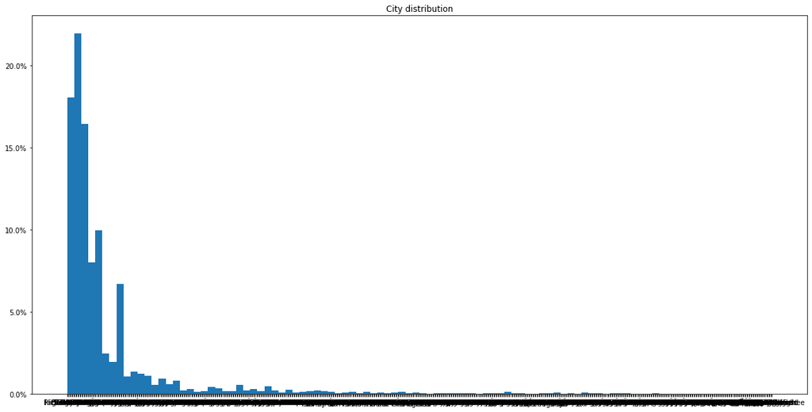

```python
data = train_test_set.loc[train_test_set['city']!="Las Vegas", 'city']
weights = _np.ones(len(data)) / len(data)
_plt.figure(figsize=(20,10))
_plt.hist(data, weights=weights, bins=100)
_plt.title("City distribution")
_plt.gca().yaxis.set_major_formatter(_PercentFormatter(1))
_plt.show()
```

```python
main_cities = city_count.where(city_count >= 100).dropna()
print(main_cities.to_string())
print(main_cities.shape)
main_cities = '|'.join(list(main_cities.index))
```

```
Las Vegas               208437.0
Phoenix                  71126.0
Toronto                  57047.0
Charlotte                40190.0
Scottsdale               36579.0
Pittsburgh               26891.0
Henderson                21518.0
MontrÃ©al                18531.0
Tempe                    18354.0
Mesa                     17235.0
Chandler                 15441.0
Gilbert                  14055.0
Cleveland                12873.0
Glendale                 10742.0
Madison                   9688.0
Markham                   8248.0
Calgary                   7958.0
Mississauga               7192.0
Peoria                    6582.0
North Las Vegas           4771.0
Surprise                  4117.0
Richmond Hill             3886.0
Goodyear                  3020.0
Concord                   2905.0
Scarborough               2544.0
Champaign                 2513.0
Vaughan                   2496.0
Avondale                  2451.0
Huntersville              2046.0
Lakewood                  2008.0
Matthews                  1986.0
North York                1977.0
Fort Mill                 1851.0
Brampton                  1643.0
Cave Creek                1538.0
Gastonia                  1282.0
Cornelius                 1278.0
Etobicoke                 1229.0
Akron                     1188.0
Westlake                  1118.0
```

[output cut: 122 more lines]

```
South Euclid               126.0
East York                  124.0
McKees Rocks               120.0
Bellevue                   117.0
Olmsted Falls              116.0
Braddock                   116.0
Blue Diamond               109.0
Ahwatukee                  109.0
New Kensington             108.0
Seven Hills                107.0
Mooresville                106.0
Upper Saint Clair          105.0
Longueuil                  105.0
North Ridgeville           102.0
(176,)
```

```python
train_test_set['city'] = train_test_set['city'].str.findall(main_cities)
train_test_set['city'] = train_test_set['city'].map(lambda x: 'Other' if x==[] else x[0])
train_test_set.head()
```

|  | review_id | user_id | business_id | stars_review | useful_review | funny_review | cool_review | bin_truth_score | real_truth_score | cuisine_av_hist | cuisine_av_hist_bin | cuisine_av_hist_real | coll_score | coll_score_bin | coll_score_real | likes | postal_code | latitude | longitude | review_count | stars_restaurant | OutdoorSeating | BusinessAcceptsCreditCards | RestaurantsDelivery | RestaurantsReservations | WiFi | Alcohol | categories | city | … |
| --- | --- | --- | --- | --- | --- | --- | --- | --- | --- | --- | --- | --- | --- | --- | --- | --- | --- | --- | --- | --- | --- | --- | --- | --- | --- | --- | --- | --- | --- | --- |
| 0 | hhVr1uH7XaRlbIHI8dYvbA | FYhU1fKQ7n11WQ7gcFYOag | --1UhMGODdWsrMastO9DZw | 5 | 0 | 0 | 0 | 1 | 0.622302 | 3.726715 | 3.704594 | 3.719363 | 3.752465 | 3.722907 | 3.760889 | 1 | T2P 0K5 | 51.049673 | -114.079977 | 24 | 4.0 | True | None | False | None | None | Beer&Wine | Restaurants, Mexican | Calgary | … |
| 1 | no4Eo4WloZRLwcYZP9gfhg | m-p-7WuB85UjsLDaxJXCXA | --1UhMGODdWsrMastO9DZw | 5 | 0 | 0 | 0 | 1 | 0.964784 | 4.000000 | 4.000000 | 4.000000 | 3.757630 | 3.808050 | 3.714375 | 1 | T2P 0K5 | 51.049673 | -114.079977 | 24 | 4.0 | True | None | False | None | None | Beer&Wine | Restaurants, Mexican | Calgary | … |
| 2 | 8QUwzeXeyJ3L15lKfhKLsQ | Bsy9F-59sl9OT_bvZNl3hA | --1UhMGODdWsrMastO9DZw | 1 | 0 | 0 | 0 | 1 | 0.871544 | 3.000000 | 3.000000 | 2.990709 | 2.926486 | 2.974252 | 2.874015 | 0 | T2P 0K5 | 51.049673 | -114.079977 | 24 | 4.0 | True | None | False | None | None | Beer&Wine | Restaurants, Mexican | Calgary | … |
| 3 | BIecLw546kAlD7kmlk7vXA | sTVGcezME7gYBhIlYtcfpg | --1UhMGODdWsrMastO9DZw | 2 | 0 | 0 | 0 | 1 | 0.988395 | 3.726715 | 3.704594 | 3.719363 | 3.752465 | 3.722907 | 3.760889 | 0 | T2P 0K5 | 51.049673 | -114.079977 | 24 | 4.0 | True | None | False | None | None | Beer&Wine | Restaurants, Mexican | Calgary | … |
| 4 | 0nVZ9Cg1A1lVA8EFWbt5lg | EisUuXVeVJN_FcFiE-tqwA | --6MefnULPED_I942VcFNA | 3 | 2 | 0 | 0 | 1 | 0.927789 | 2.966667 | 2.923077 | 2.954478 | 2.985799 | 2.973742 | 2.915633 | 0 | L4B 3P7 | 43.841694 | -79.399755 | 44 | 3.0 | False | True | False | True | No | Beer&Wine | Chinese, Restaurants | Richmond Hill | … |

We print and plot the distribution of the categories, to see the long tail and decide how many of them to keep.

```python
category_count = _pd.Series(', '.join(list(train_test_set['categories'])).split(', ')).value_counts()
print(category_count.to_string())
print(category_count.shape)
```

```
Restaurants                         712379
Food                                192841
Nightlife                           170259
Bars                                165959
American (Traditional)              123975
Breakfast & Brunch                  120310
American (New)                      117437
Sandwiches                           82264
Mexican                              73726
Burgers                              71598
Pizza                                67538
Italian                              62490
Seafood                              57228
Japanese                             53952
Salad                                49388
Fast Food                            46982
Event Planning & Services            45382
Coffee & Tea                         43592
Chinese                              42971
Asian Fusion                         42576
Sushi Bars                           42487
Cafes                                40002
Steakhouses                          37097
Desserts                             36523
Cocktail Bars                        36152
Barbeque                             33004
Sports Bars                          26918
Vegetarian                           25616
Chicken Wings                        24833
Vegan                                23768
Wine Bars                            23685
Caterers                             23328
Mediterranean                        22625
Specialty Food                       21980
Thai                                 21702
Bakeries                             21321
Wine & Spirits                       21204
Beer                                 21204
Pubs                                 21076
Arts & Entertainment                 20724
```

[output cut: 660 more lines]

```
Roofing                                  1
Officiants                               1
Music & DVDs                             1
Home Health Care                         1
Squash                                   1
Auto Upholstery                          1
Siding                                   1
Landscaping                              1
Motorcycle Repair                        1
Ski Schools                              1
Flooring                                 1
Taxis                                    1
Foundation Repair                        1
Minho                                    1
(714,)
```

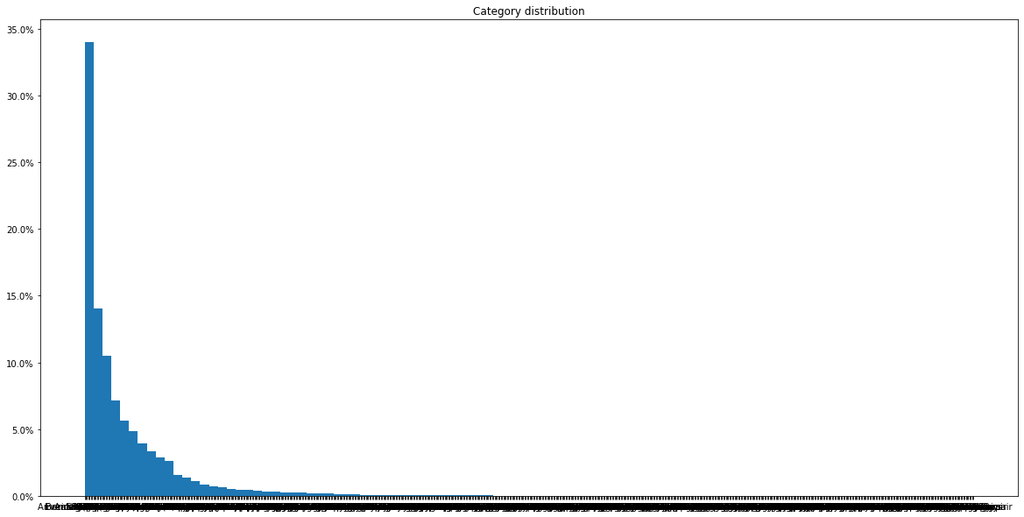

```python
data = category_count.drop(labels=['Restaurants', 'Food']).index
vals = category_count.drop(labels=['Restaurants', 'Food']).values
weights = vals / vals.sum()
_plt.figure(figsize=(20,10))
_plt.hist(data, weights=weights, bins=100)
_plt.title("Category distribution")
_plt.gca().yaxis.set_major_formatter(_PercentFormatter(1))
_plt.show()
```

```python
main_categories = category_count.drop(labels=['Restaurants', 'Food']).where(category_count >= 100).dropna()
print(main_categories.to_string())
print(main_categories.shape)
main_categories = '|'.join([_re.escape(x) for x in main_categories.index])
```

```
Nightlife                           170259.0
Bars                                165959.0
American (Traditional)              123975.0
Breakfast & Brunch                  120310.0
American (New)                      117437.0
Sandwiches                           82264.0
Mexican                              73726.0
Burgers                              71598.0
Pizza                                67538.0
Italian                              62490.0
Seafood                              57228.0
Japanese                             53952.0
Salad                                49388.0
Fast Food                            46982.0
Event Planning & Services            45382.0
Coffee & Tea                         43592.0
Chinese                              42971.0
Asian Fusion                         42576.0
Sushi Bars                           42487.0
Cafes                                40002.0
Steakhouses                          37097.0
Desserts                             36523.0
Cocktail Bars                        36152.0
Barbeque                             33004.0
Sports Bars                          26918.0
Vegetarian                           25616.0
Chicken Wings                        24833.0
Vegan                                23768.0
Wine Bars                            23685.0
Caterers                             23328.0
Mediterranean                        22625.0
Specialty Food                       21980.0
Thai                                 21702.0
Bakeries                             21321.0
Wine & Spirits                       21204.0
Beer                                 21204.0
Pubs                                 21076.0
Arts & Entertainment                 20724.0
Diners                               20452.0
Gastropubs                           17953.0
```

[output cut: 252 more lines]

```
South African                          127.0
Wedding Chapels                        119.0
Books                                  117.0
Music & Video                          117.0
Mags                                   117.0
Antiques                               112.0
Sporting Goods                         110.0
Animal Shelters                        110.0
Skin Care                              110.0
Stadiums & Arenas                      109.0
Pop-Up Restaurants                     106.0
Guamanian                              106.0
Food Tours                             105.0
Tobacco Shops                          100.0
(306,)
```

```python
train_test_set['categories'] = train_test_set['categories'].str.findall(main_categories)
train_test_set['categories'] = train_test_set['categories'].map(lambda x: set(x))
train_test_set['categories'] = train_test_set['categories'].map(lambda x: ['Other'] if not bool(x) else list(x))
train_test_set['categories'] = train_test_set['categories'].map(', '.join)
train_test_set.head()
```

|  | review_id | user_id | business_id | stars_review | useful_review | funny_review | cool_review | bin_truth_score | real_truth_score | cuisine_av_hist | cuisine_av_hist_bin | cuisine_av_hist_real | coll_score | coll_score_bin | coll_score_real | likes | postal_code | latitude | longitude | review_count | stars_restaurant | OutdoorSeating | BusinessAcceptsCreditCards | RestaurantsDelivery | RestaurantsReservations | WiFi | Alcohol | categories | city | … |
| --- | --- | --- | --- | --- | --- | --- | --- | --- | --- | --- | --- | --- | --- | --- | --- | --- | --- | --- | --- | --- | --- | --- | --- | --- | --- | --- | --- | --- | --- | --- |
| 0 | hhVr1uH7XaRlbIHI8dYvbA | FYhU1fKQ7n11WQ7gcFYOag | --1UhMGODdWsrMastO9DZw | 5 | 0 | 0 | 0 | 1 | 0.622302 | 3.726715 | 3.704594 | 3.719363 | 3.752465 | 3.722907 | 3.760889 | 1 | T2P 0K5 | 51.049673 | -114.079977 | 24 | 4.0 | True | None | False | None | None | Beer&Wine | Mexican | Calgary | … |
| 1 | no4Eo4WloZRLwcYZP9gfhg | m-p-7WuB85UjsLDaxJXCXA | --1UhMGODdWsrMastO9DZw | 5 | 0 | 0 | 0 | 1 | 0.964784 | 4.000000 | 4.000000 | 4.000000 | 3.757630 | 3.808050 | 3.714375 | 1 | T2P 0K5 | 51.049673 | -114.079977 | 24 | 4.0 | True | None | False | None | None | Beer&Wine | Mexican | Calgary | … |
| 2 | 8QUwzeXeyJ3L15lKfhKLsQ | Bsy9F-59sl9OT_bvZNl3hA | --1UhMGODdWsrMastO9DZw | 1 | 0 | 0 | 0 | 1 | 0.871544 | 3.000000 | 3.000000 | 2.990709 | 2.926486 | 2.974252 | 2.874015 | 0 | T2P 0K5 | 51.049673 | -114.079977 | 24 | 4.0 | True | None | False | None | None | Beer&Wine | Mexican | Calgary | … |
| 3 | BIecLw546kAlD7kmlk7vXA | sTVGcezME7gYBhIlYtcfpg | --1UhMGODdWsrMastO9DZw | 2 | 0 | 0 | 0 | 1 | 0.988395 | 3.726715 | 3.704594 | 3.719363 | 3.752465 | 3.722907 | 3.760889 | 0 | T2P 0K5 | 51.049673 | -114.079977 | 24 | 4.0 | True | None | False | None | None | Beer&Wine | Mexican | Calgary | … |
| 4 | 0nVZ9Cg1A1lVA8EFWbt5lg | EisUuXVeVJN_FcFiE-tqwA | --6MefnULPED_I942VcFNA | 3 | 2 | 0 | 0 | 1 | 0.927789 | 2.966667 | 2.923077 | 2.954478 | 2.985799 | 2.973742 | 2.915633 | 0 | L4B 3P7 | 43.841694 | -79.399755 | 44 | 3.0 | False | True | False | True | No | Beer&Wine | Chinese | Richmond Hill | … |

Now we apply the actual conversion

```python
train_test_set.shape
```

```
(712379, 93)
```

```python
cat_cols = ['OutdoorSeating', 'BusinessAcceptsCreditCards', 'RestaurantsDelivery', 'RestaurantsReservations', 'WiFi',
        'Alcohol', 'city']
train_test_set = _pd.get_dummies(train_test_set, columns=cat_cols, prefix=cat_cols)
train_test_set.shape
```

```
(712379, 281)
```

```python
categories = train_test_set['categories'].str.get_dummies(',')
f1 = lambda x: "categories_" + x
categories.rename(columns=f1, inplace=True)
train_test_set[categories.columns] = categories
train_test_set.drop(columns=['categories'], inplace=True)
train_test_set.shape
```

```
(712379, 787)
```

```python
oe = _OrdinalEncoder()
```

```python
ord_cols = ['Monday_Open', 'Tuesday_Open', 'Wednesday_Open', 'Thursday_Open', 'Friday_Open',
            'Saturday_Open', 'Sunday_Open', 'Monday_Close', 'Tuesday_Close', 'Wednesday_Close',
            'Thursday_Close','Friday_Close', 'Saturday_Close', 'Sunday_Close', 'postal_code']

train_test_set[ord_cols] = oe.fit_transform(train_test_set[ord_cols].to_numpy())
```

The resulting dataset

```python
train_test_set.info()
```

```
<class 'pandas.core.frame.DataFrame'>
Int64Index: 712379 entries, 0 to 153992
Columns: 787 entries, review_id to categories_Wraps
dtypes: float64(68), int32(1), int64(520), object(3), uint8(195)
memory usage: 3.3+ GB
```

```python
train_set = train_test_set[:_train_len]
test_set = train_test_set[_train_len:]
```

```python
train_set.head(10)
```

|  | review_id | user_id | business_id | stars_review | useful_review | funny_review | cool_review | bin_truth_score | real_truth_score | cuisine_av_hist | cuisine_av_hist_bin | cuisine_av_hist_real | coll_score | coll_score_bin | coll_score_real | likes | postal_code | latitude | longitude | review_count | stars_restaurant | Monday_Open | Tuesday_Open | Wednesday_Open | Thursday_Open | Friday_Open | Saturday_Open | Sunday_Open | Monday_Close | … |
| --- | --- | --- | --- | --- | --- | --- | --- | --- | --- | --- | --- | --- | --- | --- | --- | --- | --- | --- | --- | --- | --- | --- | --- | --- | --- | --- | --- | --- | --- | --- |
| 0 | hhVr1uH7XaRlbIHI8dYvbA | FYhU1fKQ7n11WQ7gcFYOag | --1UhMGODdWsrMastO9DZw | 5 | 0 | 0 | 0 | 1 | 0.622302 | 3.726715 | 3.704594 | 3.719363 | 3.752465 | 3.722907 | 3.760889 | 1 | 7778.0 | 51.049673 | -114.079977 | 24 | 4.0 | 29.0 | 26.0 | 30.0 | 29.0 | 27.0 | 25.0 | 61.0 | 51.0 | … |
| 1 | no4Eo4WloZRLwcYZP9gfhg | m-p-7WuB85UjsLDaxJXCXA | --1UhMGODdWsrMastO9DZw | 5 | 0 | 0 | 0 | 1 | 0.964784 | 4.000000 | 4.000000 | 4.000000 | 3.757630 | 3.808050 | 3.714375 | 1 | 7778.0 | 51.049673 | -114.079977 | 24 | 4.0 | 29.0 | 26.0 | 30.0 | 29.0 | 27.0 | 25.0 | 61.0 | 51.0 | … |
| 2 | 8QUwzeXeyJ3L15lKfhKLsQ | Bsy9F-59sl9OT_bvZNl3hA | --1UhMGODdWsrMastO9DZw | 1 | 0 | 0 | 0 | 1 | 0.871544 | 3.000000 | 3.000000 | 2.990709 | 2.926486 | 2.974252 | 2.874015 | 0 | 7778.0 | 51.049673 | -114.079977 | 24 | 4.0 | 29.0 | 26.0 | 30.0 | 29.0 | 27.0 | 25.0 | 61.0 | 51.0 | … |
| 3 | BIecLw546kAlD7kmlk7vXA | sTVGcezME7gYBhIlYtcfpg | --1UhMGODdWsrMastO9DZw | 2 | 0 | 0 | 0 | 1 | 0.988395 | 3.726715 | 3.704594 | 3.719363 | 3.752465 | 3.722907 | 3.760889 | 0 | 7778.0 | 51.049673 | -114.079977 | 24 | 4.0 | 29.0 | 26.0 | 30.0 | 29.0 | 27.0 | 25.0 | 61.0 | 51.0 | … |
| 4 | 0nVZ9Cg1A1lVA8EFWbt5lg | EisUuXVeVJN_FcFiE-tqwA | --6MefnULPED_I942VcFNA | 3 | 2 | 0 | 0 | 1 | 0.927789 | 2.966667 | 2.923077 | 2.954478 | 2.985799 | 2.973742 | 2.915633 | 0 | 3267.0 | 43.841694 | -79.399755 | 44 | 3.0 | 29.0 | 26.0 | 30.0 | 29.0 | 27.0 | 25.0 | 29.0 | 61.0 | … |
| 5 | rPNt-m2pdt-OR_NMQnHjCQ | tKIihU81IA3NjpsADuR-Tg | --6MefnULPED_I942VcFNA | 5 | 3 | 0 | 2 | 1 | 0.907921 | 4.400000 | 4.400000 | 4.395327 | 4.376569 | 4.405801 | 4.313458 | 1 | 3267.0 | 43.841694 | -79.399755 | 44 | 3.0 | 29.0 | 26.0 | 30.0 | 29.0 | 27.0 | 25.0 | 29.0 | 61.0 | … |
| 6 | Kg582pH05mZO_E6WS8PrKA | XNOs3Wz1Q_zdRgm1Hy05fg | --6MefnULPED_I942VcFNA | 1 | 2 | 2 | 1 | -1 | 0.184327 | 3.726715 | 3.704594 | 3.719363 | 3.752465 | 3.722907 | 3.760889 | 0 | 3267.0 | 43.841694 | -79.399755 | 44 | 3.0 | 29.0 | 26.0 | 30.0 | 29.0 | 27.0 | 25.0 | 29.0 | 61.0 | … |
| 7 | gkW6_UqV9b2XI_5ae8rBCg | HSHuSCJvIvf_Tof62uZPEw | --6MefnULPED_I942VcFNA | 2 | 2 | 1 | 0 | -1 | 0.687126 | 1.800000 | 1.692308 | 1.768813 | 1.816353 | 1.733574 | 1.724494 | 0 | 3267.0 | 43.841694 | -79.399755 | 44 | 3.0 | 29.0 | 26.0 | 30.0 | 29.0 | 27.0 | 25.0 | 29.0 | 61.0 | … |
| 8 | 02voOwsYf0cEdKNzt5IkwA | yvpX68yurPsope6KhBZrYA | --9e1ONYQuAa-CB_Rrw7Tw | 5 | 0 | 0 | 0 | 1 | 0.935335 | 3.726715 | 3.704594 | 3.719363 | 3.752465 | 3.722907 | 3.760889 | 1 | 530.0 | 36.123183 | -115.169190 | 1613 | 4.0 | 47.0 | 42.0 | 46.0 | 45.0 | 43.0 | 41.0 | 46.0 | 59.0 | … |
| 9 | M67I-I5ATaqtVLtKZTgygw | gvh8bvei5vwfoIYbNIvNDQ | --9e1ONYQuAa-CB_Rrw7Tw | 5 | 0 | 0 | 0 | -1 | 0.242671 | 3.000000 | 3.000000 | 3.040677 | 3.007972 | 3.009842 | 3.062459 | 1 | 530.0 | 36.123183 | -115.169190 | 1613 | 4.0 | 47.0 | 42.0 | 46.0 | 45.0 | 43.0 | 41.0 | 46.0 | 59.0 | … |

```python
train_set.shape
```

```
(558386, 787)
```

```python
train_set.to_pickle('../dataset/m2_n9/model_train_set_3.pickle')
```

```python
test_set.head(10)
```

|  | review_id | user_id | business_id | stars_review | useful_review | funny_review | cool_review | bin_truth_score | real_truth_score | cuisine_av_hist | cuisine_av_hist_bin | cuisine_av_hist_real | coll_score | coll_score_bin | coll_score_real | likes | postal_code | latitude | longitude | review_count | stars_restaurant | Monday_Open | Tuesday_Open | Wednesday_Open | Thursday_Open | Friday_Open | Saturday_Open | Sunday_Open | Monday_Close | … |
| --- | --- | --- | --- | --- | --- | --- | --- | --- | --- | --- | --- | --- | --- | --- | --- | --- | --- | --- | --- | --- | --- | --- | --- | --- | --- | --- | --- | --- | --- | --- |
| 0 | -j8YU0f5cL_fbnzsi1zkpA | rEsBrt6U7i8O4rC81lV6NQ | --6MefnULPED_I942VcFNA | 4 | 0 | 0 | 0 | 1 | 0.997555 | 3.726715 | 3.704594 | 3.719363 | 3.752465 | 3.722907 | 3.760889 | 1 | 3267.0 | 43.841694 | -79.399755 | 44 | 3.0 | 29.0 | 26.0 | 30.0 | 29.0 | 27.0 | 25.0 | 29.0 | 61.0 | … |
| 1 | 1vEQsKjTfGCcNdQ2Hhuhew | yEP9vNFq3edLldNzhm6hgQ | --6MefnULPED_I942VcFNA | 5 | 0 | 0 | 0 | -1 | 0.553523 | 1.800000 | 2.000000 | 1.799679 | 1.838975 | 2.007105 | 1.777964 | 1 | 3267.0 | 43.841694 | -79.399755 | 44 | 3.0 | 29.0 | 26.0 | 30.0 | 29.0 | 27.0 | 25.0 | 29.0 | 61.0 | … |
| 2 | P6ZgOVwyGlvis4m2Cra13g | uH8tTLb3Fz64GtEMWpZZcQ | --6MefnULPED_I942VcFNA | 5 | 0 | 0 | 0 | 1 | 0.990602 | 4.300000 | 4.333333 | 4.299574 | 4.349620 | 4.302949 | 4.288981 | 1 | 3267.0 | 43.841694 | -79.399755 | 44 | 3.0 | 29.0 | 26.0 | 30.0 | 29.0 | 27.0 | 25.0 | 29.0 | 61.0 | … |
| 3 | ap-_EXUS49YhyukC23p2Gw | NQhvEYuYOa5psBxEoNvq2g | --6MefnULPED_I942VcFNA | 1 | 0 | 0 | 0 | 1 | 0.968214 | 3.726715 | 3.704594 | 3.719363 | 3.752465 | 3.722907 | 3.760889 | 0 | 3267.0 | 43.841694 | -79.399755 | 44 | 3.0 | 29.0 | 26.0 | 30.0 | 29.0 | 27.0 | 25.0 | 29.0 | 61.0 | … |
| 4 | tKFDdiQ7rGMsdxgvIz2Sxg | zbrH2lnZgWicvwoXR0qcSg | --9e1ONYQuAa-CB_Rrw7Tw | 5 | 0 | 0 | 0 | 1 | 0.995667 | 3.726715 | 3.704594 | 3.719363 | 3.752465 | 3.722907 | 3.760889 | 1 | 530.0 | 36.123183 | -115.169190 | 1613 | 4.0 | 47.0 | 42.0 | 46.0 | 45.0 | 43.0 | 41.0 | 46.0 | 59.0 | … |
| 5 | NYG9z-whhsV99RbDR4KPWQ | 3l-Rmqcw_Cm1mTxlqEmLEQ | --9e1ONYQuAa-CB_Rrw7Tw | 5 | 1 | 0 | 5 | 1 | 0.123990 | 3.726715 | 3.704594 | 3.719363 | 3.752465 | 3.722907 | 3.760889 | 1 | 530.0 | 36.123183 | -115.169190 | 1613 | 4.0 | 47.0 | 42.0 | 46.0 | 45.0 | 43.0 | 41.0 | 46.0 | 59.0 | … |
| 6 | 14tBa-RMPWBP93y6KcOyQQ | 2vjNw6qpyvXAqRhSPzmHtQ | --9e1ONYQuAa-CB_Rrw7Tw | 2 | 1 | 0 | 0 | 1 | 0.530155 | 3.000000 | 3.704594 | 3.000000 | 2.995295 | 3.722907 | 3.009147 | 0 | 530.0 | 36.123183 | -115.169190 | 1613 | 4.0 | 47.0 | 42.0 | 46.0 | 45.0 | 43.0 | 41.0 | 46.0 | 59.0 | … |
| 7 | A-n5xtGMR5Frz2KPJTfRzw | WiY9q-Jz42huWzq90fgAWA | --9e1ONYQuAa-CB_Rrw7Tw | 2 | 0 | 0 | 0 | -1 | 0.474595 | 3.726715 | 3.704594 | 3.719363 | 3.752465 | 3.722907 | 3.760889 | 0 | 530.0 | 36.123183 | -115.169190 | 1613 | 4.0 | 47.0 | 42.0 | 46.0 | 45.0 | 43.0 | 41.0 | 46.0 | 59.0 | … |
| 8 | DqmGICsMu16YttevGUZCjg | q9q9nVaTYz7tScwZLHNO3A | --9e1ONYQuAa-CB_Rrw7Tw | 5 | 0 | 1 | 0 | 1 | 0.900049 | 3.726715 | 3.704594 | 3.719363 | 3.752465 | 3.722907 | 3.760889 | 1 | 530.0 | 36.123183 | -115.169190 | 1613 | 4.0 | 47.0 | 42.0 | 46.0 | 45.0 | 43.0 | 41.0 | 46.0 | 59.0 | … |
| 9 | pSHJpti6SfYIK3XhHzvrXg | q_sv4HEU4XM88x9z6WG-Tw | --9e1ONYQuAa-CB_Rrw7Tw | 2 | 0 | 0 | 0 | -1 | 0.487348 | 4.000000 | 4.000000 | 4.000000 | 4.001269 | 4.001652 | 4.015008 | 0 | 530.0 | 36.123183 | -115.169190 | 1613 | 4.0 | 47.0 | 42.0 | 46.0 | 45.0 | 43.0 | 41.0 | 46.0 | 59.0 | … |

```python
test_set.shape
```

```
(153993, 787)
```

```python
test_set.to_pickle('../dataset/m2_n9/model_test_set_3.pickle')
```

```python
_del_all()
```

## 6. Models

### 6.1 Linear SVM

(see the [docs](https://scikit-learn.org/stable/modules/generated/sklearn.svm.LinearSVC.html))

```python
train_set = _pd.read_pickle('../dataset/m2_n9/model_train_set_3.pickle')
train_set.head()
```

|  | review_id | user_id | business_id | stars_review | useful_review | funny_review | cool_review | bin_truth_score | real_truth_score | cuisine_av_hist | cuisine_av_hist_bin | cuisine_av_hist_real | coll_score | coll_score_bin | coll_score_real | likes | postal_code | latitude | longitude | review_count | stars_restaurant | Monday_Open | Tuesday_Open | Wednesday_Open | Thursday_Open | Friday_Open | Saturday_Open | Sunday_Open | Monday_Close | … |
| --- | --- | --- | --- | --- | --- | --- | --- | --- | --- | --- | --- | --- | --- | --- | --- | --- | --- | --- | --- | --- | --- | --- | --- | --- | --- | --- | --- | --- | --- | --- |
| 0 | ---HLAnHbuLi7vd5TL6uYg | zyp8SaRnZ94sWZpLrifS1Q | l6xZVTEtdZAvNpL1JhYGuw | 4 | 0 | 0 | 0 | -1 | 0.595406 | 3.726715 | 3.704594 | 3.719363 | -0.062602 | -0.064146 | -0.054028 | 1 | 2434.0 | 45.569980 | -73.199634 | 4 | 5.0 | 45.0 | 41.0 | 45.0 | 44.0 | 42.0 | 40.0 | 45.0 | 59.0 | … |
| 1 | ---L4b6VR6HoB-q7cfMWIA | 697iJkhX1mkVF9RNhn114Q | XiXu6WHbDoopKpeg7DfKdQ | 5 | 3 | 1 | 2 | 1 | 0.993384 | 3.013889 | 3.014925 | 3.039444 | -0.507850 | -0.525615 | -0.455618 | 1 | 4057.0 | 43.579150 | -79.683305 | 51 | 3.5 | 15.0 | 14.0 | 17.0 | 16.0 | 14.0 | 14.0 | 16.0 | 59.0 | … |
| 2 | ---sPYSgArT4Sd5v1nDVMQ | iVSuN8PrtKVtLzhNiu23uA | OumGHdbdp7WgyYMhcAdjhw | 1 | 0 | 0 | 0 | 1 | 0.519254 | 3.726715 | 3.704594 | 3.719363 | -0.062602 | -0.064146 | -0.054028 | 0 | 493.0 | 33.608745 | -112.359880 | 190 | 2.5 | 29.0 | 26.0 | 30.0 | 29.0 | 27.0 | 25.0 | 27.0 | 59.0 | … |
| 3 | --0SzSMXVUoAXfackNoB4g | v9P7J6hWWtIblnylQ5UBfA | iCQpiavjjPzJ5_3gPD5Ebg | 5 | 0 | 0 | 0 | 1 | 0.983368 | 1.000000 | 1.000000 | 1.000000 | -3.139748 | -3.132280 | -3.125614 | 1 | 530.0 | 36.109837 | -115.174212 | 4286 | 4.0 | 29.0 | 26.0 | 30.0 | 29.0 | 27.0 | 25.0 | 29.0 | 17.0 | … |
| 4 | --1JMhPk6K9fZo4FOp_yMw | 2xZ1mHP14as5RJ1KOrVU4A | QJatAcxYgK1Zp9BRZMAx7g | 2 | 0 | 0 | 0 | 1 | 0.866956 | 2.750000 | 2.666667 | 2.748879 | -1.212807 | -1.267752 | -1.191953 | 0 | 530.0 | 36.103061 | -115.173450 | 2844 | 4.0 | 29.0 | 26.0 | 30.0 | 25.0 | 23.0 | 25.0 | 29.0 | 0.0 | … |

```python
#sub_train_set = train_set[:round(train_set.shape[0]/3)]
sub_train_set = train_set
del train_set
sub_train_set.shape
```

```
(558386, 817)
```

```python
# define classifier
svc_classifier = _LinearSVC(random_state=0, max_iter=50000)
svc_classifier.get_params()
```

```
{'C': 1.0,
 'class_weight': None,
 'dual': True,
 'fit_intercept': True,
 'intercept_scaling': 1,
 'loss': 'squared_hinge',
 'max_iter': 50000,
 'multi_class': 'ovr',
 'penalty': 'l2',
 'random_state': 0,
 'tol': 0.0001,
 'verbose': 0}
```

```python
# fine tune classifier
# param_grid = {'C':[0.001,0.01,0.1,0.25,0.5,0.75,1,10,100,1000], 'gamma':[3,2,1,0.1,0.001,0.0001]}
param_grid = {'C':[0.001,0.01,0.1,0.25,0.5,0.75,1,10,100,1000]}
# grid = _GridSearchCV(estimator=svc_classifier, param_grid=param_grid, refit=True, verbose=2, cv=3, error_score=_np.nan, n_jobs=1, pre_dispatch=1)
grid = _GridSearchCV(estimator=svc_classifier, param_grid=param_grid, refit=True, verbose=2, cv=3, error_score=_np.nan, n_jobs=-1, pre_dispatch=6)
grid.fit(sub_train_set.drop(columns=['likes', 'stars_review', 'review_id', 'user_id', 'business_id']), sub_train_set['likes'])
print("best params:", grid.best_params_, "- best score:", grid.best_score_)
```

```
Fitting 3 folds for each of 10 candidates, totalling 30 fits
```

```
[Parallel(n_jobs=-1)]: Using backend LokyBackend with 12 concurrent workers.
[Parallel(n_jobs=-1)]: Done  30 out of  30 | elapsed: 1654.8min finished
```

```
best params: {'C': 0.001} - best score: 0.7436808945783024
```

```python
print("results:", grid.cv_results_)
```

```
results: {'mean_fit_time': array([19900.99567477, 19961.755548  , 19843.87850094, 19883.72761846,
       19875.85472822, 19892.886506  , 19819.18020558, 19831.93277272,
       19672.39210947, 19633.8438464 ]), 'std_fit_time': array([11.92322164, 24.47909948, 11.8002273 ,  2.51810785, 18.78170298,
       16.00907826,  5.86167115, 32.23873155,  4.59971461, 24.49313577]), 'mean_score_time': array([ 2.63927579,  5.25461706,  5.47336515, 10.05810801,  5.17248909,
        3.84837699,  2.75297205,  2.87099091,  2.33608754,  1.75242146]), 'std_score_time': array([0.28703641, 3.56587212, 1.62402285, 4.61803914, 2.93643879,
       1.57086447, 0.04191375, 0.27929337, 0.24098951, 0.2409035 ]), 'param_C': masked_array(data=[0.001, 0.01, 0.1, 0.25, 0.5, 0.75, 1, 10, 100, 1000],
             mask=[False, False, False, False, False, False, False, False,
                   False, False],
       fill_value='?',
            dtype=object), 'params': [{'C': 0.001}, {'C': 0.01}, {'C': 0.1}, {'C': 0.25}, {'C': 0.5}, {'C': 0.75}, {'C': 1}, {'C': 10}, {'C': 100}, {'C': 1000}], 'split0_test_score': array([0.74414656, 0.68984581, 0.71937893, 0.57199269, 0.71992156,
       0.70982109, 0.59223124, 0.63179498, 0.63454575, 0.63445441]), 'split1_test_score': array([0.74462735, 0.7388034 , 0.70227478, 0.59544507, 0.49747486,
       0.62558025, 0.65421645, 0.68013947, 0.66420958, 0.66396781]), 'split2_test_score': array([0.74226876, 0.72382984, 0.55883048, 0.61401831, 0.47335167,
       0.52100705, 0.69141129, 0.52799149, 0.52916273, 0.5987976 ]), 'mean_test_score': array([0.74368089, 0.71749292, 0.66016161, 0.59381861, 0.56358326,
       0.61880312, 0.6459528 , 0.61330871, 0.60930611, 0.63240661]), 'std_test_score': array([0.00101764, 0.020483  , 0.07199118, 0.0171954 , 0.11098627,
       0.0772319 , 0.04090958, 0.06347462, 0.0579493 , 0.02664495]), 'rank_test_score': array([ 1,  2,  3,  9, 10,  6,  4,  7,  8,  5])}
```

```python
del sub_train_set
train_set = _pd.read_pickle('../dataset/m2_n9/model_train_set_3.pickle')
```

```python
best_model = grid.best_estimator_
best_model.set_params(verbose=5)
best_model.get_params()
```

```
{'C': 0.001,
 'class_weight': None,
 'dual': True,
 'fit_intercept': True,
 'intercept_scaling': 1,
 'loss': 'squared_hinge',
 'max_iter': 50000,
 'multi_class': 'ovr',
 'penalty': 'l2',
 'random_state': 0,
 'tol': 0.0001,
 'verbose': 5}
```

```python
best_model.fit(train_set.drop(columns=['likes', 'stars_review', 'review_id', 'user_id', 'business_id']), train_set['likes'])
```

[output not shown]

```python
print("coef:", best_model.coef_)
print("intercept:", best_model.intercept_)
```

[output not shown]

[output cut: 149 more lines]

[output not shown]

```python
del train_set
test_set = _pd.read_pickle('../dataset/m2_n9/model_test_set_3.pickle')
test_set.head()
```

|  | review_id | user_id | business_id | stars_review | useful_review | funny_review | cool_review | bin_truth_score | real_truth_score | cuisine_av_hist | cuisine_av_hist_bin | cuisine_av_hist_real | coll_score | coll_score_bin | coll_score_real | likes | postal_code | latitude | longitude | review_count | stars_restaurant | Monday_Open | Tuesday_Open | Wednesday_Open | Thursday_Open | Friday_Open | Saturday_Open | Sunday_Open | Monday_Close | … |
| --- | --- | --- | --- | --- | --- | --- | --- | --- | --- | --- | --- | --- | --- | --- | --- | --- | --- | --- | --- | --- | --- | --- | --- | --- | --- | --- | --- | --- | --- | --- |
| 0 | ---j05qHS2X7FkXjjMKKtA | E6Aoz-3s4avfweIjziHjbA | cTbFJzHQzFSX-z3JF4abKQ | 5 | 1 | 0 | 1 | -1 | 0.229833 | 4.000000 | 4.285714 | 3.969038 | 0.674847 | 1.042857 | 0.678155 | 1 | 6145.0 | 43.670859 | -79.393423 | 178 | 3.5 | 58.0 | 55.0 | 59.0 | 61.0 | 57.0 | 58.0 | 61.0 | 68.0 | … |
| 1 | --4GjusuUCMh24c_oh_cEg | YOOsYiXGEtGFX_wSeZNcww | JytR7WvKyytDQNwOHUzSEg | 4 | 1 | 0 | 0 | 1 | 0.987487 | 3.604167 | 3.607143 | 3.610109 | -0.099146 | -0.096170 | -0.093204 | 1 | 6429.0 | 43.650017 | -79.389188 | 6 | 4.0 | 29.0 | 26.0 | 30.0 | 29.0 | 27.0 | 29.0 | 61.0 | 55.0 | … |
| 2 | --4RpVT5wHJ9AfnZkIC3tw | Bdw4E8jFVd6-CbhrNAJ_EA | -CfFjcCcGGDM9MVH_d42RQ | 5 | 0 | 0 | 0 | -1 | 0.524751 | 5.000000 | 3.704594 | 5.000000 | 1.156489 | -0.064146 | 1.182474 | 1 | 460.0 | 33.276651 | -111.874092 | 369 | 4.0 | 0.0 | 26.0 | 30.0 | 29.0 | 27.0 | 25.0 | 29.0 | 0.0 | … |
| 3 | --4vJzoC0m5h-yodXv-qCw | jm4a1GghQ4zLCN3lQGMQUQ | XMPBg6r_LqZhy9Cf-4ZJrA | 2 | 0 | 0 | 0 | 1 | 0.979875 | 3.726715 | 3.704594 | 3.719363 | -0.062602 | -0.064146 | -0.054028 | 0 | 246.0 | 41.464592 | -81.841481 | 23 | 2.5 | 13.0 | 12.0 | 15.0 | 14.0 | 12.0 | 12.0 | 17.0 | 55.0 | … |
| 4 | --B9JxEb5gY5gAgD2BRhDQ | x_6VdQU3CIdakwHod-dNzA | Fn_IxcCtZl1EoS81sq_s9w | 3 | 1 | 0 | 0 | 1 | 0.662471 | 3.726715 | 3.704594 | 3.719363 | -0.062602 | -0.064146 | -0.054028 | 0 | 438.0 | 33.219015 | -111.791210 | 142 | 3.5 | 0.0 | 37.0 | 41.0 | 40.0 | 27.0 | 25.0 | 29.0 | 0.0 | … |

```python
# test classifier
predic = best_model.predict(test_set.drop(columns=['likes', 'stars_review', 'review_id', 'user_id', 'business_id']))
print("predictions:\n", predic)
```

```
predictions:
 [1 1 1 ... 1 1 1]
```

```python
set(predic)
```

```
{0, 1}
```

```python
# evaluate classifier

print("Report for Support Vector Machine:")
print(_classification_report(test_set['likes'], predic))

print("Accuracy for Support Vector Machine:", _accuracy_score(test_set['likes'], predic)*100)
```

```
Report for Support Vector Machine:
              precision    recall  f1-score   support

           0       0.70      0.36      0.48     50930
           1       0.74      0.92      0.82    103063

    accuracy                           0.74    153993
   macro avg       0.72      0.64      0.65    153993
weighted avg       0.73      0.74      0.71    153993

Accuracy for Support Vector Machine: 73.72737721844499
```

```python
# Confusion matrix for SVC

print("Confusion Matrix for SVC: ")
_confusion_matrix(test_set['likes'], predic)
```

[output not shown]

```
array([[18347, 32583],
       [ 7875, 95188]], dtype=int64)
```

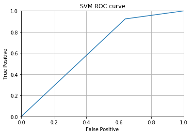

```python
# draw ROC curve
fpr, tpr, thresholds = _roc_curve(test_set['likes'], predic)

_plt.plot(fpr,tpr)
_plt.xlim([0.0,1.0])
_plt.ylim([0.0,1.0])

_plt.title("SVM ROC curve")
_plt.xlabel("False Positive")
_plt.ylabel("True Positive")

_plt.grid(True)
_plt.show()
```

```python
_jl.dump(best_model, "../models/best_SVM.joblib")
```

```
['../models/best_SVM.joblib']
```

```python
_del_all()
```

### 6.2 Random Forest Classifier

(see the [docs](https://scikit-learn.org/stable/modules/generated/sklearn.ensemble.RandomForestClassifier.html))

```python
train_set = _pd.read_pickle('../dataset/m2_n9/model_train_set_3.pickle')
train_set.head()
```

|  | review_id | user_id | business_id | stars_review | useful_review | funny_review | cool_review | bin_truth_score | real_truth_score | cuisine_av_hist | cuisine_av_hist_bin | cuisine_av_hist_real | coll_score | coll_score_bin | coll_score_real | likes | postal_code | latitude | longitude | review_count | stars_restaurant | Monday_Open | Tuesday_Open | Wednesday_Open | Thursday_Open | Friday_Open | Saturday_Open | Sunday_Open | Monday_Close | … |
| --- | --- | --- | --- | --- | --- | --- | --- | --- | --- | --- | --- | --- | --- | --- | --- | --- | --- | --- | --- | --- | --- | --- | --- | --- | --- | --- | --- | --- | --- | --- |
| 0 | ---HLAnHbuLi7vd5TL6uYg | zyp8SaRnZ94sWZpLrifS1Q | l6xZVTEtdZAvNpL1JhYGuw | 4 | 0 | 0 | 0 | -1 | 0.595406 | 3.726715 | 3.704594 | 3.719363 | -0.062602 | -0.064146 | -0.054028 | 1 | 2434.0 | 45.569980 | -73.199634 | 4 | 5.0 | 45.0 | 41.0 | 45.0 | 44.0 | 42.0 | 40.0 | 45.0 | 59.0 | … |
| 1 | ---L4b6VR6HoB-q7cfMWIA | 697iJkhX1mkVF9RNhn114Q | XiXu6WHbDoopKpeg7DfKdQ | 5 | 3 | 1 | 2 | 1 | 0.993384 | 3.013889 | 3.014925 | 3.039444 | -0.507850 | -0.525615 | -0.455618 | 1 | 4057.0 | 43.579150 | -79.683305 | 51 | 3.5 | 15.0 | 14.0 | 17.0 | 16.0 | 14.0 | 14.0 | 16.0 | 59.0 | … |
| 2 | ---sPYSgArT4Sd5v1nDVMQ | iVSuN8PrtKVtLzhNiu23uA | OumGHdbdp7WgyYMhcAdjhw | 1 | 0 | 0 | 0 | 1 | 0.519254 | 3.726715 | 3.704594 | 3.719363 | -0.062602 | -0.064146 | -0.054028 | 0 | 493.0 | 33.608745 | -112.359880 | 190 | 2.5 | 29.0 | 26.0 | 30.0 | 29.0 | 27.0 | 25.0 | 27.0 | 59.0 | … |
| 3 | --0SzSMXVUoAXfackNoB4g | v9P7J6hWWtIblnylQ5UBfA | iCQpiavjjPzJ5_3gPD5Ebg | 5 | 0 | 0 | 0 | 1 | 0.983368 | 1.000000 | 1.000000 | 1.000000 | -3.139748 | -3.132280 | -3.125614 | 1 | 530.0 | 36.109837 | -115.174212 | 4286 | 4.0 | 29.0 | 26.0 | 30.0 | 29.0 | 27.0 | 25.0 | 29.0 | 17.0 | … |
| 4 | --1JMhPk6K9fZo4FOp_yMw | 2xZ1mHP14as5RJ1KOrVU4A | QJatAcxYgK1Zp9BRZMAx7g | 2 | 0 | 0 | 0 | 1 | 0.866956 | 2.750000 | 2.666667 | 2.748879 | -1.212807 | -1.267752 | -1.191953 | 0 | 530.0 | 36.103061 | -115.173450 | 2844 | 4.0 | 29.0 | 26.0 | 30.0 | 25.0 | 23.0 | 25.0 | 29.0 | 0.0 | … |

```python
sub_train_set = train_set[:round(train_set.shape[0]/2)]
#sub_train_set = train_set
del train_set
sub_train_set.shape
```

```
(279193, 817)
```

```python
random_forest = _RandomForestClassifier(n_jobs = -1, random_state = 0)
random_forest.get_params()
```

```
{'bootstrap': True,
 'class_weight': None,
 'criterion': 'gini',
 'max_depth': None,
 'max_features': 'auto',
 'max_leaf_nodes': None,
 'min_impurity_decrease': 0.0,
 'min_impurity_split': None,
 'min_samples_leaf': 1,
 'min_samples_split': 2,
 'min_weight_fraction_leaf': 0.0,
 'n_estimators': 'warn',
 'n_jobs': -1,
 'oob_score': False,
 'random_state': 0,
 'verbose': 0,
 'warm_start': False}
```

```python
# fine tune classifier

param_grid = {
    'bootstrap': [True, False],
    'max_depth': [10, 30, 50],
    'min_samples_leaf': [1, 2, 4],
    'min_samples_split': [2, 5, 10],
    'n_estimators': [200, 500, 1000],
    'criterion': ['gini', 'entropy']}

grid = _GridSearchCV(estimator=random_forest, param_grid=param_grid, refit=False, verbose=5, cv=3, error_score=_np.nan, n_jobs=-1, pre_dispatch=6)
grid.fit(sub_train_set.drop(columns=['likes', 'stars_review', 'review_id', 'user_id', 'business_id']), sub_train_set['likes'])
```

```
Fitting 3 folds for each of 324 candidates, totalling 972 fits
```

```
[Parallel(n_jobs=-1)]: Using backend LokyBackend with 12 concurrent workers.
[Parallel(n_jobs=-1)]: Done  12 tasks      | elapsed: 25.0min
[Parallel(n_jobs=-1)]: Done  66 tasks      | elapsed: 134.9min
[Parallel(n_jobs=-1)]: Done 156 tasks      | elapsed: 558.6min
[Parallel(n_jobs=-1)]: Done 282 tasks      | elapsed: 1123.2min
[Parallel(n_jobs=-1)]: Done 444 tasks      | elapsed: 2490.3min
[Parallel(n_jobs=-1)]: Done 642 tasks      | elapsed: 3490.7min
[Parallel(n_jobs=-1)]: Done 876 tasks      | elapsed: 4913.4min
[Parallel(n_jobs=-1)]: Done 972 out of 972 | elapsed: 5701.6min finished
```

```
GridSearchCV(cv=3, error_score=nan,
             estimator=RandomForestClassifier(bootstrap=True, class_weight=None,
                                              criterion='gini', max_depth=None,
                                              max_features='auto',
                                              max_leaf_nodes=None,
                                              min_impurity_decrease=0.0,
                                              min_impurity_split=None,
                                              min_samples_leaf=1,
                                              min_samples_split=2,
                                              min_weight_fraction_leaf=0.0,
                                              n_estimators='warn', n_jobs=-1,
                                              oob_score=False, random_state=0,
                                              verbose=0, warm_start=False),
             iid='warn', n_jobs=-1,
             param_grid={'bootstrap': [True, False],
                         'criterion': ['gini', 'entropy'],
                         'max_depth': [10, 30, 50],
                         'min_samples_leaf': [1, 2, 4],
                         'min_samples_split': [2, 5, 10],
                         'n_estimators': [200, 500, 1000]},
             pre_dispatch=6, refit=False, return_train_score=False,
             scoring=None, verbose=5)
```

```python
print("best params:\n", grid.best_params_)
print("best score:", grid.best_score_)
```

```
best params:
 {'bootstrap': False, 'criterion': 'entropy', 'max_depth': 50, 'min_samples_leaf': 2, 'min_samples_split': 10, 'n_estimators': 1000}
best score: 0.7453481999906875
```

```python
with open("../models/random_forest_params.txt", 'w') as f:
    f.write(str(grid.best_params_))
```

```python
print("results:", grid.cv_results_)
```

[output not shown]

[output cut: 1036 more lines]

[output not shown]

```python
del sub_train_set
train_set = _pd.read_pickle('../dataset/m2_n9/model_train_set_3.pickle')
```

```python
params = grid.best_params_
params['n_jobs'] = -1
params['verbose'] = 5
best_model = _RandomForestClassifier(**params)
best_model.get_params()
```

```
{'bootstrap': False,
 'class_weight': None,
 'criterion': 'entropy',
 'max_depth': 50,
 'max_features': 'auto',
 'max_leaf_nodes': None,
 'min_impurity_decrease': 0.0,
 'min_impurity_split': None,
 'min_samples_leaf': 2,
 'min_samples_split': 10,
 'min_weight_fraction_leaf': 0.0,
 'n_estimators': 1000,
 'n_jobs': -1,
 'oob_score': False,
 'random_state': None,
 'verbose': 5,
 'warm_start': False}
```

```python
best_model.fit(train_set.drop(columns=['likes', 'stars_review', 'review_id', 'user_id', 'business_id']), train_set['likes'])
```

```
[Parallel(n_jobs=-1)]: Using backend ThreadingBackend with 12 concurrent workers.
```

[output not shown]

```
[Parallel(n_jobs=-1)]: Done  48 tasks      | elapsed:  2.0min
```

[output not shown]

[output cut: 35 more lines]

[output not shown]

```
[Parallel(n_jobs=-1)]: Done 138 tasks      | elapsed:  5.6min
```

[output not shown]

[output cut: 70 more lines]

[output not shown]

```
[Parallel(n_jobs=-1)]: Done 264 tasks      | elapsed: 10.3min
```

[output not shown]

[output cut: 107 more lines]

[output not shown]

```
[Parallel(n_jobs=-1)]: Done 426 tasks      | elapsed: 16.2min
```

[output not shown]

[output cut: 143 more lines]

[output not shown]

```
[Parallel(n_jobs=-1)]: Done 624 tasks      | elapsed: 23.3min
```

[output not shown]

[output cut: 179 more lines]

[output not shown]

```
[Parallel(n_jobs=-1)]: Done 858 tasks      | elapsed: 31.8min
```

[output not shown]

[output cut: 76 more lines]

[output not shown]

```
[Parallel(n_jobs=-1)]: Done 1000 out of 1000 | elapsed: 36.7min finished
```

```
RandomForestClassifier(bootstrap=False, class_weight=None, criterion='entropy',
                       max_depth=50, max_features='auto', max_leaf_nodes=None,
                       min_impurity_decrease=0.0, min_impurity_split=None,
                       min_samples_leaf=2, min_samples_split=10,
                       min_weight_fraction_leaf=0.0, n_estimators=1000,
                       n_jobs=-1, oob_score=False, random_state=None, verbose=5,
                       warm_start=False)
```

```python
_jl.dump(best_model, "../models/best_Random_Forest_2.joblib")
```

```
['../models/best_Random_Forest_2.joblib']
```

```python
del train_set
test_set = _pd.read_pickle('../dataset/m2_n9/model_test_set_3.pickle')
test_set.head()
```

|  | review_id | user_id | business_id | stars_review | useful_review | funny_review | cool_review | bin_truth_score | real_truth_score | cuisine_av_hist | cuisine_av_hist_bin | cuisine_av_hist_real | coll_score | coll_score_bin | coll_score_real | likes | postal_code | latitude | longitude | review_count | stars_restaurant | Monday_Open | Tuesday_Open | Wednesday_Open | Thursday_Open | Friday_Open | Saturday_Open | Sunday_Open | Monday_Close | … |
| --- | --- | --- | --- | --- | --- | --- | --- | --- | --- | --- | --- | --- | --- | --- | --- | --- | --- | --- | --- | --- | --- | --- | --- | --- | --- | --- | --- | --- | --- | --- |
| 0 | -j8YU0f5cL_fbnzsi1zkpA | rEsBrt6U7i8O4rC81lV6NQ | --6MefnULPED_I942VcFNA | 4 | 0 | 0 | 0 | 1 | 0.997555 | 3.726715 | 3.704594 | 3.719363 | 3.752465 | 3.722907 | 3.760889 | 1 | 3267.0 | 43.841694 | -79.399755 | 44 | 3.0 | 29.0 | 26.0 | 30.0 | 29.0 | 27.0 | 25.0 | 29.0 | 61.0 | … |
| 1 | 1vEQsKjTfGCcNdQ2Hhuhew | yEP9vNFq3edLldNzhm6hgQ | --6MefnULPED_I942VcFNA | 5 | 0 | 0 | 0 | -1 | 0.553523 | 1.800000 | 2.000000 | 1.799679 | 1.838975 | 2.007105 | 1.777964 | 1 | 3267.0 | 43.841694 | -79.399755 | 44 | 3.0 | 29.0 | 26.0 | 30.0 | 29.0 | 27.0 | 25.0 | 29.0 | 61.0 | … |
| 2 | P6ZgOVwyGlvis4m2Cra13g | uH8tTLb3Fz64GtEMWpZZcQ | --6MefnULPED_I942VcFNA | 5 | 0 | 0 | 0 | 1 | 0.990602 | 4.300000 | 4.333333 | 4.299574 | 4.349620 | 4.302949 | 4.288981 | 1 | 3267.0 | 43.841694 | -79.399755 | 44 | 3.0 | 29.0 | 26.0 | 30.0 | 29.0 | 27.0 | 25.0 | 29.0 | 61.0 | … |
| 3 | ap-_EXUS49YhyukC23p2Gw | NQhvEYuYOa5psBxEoNvq2g | --6MefnULPED_I942VcFNA | 1 | 0 | 0 | 0 | 1 | 0.968214 | 3.726715 | 3.704594 | 3.719363 | 3.752465 | 3.722907 | 3.760889 | 0 | 3267.0 | 43.841694 | -79.399755 | 44 | 3.0 | 29.0 | 26.0 | 30.0 | 29.0 | 27.0 | 25.0 | 29.0 | 61.0 | … |
| 4 | tKFDdiQ7rGMsdxgvIz2Sxg | zbrH2lnZgWicvwoXR0qcSg | --9e1ONYQuAa-CB_Rrw7Tw | 5 | 0 | 0 | 0 | 1 | 0.995667 | 3.726715 | 3.704594 | 3.719363 | 3.752465 | 3.722907 | 3.760889 | 1 | 530.0 | 36.123183 | -115.169190 | 1613 | 4.0 | 47.0 | 42.0 | 46.0 | 45.0 | 43.0 | 41.0 | 46.0 | 59.0 | … |

```python
# test classifier
predic = best_model.predict(test_set.drop(columns=['likes', 'stars_review', 'review_id', 'user_id', 'business_id']))
print("predictions:\n", predic)
```

```
[Parallel(n_jobs=12)]: Using backend ThreadingBackend with 12 concurrent workers.
[Parallel(n_jobs=12)]: Done  48 tasks      | elapsed:    1.8s
[Parallel(n_jobs=12)]: Done 138 tasks      | elapsed:    4.8s
[Parallel(n_jobs=12)]: Done 264 tasks      | elapsed:    8.9s
[Parallel(n_jobs=12)]: Done 426 tasks      | elapsed:   13.3s
[Parallel(n_jobs=12)]: Done 624 tasks      | elapsed:   18.8s
[Parallel(n_jobs=12)]: Done 858 tasks      | elapsed:   25.2s
[Parallel(n_jobs=12)]: Done 1000 out of 1000 | elapsed:   28.9s finished
```

```
predictions:
 [0 0 1 ... 0 1 0]
```

```python
set(predic)
```

```
{0, 1}
```

```python
# evaluate classifier

print("Report for Random Forest classifier:")
print(_classification_report(test_set['likes'], predic))

print("Accuracy for Random Forest Classifier:", _accuracy_score(test_set['likes'], predic)*100)
```

```
Report for Random Forest classifier:
              precision    recall  f1-score   support

           0       0.69      0.40      0.51     50930
           1       0.75      0.91      0.83    103063

    accuracy                           0.74    153993
   macro avg       0.72      0.66      0.67    153993
weighted avg       0.73      0.74      0.72    153993

Accuracy for Random Forest Classifier: 74.16765697142078
```

```python
# Confusion matrix for Random Forest

print("Confusion Matrix for Random Forest: ")
_confusion_matrix(test_set['likes'], predic)
```

[output not shown]

```
array([[20372, 30558],
       [ 9222, 93841]], dtype=int64)
```

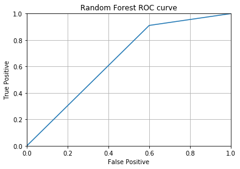

```python
# draw ROC curve
fpr, tpr, thresholds = _roc_curve(test_set['likes'], predic)

_plt.plot(fpr,tpr)
_plt.xlim([0.0,1.0])
_plt.ylim([0.0,1.0])

_plt.title("Random Forest ROC curve")
_plt.xlabel("False Positive")
_plt.ylabel("True Positive")

_plt.grid(True)
_plt.show()
```

```python
%reset
```

### 6.3 Deep Learning

```python
train_set = _pd.read_pickle('../dataset/m2_n9/model_train_set_3.pickle')
train_set.head()
```

|  | review_id | user_id | business_id | stars_review | useful_review | funny_review | cool_review | bin_truth_score | real_truth_score | cuisine_av_hist | cuisine_av_hist_bin | cuisine_av_hist_real | coll_score | coll_score_bin | coll_score_real | likes | postal_code | latitude | longitude | review_count | stars_restaurant | Monday_Open | Tuesday_Open | Wednesday_Open | Thursday_Open | Friday_Open | Saturday_Open | Sunday_Open | Monday_Close | … |
| --- | --- | --- | --- | --- | --- | --- | --- | --- | --- | --- | --- | --- | --- | --- | --- | --- | --- | --- | --- | --- | --- | --- | --- | --- | --- | --- | --- | --- | --- | --- |
| 0 | hhVr1uH7XaRlbIHI8dYvbA | FYhU1fKQ7n11WQ7gcFYOag | --1UhMGODdWsrMastO9DZw | 5 | 0 | 0 | 0 | 1 | 0.622302 | 3.726715 | 3.704594 | 3.719363 | 3.752465 | 3.722907 | 3.760889 | 1 | 7778.0 | 51.049673 | -114.079977 | 24 | 4.0 | 29.0 | 26.0 | 30.0 | 29.0 | 27.0 | 25.0 | 61.0 | 51.0 | … |
| 1 | no4Eo4WloZRLwcYZP9gfhg | m-p-7WuB85UjsLDaxJXCXA | --1UhMGODdWsrMastO9DZw | 5 | 0 | 0 | 0 | 1 | 0.964784 | 4.000000 | 4.000000 | 4.000000 | 3.757630 | 3.808050 | 3.714375 | 1 | 7778.0 | 51.049673 | -114.079977 | 24 | 4.0 | 29.0 | 26.0 | 30.0 | 29.0 | 27.0 | 25.0 | 61.0 | 51.0 | … |
| 2 | 8QUwzeXeyJ3L15lKfhKLsQ | Bsy9F-59sl9OT_bvZNl3hA | --1UhMGODdWsrMastO9DZw | 1 | 0 | 0 | 0 | 1 | 0.871544 | 3.000000 | 3.000000 | 2.990709 | 2.926486 | 2.974252 | 2.874015 | 0 | 7778.0 | 51.049673 | -114.079977 | 24 | 4.0 | 29.0 | 26.0 | 30.0 | 29.0 | 27.0 | 25.0 | 61.0 | 51.0 | … |
| 3 | BIecLw546kAlD7kmlk7vXA | sTVGcezME7gYBhIlYtcfpg | --1UhMGODdWsrMastO9DZw | 2 | 0 | 0 | 0 | 1 | 0.988395 | 3.726715 | 3.704594 | 3.719363 | 3.752465 | 3.722907 | 3.760889 | 0 | 7778.0 | 51.049673 | -114.079977 | 24 | 4.0 | 29.0 | 26.0 | 30.0 | 29.0 | 27.0 | 25.0 | 61.0 | 51.0 | … |
| 4 | 0nVZ9Cg1A1lVA8EFWbt5lg | EisUuXVeVJN_FcFiE-tqwA | --6MefnULPED_I942VcFNA | 3 | 2 | 0 | 0 | 1 | 0.927789 | 2.966667 | 2.923077 | 2.954478 | 2.985799 | 2.973742 | 2.915633 | 0 | 3267.0 | 43.841694 | -79.399755 | 44 | 3.0 | 29.0 | 26.0 | 30.0 | 29.0 | 27.0 | 25.0 | 29.0 | 61.0 | … |

$N_h = \frac {N_s} {(\alpha * (N_i + N_o))}$

- $N_h$ is the number of hidden neurons
- $N_i$ is the number of input neurons
- $N_o$ is the number of output neurons
- $N_s$ number of samples in training data set.
- $\alpha$ an arbitrary scaling factor usually between 5 and 10.

Presa da [qua](https://stats.stackexchange.com/questions/181/how-to-choose-the-number-of-hidden-layers-and-nodes-in-a-feedforward-neural-netw)

```python
# Number of neurons for hiddens layer
number_samples, number_features = train_set.drop(columns = ['likes', 'stars_review', 'review_id', 'user_id', 'business_id']).shape

number_input_neurons = number_features
number_output_neurons = 1
number_train_semples = number_samples
alpha = 6

number_hidden_neurons = round(number_train_semples / (alpha * (number_input_neurons + number_output_neurons)))
print(number_hidden_neurons)
```

```
119
```

```python
classifier = _Sequential()

# First Hidden Layer
classifier.add(_Dense(number_hidden_neurons, activation = 'relu', kernel_initializer = 'random_normal', input_dim = number_features))

# Second Hidden Layer
classifier.add(_Dense(number_hidden_neurons, activation = 'relu', kernel_initializer = 'random_normal'))

# Third Hidden Layer
classifier.add(_Dense(number_hidden_neurons, activation = 'relu', kernel_initializer = 'random_normal'))

# Output Layer
classifier.add(_Dense(1, activation = 'sigmoid', kernel_initializer = 'random_normal'))

# Compiling the neural network
classifier.compile(optimizer = 'adam', loss = 'binary_crossentropy', metrics = ['accuracy'])
```

```python
# Fitting the data to the training dataset
classifier.fit(train_set.drop(
    columns = ['likes', 'stars_review', 'review_id', 'user_id', 'business_id']),
    train_set['likes'], validation_split = 0.3, batch_size = 100, epochs = 100)
```

```
Train on 390870 samples, validate on 167516 samples
```

```
<keras.callbacks.History at 0x234bf5d0908>
```

```python
# Save trained model
classifier.save("../models/trained_deep_neural_network.h5")
```

```python
# evaluation of the model training
evaluation = classifier.evaluate(train_set.drop(columns = ['likes', 'stars_review', 'review_id', 'user_id', 'business_id']), train_set['likes'])
print(evaluation)
```

```
[0.516120845819726, 0.7530937380230908]
```

The neural network gives us the probability that the class is 1, we [binarize](https://scikit-learn.org/stable/modules/generated/sklearn.preprocessing.binarize.html) with threshold to 0.5 thus having the labels with probability up to 0.5 at 0, the others at 1. We could use two nerones in output thus having a probability vector expressing the probability that it is 1 and the probability that it is 0, but only an equivalent approach would result.

```python
del train_set
test_set = _pd.read_pickle('../dataset/m2_n9/model_test_set_3.pickle')
test_set.head()
```

|  | review_id | user_id | business_id | stars_review | useful_review | funny_review | cool_review | bin_truth_score | real_truth_score | cuisine_av_hist | cuisine_av_hist_bin | cuisine_av_hist_real | coll_score | coll_score_bin | coll_score_real | likes | postal_code | latitude | longitude | review_count | stars_restaurant | Monday_Open | Tuesday_Open | Wednesday_Open | Thursday_Open | Friday_Open | Saturday_Open | Sunday_Open | Monday_Close | … |
| --- | --- | --- | --- | --- | --- | --- | --- | --- | --- | --- | --- | --- | --- | --- | --- | --- | --- | --- | --- | --- | --- | --- | --- | --- | --- | --- | --- | --- | --- | --- |
| 0 | -j8YU0f5cL_fbnzsi1zkpA | rEsBrt6U7i8O4rC81lV6NQ | --6MefnULPED_I942VcFNA | 4 | 0 | 0 | 0 | 1 | 0.997555 | 3.726715 | 3.704594 | 3.719363 | 3.752465 | 3.722907 | 3.760889 | 1 | 3267.0 | 43.841694 | -79.399755 | 44 | 3.0 | 29.0 | 26.0 | 30.0 | 29.0 | 27.0 | 25.0 | 29.0 | 61.0 | … |
| 1 | 1vEQsKjTfGCcNdQ2Hhuhew | yEP9vNFq3edLldNzhm6hgQ | --6MefnULPED_I942VcFNA | 5 | 0 | 0 | 0 | -1 | 0.553523 | 1.800000 | 2.000000 | 1.799679 | 1.838975 | 2.007105 | 1.777964 | 1 | 3267.0 | 43.841694 | -79.399755 | 44 | 3.0 | 29.0 | 26.0 | 30.0 | 29.0 | 27.0 | 25.0 | 29.0 | 61.0 | … |
| 2 | P6ZgOVwyGlvis4m2Cra13g | uH8tTLb3Fz64GtEMWpZZcQ | --6MefnULPED_I942VcFNA | 5 | 0 | 0 | 0 | 1 | 0.990602 | 4.300000 | 4.333333 | 4.299574 | 4.349620 | 4.302949 | 4.288981 | 1 | 3267.0 | 43.841694 | -79.399755 | 44 | 3.0 | 29.0 | 26.0 | 30.0 | 29.0 | 27.0 | 25.0 | 29.0 | 61.0 | … |
| 3 | ap-_EXUS49YhyukC23p2Gw | NQhvEYuYOa5psBxEoNvq2g | --6MefnULPED_I942VcFNA | 1 | 0 | 0 | 0 | 1 | 0.968214 | 3.726715 | 3.704594 | 3.719363 | 3.752465 | 3.722907 | 3.760889 | 0 | 3267.0 | 43.841694 | -79.399755 | 44 | 3.0 | 29.0 | 26.0 | 30.0 | 29.0 | 27.0 | 25.0 | 29.0 | 61.0 | … |
| 4 | tKFDdiQ7rGMsdxgvIz2Sxg | zbrH2lnZgWicvwoXR0qcSg | --9e1ONYQuAa-CB_Rrw7Tw | 5 | 0 | 0 | 0 | 1 | 0.995667 | 3.726715 | 3.704594 | 3.719363 | 3.752465 | 3.722907 | 3.760889 | 1 | 530.0 | 36.123183 | -115.169190 | 1613 | 4.0 | 47.0 | 42.0 | 46.0 | 45.0 | 43.0 | 41.0 | 46.0 | 59.0 | … |

```python
prediction = classifier.predict(test_set.drop(columns = ['likes', 'stars_review', 'review_id', 'user_id', 'business_id']))
binary_prediction = _binarize(prediction, threshold = 0.5)
```

```python
print("Report for Deep Learning approach:")
print(_classification_report(test_set['likes'], binary_prediction))

print("Accuracy for Deep Learning approach:", _accuracy_score(test_set['likes'], binary_prediction) * 100)
```

```
Report for Deep Learning approach:
              precision    recall  f1-score   support

           0       0.69      0.40      0.51     50930
           1       0.75      0.91      0.83    103063

    accuracy                           0.74    153993
   macro avg       0.72      0.66      0.67    153993
weighted avg       0.73      0.74      0.72    153993

Accuracy for Deep Learning approach: 74.20402226075211
```

```python
matrix = _confusion_matrix(test_set['likes'], binary_prediction)
print(matrix)
```

```
[[20454 30476]
 [ 9248 93815]]
```

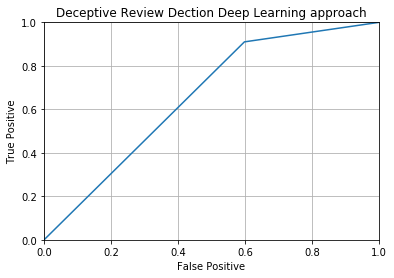

```python
# draw ROC curve
fpr, tpr, thresholds = _roc_curve(test_set['likes'], binary_prediction)

_plt.plot(fpr, tpr)
_plt.xlim([0.0, 1.0])
_plt.ylim([0.0, 1.0])

_plt.title("Deceptive Review Dection Deep Learning approach")
_plt.xlabel("False Positive")
_plt.ylabel("True Positive")

_plt.grid(True)
_plt.show()
```

### NN2

```python
train_set = _pd.read_pickle('../dataset/m2_n9/model_train_set_3.pickle')
```

```python
# Number of neurons for hiddens layer
number_samples, number_features = train_set.drop(columns = ['likes', 'stars_review', 'review_id', 'user_id', 'business_id']).shape

number_input_neurons = number_features
number_output_neurons = 1
number_train_semples = number_samples
alpha = 7

number_hidden_neurons = round(number_train_semples / (alpha * (number_input_neurons + number_output_neurons)))
print(number_hidden_neurons)
```

```
102
```

```python
classifier = _Sequential()

# First Hidden Layer
classifier.add(_Dense(number_hidden_neurons, activation = 'relu', kernel_initializer = 'random_normal', input_dim = number_features))

# Second Hidden Layer
classifier.add(_Dense(number_hidden_neurons, activation = 'relu', kernel_initializer = 'random_normal'))

# Third Hidden Layer
classifier.add(_Dense(number_hidden_neurons, activation = 'relu', kernel_initializer = 'random_normal'))

# Fourth Hidden Layer
classifier.add(_Dense(number_hidden_neurons, activation = 'relu', kernel_initializer = 'random_normal'))

# Fifth Hidden Layer
classifier.add(_Dense(number_hidden_neurons, activation = 'relu', kernel_initializer = 'random_normal'))

# Output Layer
classifier.add(_Dense(1, activation = 'sigmoid', kernel_initializer = 'random_normal'))

# Compiling the neural network
classifier.compile(optimizer = 'adam', loss = 'binary_crossentropy', metrics = ['accuracy'])
```

```python
# Fitting the data to the training dataset
classifier.fit(train_set.drop(
    columns = ['likes', 'stars_review', 'review_id', 'user_id', 'business_id']),
    train_set['likes'], validation_split = 0.3, batch_size = 100, epochs = 100)
```

```
Train on 390870 samples, validate on 167516 samples
```

```
<keras.callbacks.History at 0x20c82b579e8>
```

```python
# Save trained model
classifier.save("../models/trained_deep_neural_network_2.h5")
```

```python
# evaluation of the model training
evaluation = classifier.evaluate(train_set.drop(columns = ['likes', 'stars_review', 'review_id', 'user_id', 'business_id']), train_set['likes'])
print(evaluation)
```

```
[0.5097503033514922, 0.7573470681567259]
```

```python
del train_set
test_set = _pd.read_pickle('../dataset/m2_n9/model_test_set_3.pickle')
```

```python
prediction = classifier.predict(test_set.drop(columns = ['likes', 'stars_review', 'review_id', 'user_id', 'business_id']))
binary_prediction = _binarize(prediction, threshold = 0.5)
```

```python
print("Report for Deep Learning approach:")
print(_classification_report(test_set['likes'], binary_prediction))

print("Accuracy for Deep Learning approach:", _accuracy_score(test_set['likes'], binary_prediction) * 100)
```

```
Report for Deep Learning approach:
              precision    recall  f1-score   support

           0       0.69      0.43      0.53     50930
           1       0.76      0.90      0.83    103063

    accuracy                           0.75    153993
   macro avg       0.72      0.67      0.68    153993
weighted avg       0.74      0.75      0.73    153993

Accuracy for Deep Learning approach: 74.67871916255933
```

```python
matrix = _confusion_matrix(test_set['likes'], binary_prediction)
print(matrix)
```

```
[[22043 28887]
 [10106 92957]]
```

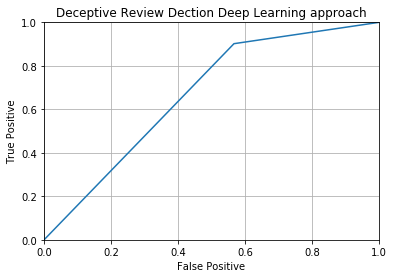

```python
# draw ROC curve
fpr, tpr, thresholds = _roc_curve(test_set['likes'], binary_prediction)

_plt.plot(fpr, tpr)
_plt.xlim([0.0, 1.0])
_plt.ylim([0.0, 1.0])

_plt.title("Deceptive Review Dection Deep Learning approach")
_plt.xlabel("False Positive")
_plt.ylabel("True Positive")

_plt.grid(True)
_plt.show()
```

## 7. Other experiments

### 7.1 SVM without dimensionality reduction

```python
train_set = _pd.read_pickle('../dataset/m2_n9/model_train_set_2.pickle')
train_set.shape
```

```
(558386, 2774)
```

```python
best_model = _jl.load("../models/best_SVM.joblib")
best_model.set_params(verbose=10)
best_model.get_params()
```

```
{'C': 0.001,
 'class_weight': None,
 'dual': True,
 'fit_intercept': True,
 'intercept_scaling': 1,
 'loss': 'squared_hinge',
 'max_iter': 50000,
 'multi_class': 'ovr',
 'penalty': 'l2',
 'random_state': 0,
 'tol': 0.0001,
 'verbose': 10}
```

```python
best_model.fit(train_set.drop(columns=['likes', 'stars_review', 'review_id', 'user_id', 'business_id']), train_set['likes'])
```

```
[LibLinear]
```

```
LinearSVC(C=0.001, class_weight=None, dual=True, fit_intercept=True,
          intercept_scaling=1, loss='squared_hinge', max_iter=50000,
          multi_class='ovr', penalty='l2', random_state=0, tol=0.0001,
          verbose=10)
```

```python
_jl.dump(best_model, "../models/best_SVM_all.joblib")
```

```
['../models/best_SVM_all.joblib']
```

```python
print("coef:", best_model.coef_)
print("intercept:", best_model.intercept_)
```

```
coef: [[-0.14394614 -0.20443318  0.34380749 ...  0.00380986  0.00857759
   0.        ]]
intercept: [-0.31154943]
```

```python
del train_set
test_set = _pd.read_pickle('../dataset/m2_n9/model_test_set_2.pickle')
test_set.shape
```

```
(153993, 2774)
```

```python
# test classifier
predic = best_model.predict(test_set.drop(columns=['likes', 'stars_review', 'review_id', 'user_id', 'business_id']))
print("predictions:\n", predic)
```

```
predictions:
 [1 0 1 ... 0 0 0]
```

```python
set(predic)
```

```
{0, 1}
```

```python
# evaluate classifier

print("Report for Support Vector Machine:")
print(_classification_report(test_set['likes'], predic))

print("Accuracy for Support Vector Machine:", _accuracy_score(test_set['likes'], predic)*100)
```

```
Report for Support Vector Machine:
              precision    recall  f1-score   support

           0       0.72      0.34      0.46     50930
           1       0.74      0.93      0.83    103063

    accuracy                           0.74    153993
   macro avg       0.73      0.64      0.64    153993
weighted avg       0.73      0.74      0.71    153993

Accuracy for Support Vector Machine: 73.73971544161098
```

```python
# Confusion matrix for SVC

print("Confusion Matrix for SVC: ")
_confusion_matrix(test_set['likes'], predic)
```

```
Confusion Matrix for SVC:
```

```
array([[17293, 33637],
       [ 6802, 96261]], dtype=int64)
```

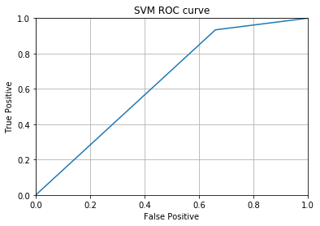

```python
# draw ROC curve
fpr, tpr, thresholds = _roc_curve(test_set['likes'], predic)

_plt.plot(fpr,tpr)
_plt.xlim([0.0,1.0])
_plt.ylim([0.0,1.0])

_plt.title("SVM ROC curve")
_plt.xlabel("False Positive")
_plt.ylabel("True Positive")

_plt.grid(True)
_plt.show()
```

### 7.2 Random forest without dimensionality reduction

```python
train_set = _pd.read_pickle('../dataset/m2_n9/model_train_set_2.pickle')
train_set.shape
```

```
(558386, 2774)
```

```python
params = _jl.load("../models/best_Random_Forest_2.joblib").get_params()
params['n_jobs'] = -1
params['verbose'] = 10
best_model = _RandomForestClassifier(**params)
best_model.get_params()
```

```
{'bootstrap': False,
 'class_weight': None,
 'criterion': 'entropy',
 'max_depth': 50,
 'max_features': 'auto',
 'max_leaf_nodes': None,
 'min_impurity_decrease': 0.0,
 'min_impurity_split': None,
 'min_samples_leaf': 2,
 'min_samples_split': 10,
 'min_weight_fraction_leaf': 0.0,
 'n_estimators': 1000,
 'n_jobs': -1,
 'oob_score': False,
 'random_state': None,
 'verbose': 10,
 'warm_start': False}
```

```python
best_model.fit(train_set.drop(columns=['likes', 'stars_review', 'review_id', 'user_id', 'business_id']), train_set['likes'])
```

```
[Parallel(n_jobs=-1)]: Using backend ThreadingBackend with 12 concurrent workers.
```

[output not shown]

```
[Parallel(n_jobs=-1)]: Done   1 tasks      | elapsed:   44.0s
```

[output not shown]

```
[Parallel(n_jobs=-1)]: Done   8 tasks      | elapsed:   53.2s
```

[output not shown]

```
[Parallel(n_jobs=-1)]: Done  17 tasks      | elapsed:  1.9min
```

[output not shown]

```
[Parallel(n_jobs=-1)]: Done  26 tasks      | elapsed:  2.7min
```

[output not shown]

```
[Parallel(n_jobs=-1)]: Done  37 tasks      | elapsed:  3.4min
```

[output not shown]

```
[Parallel(n_jobs=-1)]: Done  48 tasks      | elapsed:  4.0min
```

[output not shown]

```
[Parallel(n_jobs=-1)]: Done  61 tasks      | elapsed:  5.2min
```

[output not shown]

```
[Parallel(n_jobs=-1)]: Done  74 tasks      | elapsed:  6.1min
```

[output not shown]

```
[Parallel(n_jobs=-1)]: Done  89 tasks      | elapsed:  7.1min
```

[output not shown]

```
[Parallel(n_jobs=-1)]: Done 104 tasks      | elapsed:  8.1min
```

[output not shown]

```
[Parallel(n_jobs=-1)]: Done 121 tasks      | elapsed:  9.5min
```

[output not shown]

```
[Parallel(n_jobs=-1)]: Done 138 tasks      | elapsed: 10.7min
```

[output not shown]

```
[Parallel(n_jobs=-1)]: Done 157 tasks      | elapsed: 12.2min
```

[output not shown]

```
[Parallel(n_jobs=-1)]: Done 176 tasks      | elapsed: 13.3min
```

[output not shown]

```
[Parallel(n_jobs=-1)]: Done 197 tasks      | elapsed: 14.8min
```

[output not shown]

```
[Parallel(n_jobs=-1)]: Done 218 tasks      | elapsed: 16.4min
```

[output not shown]

```
[Parallel(n_jobs=-1)]: Done 241 tasks      | elapsed: 17.9min
```

[output not shown]

```
[Parallel(n_jobs=-1)]: Done 264 tasks      | elapsed: 19.6min
```

[output not shown]

```
[Parallel(n_jobs=-1)]: Done 289 tasks      | elapsed: 21.5min
```

[output not shown]

```
[Parallel(n_jobs=-1)]: Done 314 tasks      | elapsed: 23.2min
```

[output not shown]